# Instrumente Statistice pentru Finanțe

## 4.3 Interpretarea efectului variabilelor explicative

În această secțiune ne propunem să explicăm și să interpretăm modul în care modelul ales și variabilele explicative influențează răspunsul mediu. Pentru aceasta vom considera situația în care covariabilele sunt continue, sunt discrete (categoriale) precum și modul în care acestea interacționează între ele.

### 4.3.1 Cazul variabilelor explicative continue

De cele mai multe ori atunci când avem de-a face doar cu variabile predictor continue este necesară ajustarea modelului de regresie astfel încât să se permită și relații/efecte neliniare între răspuns și covariabile. Am văzut în secțiunea Liniaritatea efectelor variabilelor explicative că acest lucru este permis în contextul modelului de regresie liniară, iar în această secțiune vom prezenta două abordări pentru obținerea acestui lucru: *transformarea covariabilelor* și *regresia polinomială*.

Transformarea variabilelor explicative permite înlăturarea efectelor neliniare în predictori și liniarizarea modelului. Dacă variabila explicativă $z$ prezintă (aproximativ) un efect neliniar de tipul $\beta_1\times f(z)$ unde $f$ este o funcție cunoscută atunci modelul de regresie

$$y_i = \beta_0 + \beta_1\times f(z_i) + \cdots+\varepsilon_i$$

poate fi transformat într-un model de regresie liniară

$$y_i = \beta_0 + \beta_1x_i + \cdots+\varepsilon_i$$

unde $x_i = f(z_i) - \frac{1}{n}\sum_{j = 1}^{n}f(z_j)$. Operația de centrare face ca efectul estimat $\hat{\beta}_1 x$ să fie automat centrat în zero și permite o mai bună interpretare.

Printre cele mai eficiente transformări se numără transformările de tip puteri (power transformations) care au ca formă generală

$$x_i = f_{\lambda}(z_i) = \left\{\begin{array}{ll}z_i^{\lambda} &, \lambda\neq 0\\ \log(z_i) &, \lambda = 0\end{array}\right.$$

unde $\lambda\in\Lambda = \left\{-1, -\frac{1}{2}, -\frac{1}{3}, 0, \frac{1}{3}, \frac{1}{2}, 1\right\}$ (scara puterilor). O inspecție vizuală prin trasarea matricei de diagrame de împrăștiere (scatterplot matrix) între predictori poate sugera ce transformări sunt necesare (Olive 2017).

> *Exemplu: prețul chiriilor din Munchen - transformarea variabilelor*

Vom exemplifica efectul asupra răspunsului mediu obținut prin transformarea variabilelor explicative folosind, pentru început, întregul set de date ce face referire la prețul chiriilor în Munchen. Dacă ne uităm la modelul de regresie liniară simplă între prețul net pe metrul pătrat al chiriei (ca variabilă răspuns) în funcție de suprafața locuinței de închiriat (variabila explicativă) găsim următoarea relație

$$\widehat{pret{\_m^2}_i} = 9.469 -0.035 \times suprafata_i.$$

În figura de mai jos avem ilustrat grafic modelul de regresie astfel: în subfigura din stânga avem diagrama de împrăștiere cu dreapta de regresie, în subfigura din mijloc avem graficul valorilor reziduale iar în subfigura din dreapta avem valorile reziduale medii calculate pentru fiecare valoare a suprafeței de locuit. Observăm că pentru apartamentele cu suprafața mică (suprafața mai mică de 30 metrii pătrați) valorile reziduale sunt predominant pozitive (mai exact peste $88\%$ dintre acestea au reziduuri pozitive) ceea ce sugerează existența unei relații neliniare între preț pe metru pătrat și suprafață.

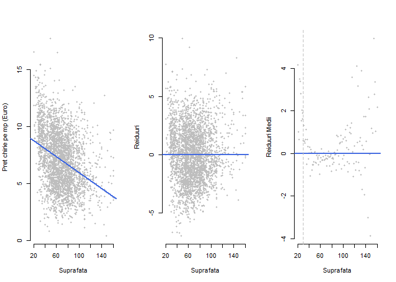

Specificarea acestei relații neliniare poate fi făcută, de exemplu, prin transformarea variabilei predictor conducând astfel la un model de regresie de tipul

$$pret{\_m^2}_i = \beta_0 + \beta_1\times f({suprafata_i}) + \varepsilon_i$$

unde $f$ este o funcție arbitrară care trebuie aleasă în avans (deterministă) și care nu este estimată de model.

Observăm că modelul de mai sus, chiar dacă reprezintă o generalizare a modelului de regresie liniară simplă considerat anterior, este tot un caz special de regresie liniară în care variabila predictor acum este $x_i = f({suprafata_i})$. Astfel, presupunând că prețul mediu net pe metrul pătrat variază invers proporțional cu suprafața de locuit atunci o transformare potrivită ar fi $f({suprafata_i})=\frac{1}{suprafata_i}$ și în această situație modelul ar deveni

$$pret{\_m^2}_i = \beta_0 + \beta_1 \frac{1}{suprafata_i} + \varepsilon_i.$$

Trebuie menționat că această transformare nu este singura care poate fi luată în calcul, de exemplu am putea considera o transformare logaritmică $f({suprafata_i})=\log({suprafata_i})$, și în general alegem transformarea potrivită în funcție sau de procesul teoretic care a condus la generarea datelor (atunci când acesta este cunoscut sau se poate determina - experiment fizic) sau prin inspecție vizuală a diagramei de împrăștiere.

În urma estimării prin metoda celor mai mici pătrate (a se vedea secțiunea Metoda celor mai mici pătrate) obținem că prețul mediu net pe metrul pătrat este:

$$\widehat{pret{\_m^2}_i} = 4.732 + 140.178 \frac{1}{suprafata_i}$$

iar matricea de design $\boldsymbol X$ pentru acest model

$$\boldsymbol X = \begin{pmatrix}1 & \frac{1}{suprafata_1}\\1 & \frac{1}{suprafata_2}\\ \vdots & \vdots\\ 1 & \frac{1}{suprafata_{3082}}\end{pmatrix} = \begin{pmatrix}1 & 0.029\\ 1 & 0.01\\ \vdots & \vdots \\ 1 & 0.016\end{pmatrix}.$$

Relația neliniară dintre răspunsul mediu și covariabila suprafața locuinței este ilustrată în figura de mai jos. Se constată că, per total, prețul mediu net al chiriei pe metrul pătrat descrește odată cu creșterea suprafeței de locuit dar această descreștere este mai abruptă pentru apartamentele cu suprafață mică (până în jurul valorii de 40 de $m^2$) după care aceasta devine aproape liniară cu o tendință de nivelare în jurul valorii de 100 de $m^2$. Graficele valorilor reziduale (sau reziduale medii) sugerează o (mai) bună ajustare a modelului neliniar ales la date. $\square$

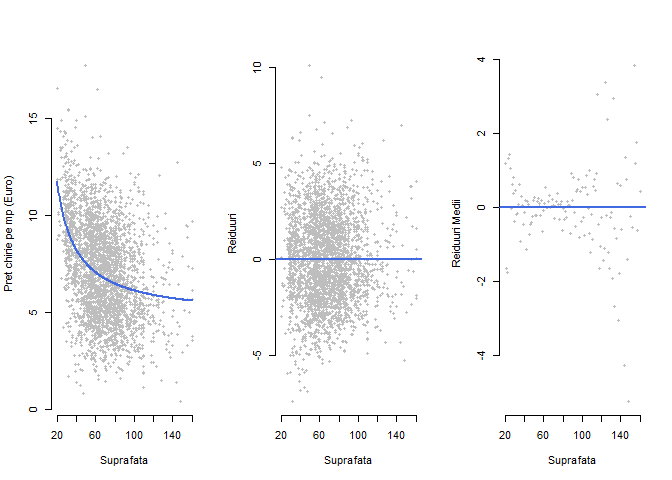

> *Exemplu: înălțimea arborilor de eucalipt - transformarea variabilelor*

În contextul setului de date `Eucalypt` am văzut că înălțimea (medie) a arborilor de eucalipt poate fi modelată prin intermediul modelului de regresie liniară simplă prin $\widehat{ht}_i = 9.037 + 0.257 circ_i$ (a se vedea Exemplul ) unde, observând că majoritatea arborilor a căror circumferință avea valori mai mici de 35 cm se aflau sub dreapta de regresie, am dedus că o relație neliniară între înălțime și circumferință ar fi mai potrivită. Inspectând vizual diagrama de împrăștiere (figura de mai jos partea stângă) putem sugera o transformare de tipul $f(circ_i)=\sqrt{circ_i}$ ceea ce ar conduce, de exemplu, la modelul de regresie

$$ht_i = \beta_0 + \beta_1\times circ_i + \beta_2\times\sqrt{circ_i} + \varepsilon_i, \quad i =1,\ldots, 1429.$$
Estimând coeficienții din modelul de mai sus găsim că înălțimea medie a arborilor de eucalipt este

$$\widehat{ht_i} = -24.352 -0.483 \times circ_i + 9.987 \times \sqrt{circ_i}$$

iar în acest caz matricea de design $\boldsymbol X$ este

$$\boldsymbol X = \begin{pmatrix}1 & circ_1 & \sqrt{circ_1}\\1 & circ_2 & \sqrt{circ_2}\\ \vdots & \vdots & \vdots\\ 1 & circ_{1429} & \sqrt{circ_{1429}}\end{pmatrix} = \begin{pmatrix}1 & 36 & 6\\ 1 & 42 & 6.481\\ \vdots & \vdots & \vdots\\ 1 & 40 & 6.325\end{pmatrix}.$$

În figura de mai jos avem diagrama de împrăștiere a datelor și curba de regresie care modelează înălțimea medie în funcție de circumferință conform modelului propus, graficul valorilor reziduale precum și graficul valorilor reziduale medii calculate pentru fiecare valoare a circumferinței. Putem observa că modelul propus este ajustat (fitat) mai bine pe date (coeficientul de determinare $R^2=0.7921904$ este un pic mai mare atât față de cel în care apare doar termenul $\sqrt{circ_i}$ care este $R^2=0.7820638$ cât și de modelul de regresie simplă $R^2=0.7683202$ - acest fenomen fiind absolut normal în contextul modelelor imbricate), în special pentru arbori a căror circumferință este mai mică de 65 cm. Pentru arborii cu circumferințe mai mari modelul sugerează o înălțime medie mai mică decât cea măsurată. $\square$

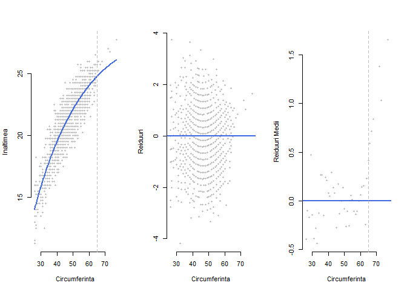

În exemplul următor vom face referire la *regresia polinomială* care reprezintă o altă modalitate simplă de a specifica un efect neliniar al predictorilor asupra variabilei răspuns. În general, atunci când covariabila continuă $z$ prezintă un efect neliniar (polinomial) de tipul $\beta_1 z + \beta_2 z^2 +\cdots + \beta_k z^k$, modelul

$$y_i = \beta_0 + \beta_1 z_i + \beta_2 z_i^2 +\cdots + \beta_k z_i^k + \varepsilon_i$$

poate fi transformat în modelul de regresie liniară simplă

$$y_i = \beta_0 + \beta_1 x_{i1} + \beta_2 x_{i2} +\cdots + \beta_k x_{ik} + \varepsilon_i$$

unde $x_{i1} = z_i$, $x_{i2} = z_i^2$, …, $x_{ik} = z_i^k$. Este important de remarcat faptul că pentru a facilita interpretarea este necesară uneori centrarea (și uneori ortogonalizarea) vectorilor $\boldsymbol X_j = (x_{1j},\ldots,x_{nj})^\intercal$ în $\boldsymbol X_j - \bar{\boldsymbol X_j}$ unde $\bar{\boldsymbol X_j} = \left(\bar{x}_j = \frac{\sum_{i = 1}^{n}x_{ij}}{n}, \ldots, \bar{x}_j\right)^\intercal$.

> *Exemplu: prețul chiriilor din Munchen - regresie polinomială*

Vom ilustra modelarea prin regresie polinomială folosind setul de date `Munchen`. Vom presupune că variabila predictor suprafața de locuit admite un efect polinomial. Pentru un efect polinomial de ordin doi obținem următorul model de regresie:

$$pret{\_m^2}_i = \beta_0 + \beta_1\times suprafata_i + \beta_2\times suprafata_i^2 + \varepsilon_i$$

iar pentru un efect de ordin trei avem

$$pret{\_m^2}_i = \beta_0 + \beta_1\times suprafata_i + \beta_2\times suprafata_i^2 + \beta_3\times suprafata_i^3 + \varepsilon_i.$$

Binențeles, putem folosi și polinoame de grad superior dar în general preferăm pentru simplitate și interpretabilitate polinoame de grad mai mic. De asemenea, atunci când folosim polinoame de grad mai mare ca 3 observăm că rezultatul devine instabil în special la capetele domeniului covariabilei (a se vedea figura de mai jos dreapta unde folosim un polinom de grad 4). Notând cu $x_{i1} = suprafata_i$, $x_{i2} = suprafata_i^2$ și $x_{i3} = suprafata_i^3$ obținem modelul de regresie liniară

$$pret{\_m^2}_i = \left\{\begin{array}{ll}\beta_0 + \beta_1x_{i1} + \beta_2x_{i2} + \varepsilon_i, & \text{polinom de grad 2}\\ \beta_0 + \beta_1x_{i1} + \beta_2x_{i2} + \beta_3x_{i3} + \varepsilon_i, & \text{polinom de grad 3}\end{array}\right.$$

Matricele de design corespunzătoare sunt

$$\boldsymbol X = \begin{pmatrix}
1 & 35 & 35 ^2\\
1 & 104 & 104 ^2\\
\vdots & \vdots & \vdots\\
1 & 62 & 62 ^2
\end{pmatrix} = \begin{pmatrix}
1 & 35 & 1225\\
1 & 104 & 1.0816\times 10^{4}\\
\vdots & \vdots & \vdots\\
1 & 62 & 3844\\
\end{pmatrix}$$

respectiv

$$\boldsymbol X = \begin{pmatrix}
1 & 35 & 35 ^2 & 35 ^3\\
1 & 104 & 104 ^2 & 104 ^3\\
\vdots & \vdots & \vdots & \vdots\\
1 & 62 & 62 ^2 & 62 ^3
\end{pmatrix} = \begin{pmatrix}
1 & 35 & 1225 & 4.2875\times 10^{4}\\
1 & 104 & 1.0816\times 10^{4} & 1.124864\times 10^{6}\\
\vdots & \vdots & \vdots & \vdots \\
1 & 62 & 3844 & 2.38328\times 10^{5}\\
\end{pmatrix}$$

iar curbele de regresie estimate

$$\widehat{pret{\_m^2}_i} = \left\{\begin{array}{ll}11.83 -0.106\times suprafata_i + 4.7\times 10^{-4}\times suprafata_i^2, & \text{grad 2}\\ 14.28 -0.218\times suprafata_i + 0.002\times suprafata_i^2 -6\times 10^{-6}\times suprafata_i^3, & \text{grad 3}\end{array}\right.$$

Figura de mai jos ne prezintă diagramele de împrăștiere împreună curbele de regresie specifice modelelor selectate. Observăm că rezultatele sunt similare cu cele obținute prin transformarea $f(suprafata_i) = \frac{1}{suprafata_i}$ (modelele polinomiale considerate fiind imbricate conduc la o creștere a coeficientului de determinare ca și în cazul Exemplului ). $\square$

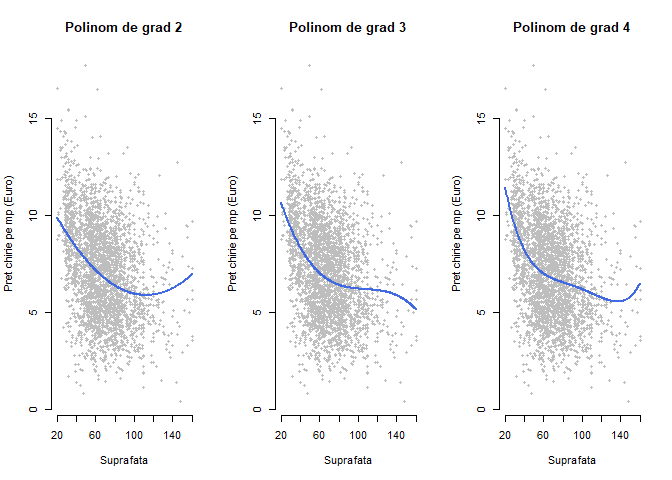

Dacă până acum am considerat doar modele în care apărea o singură variabilă explicativă, exemplul de mai jos consideră o generalizare la doi sau mai mulți predictori.

> *Exemplu: prețul chiriilor din Munchen - model aditiv*

În acest exemplu vom modela prețul mediu net al chiriei pe metrul pătrat adăugând pe lângă efectul invers proporțional dat de suprafața de locuit (a se vedea Exemplul ) și efectul dat de anul de construcție al apartamentului ($an{\_con}$). Dacă anul construcției prezintă un efect liniar atunci asupra prețului chiriei, obținem modelul (denumit modelul 1)

$$pret{\_m^2}_i = \beta_0 + \beta_1\times f(suprafata_i) + \beta_2\times an{\_con}_{i} + \varepsilon_i$$

unde $f(suprafata_i) = \frac{1}{suprafata_i}$ și care în urma estimării devine

$$\widehat{pret{\_m^2}_i} = -65.406 + 119.361\frac{1}{suprafata_i} + 0.036\times an{\_con}_{i}.$$

Alternativ, putem să considerăm că anul construcției locuinței prezintă un efect neliniar asupra prețului chiriei pe metrul pătrat, aspect pe care îl vom modela prin intermediul unui polinom de grad 3 și în acest caz avem modelul (denumit model 2)

$$pret{\_m^2}_i = \beta_0 + \beta_1\times \frac{1}{suprafata_i} + \beta_2\times an{\_con}_{i} + \beta_3\times an{\_con}_{i}^2 + \beta_4\times an{\_con}_{i}^3 + \varepsilon_i.$$

Modelul estimat (răspunsul mediu estimat) în acest caz este

$$\widehat{pret{\_m^2}_i} = 2.94193\times 10^{4} + 129.57 \times \frac{1}{suprafata_i} -43.3\times an{\_con}_{i} + 0.021\times an{\_con}_{i}^2 -3\times 10^{-6}\times an{\_con}_{i}^3$$

În figura de mai jos avem ilustrate diagramele de împrăștiere (3D) împreună cu suprafețele de regresie induse de modelele menționate mai sus. Ca și în cazul regresiei liniare simple, vizualizarea diagramelor de împrăștiere atunci când avem de-a face cu două variabile explicative este un instrument grafic care permite o mai bună înțelegere a relației dintre variabila răspuns și covariabilele implicate. Pentru trasarea în `R` a diagramelor de împrăștiere am folosit funcția `scatter3D` din pachetul `plot3D`.

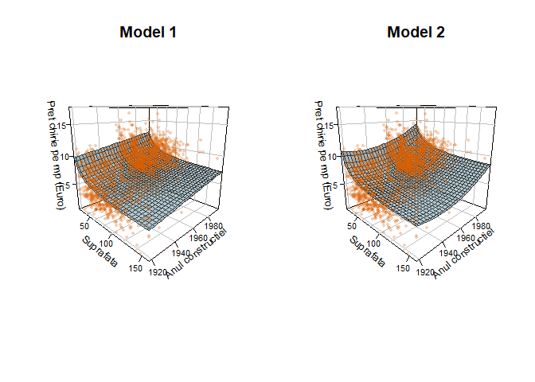

Combinând în modelul 2 efectele variabilelor explicative *suprafața de locuit* și *anul de construcție a locuinței* în funcțiile $f_1$ și respectiv $f_2$, obținem următorul model

$$pret{\_m^2}_i = \beta_0 + \underbrace{f_1(suprafata_i)}_{=\beta_1\times \frac{1}{suprafata_i}} + \underbrace{f_2(an{\_con_i})}_{=\beta_2\times an{\_con}_{i} + \beta_3\times an{\_con}_{i}^2 + \beta_4\times an{\_con}_{i}^3} + \varepsilon_i.$$

Funcțiile estimate sunt

$$\hat{f}_1(suprafata) = 129.57 \times \frac{1}{suprafata}$$

și respectiv

$$\hat{f}_2(an{\_con}) = -43.3\times an{\_con}_{i} + 0.021\times an{\_con}_{i}^2 -3\times 10^{-6}\times an{\_con}_{i}^3.$$
Efectul estimat $\hat{f}_1(suprafata)$ și $\hat{f}_2(an{\_con})$ al celor două covariabile poate fi interpretat mai ușor prin intermediul vizualizării. De exemplu, în figura de mai jos este prezentat efectul anului construcției asupra prețului chiriei pe metrul pătrat. Observăm că, datorită scalei covariabilei *anul de construcției a locuinței* care ia valori între 1918 și 1998, efectul acestei covariabile este între -2.941510^{4} și -2.941110^{4}. Dacă în schimb am specifica anul de construcție ca având valori de la $18$ la $98$ (scăzând $1900$) atunci am obține modelul

$$\widehat{pret{\_m^2}_i} = 5.4 + 129.57 \times \frac{1}{suprafata_i} -0.09\times an{\_con}_{i} + 0.002\times an{\_con}_{i}^2 -3\times 10^{-6}\times an{\_con}_{i}^3$$

Chiar dacă parametrii noului model diferă de cei ai modelului 2, atunci când ne uităm la efectul anului de construcție (figura de mai jos dreapta) vedem că aceasta este doar translatată vertical. Acest fenomen este natural ținând cont de observația că adăugând un termen constant la $\hat{f}_2$ și scăzând același termen din $\hat{\beta}_0$ valoarea estimată a răspunsului mediu rămâne neschimbată (nivelul unei funcții neliniare nu este identifiabil).

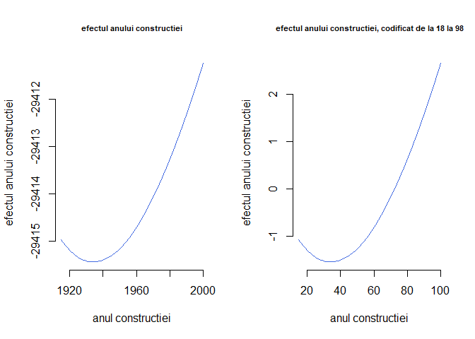

Observația anterioară, că nivelul unei funcții neliniare poate fi schimbat în mod arbitrar de exemplu prin transformarea variabilei predictor, conduce la recomandarea *centrării* covariabilelor (sau a funcțiilor de covariabile). Astfel, în cazul modelului propus putem înlocui variabila $suprafata{\_inv} = \frac{1}{suprafata}$ cu $suprafata{\_inv} - \overline{suprafata{\_inv}}$ și respectiv variabilele $an{\_con\_j} = an{\_con}^j$ cu $an{\_con\_j} - \overline{an{\_con\_j}}$.

În cazul modelării prin intermediul polinoamelor putem să folosim [polinoame ortogonale](https://mathworld.wolfram.com/OrthogonalPolynomials.html)[^3], unde baza uzuală $1$, $x$, $x^2$, $x^3$, $\ldots$ va fi înlocuită de o bază de polinoame ortogonale ceea ce implică centralitatea și ortogonalitatea coloanelor matricei de design corespunzătoare. De asemenea este important de remarcat faptul că folosind o bază de polinoame ortogonale calculul estimatorilor prin metoda celor mai mici pătrate este mai stabil. În `R` putem construi polinoame ortogonale folosind funcția `poly()`.

Folosind variabilele ortogonale $an{\_co\_j}$, $j=1,2,3$ și variabila centrată $suprafata{\_inv\_cen} = suprafata{\_inv} - \overline{suprafata{\_inv}}$ obținem modelul de regresile liniară

$$\widehat{pret{\_m^2}_i} = 7.111 + 129.572 \times suprafata{\_inv\_cen} + 43.938\times an{\_co\_1} + 27.539\times an{\_co\_2} -1.756\times an{\_co\_3}$$

În figura următoare sunt ilustrate efectele covariabilelor *suprafața de locuit* și *anul de construcție a locuinței*, $\hat{f}_1(suprafata_i)$ și respectiv $\hat{f}_2(an{\_con}_i)$, împreună cu reziduurile parțiale, definite prin

$$\hat{\varepsilon}_{suprafata, i} = pret{\_m^2}_i - \hat{\beta}_0 - \hat{f}_2(an{\_con}_i) = \hat{\varepsilon}_i + \hat{f}_1(suprafata_i)$$

și respectiv

$$\hat{\varepsilon}_{an{\_con}, i} = pret{\_m^2}_i - \hat{\beta}_0 - \hat{f}_1(suprafata_i) = \hat{\varepsilon}_i + \hat{f}_2(an{\_con}_i).$$

Reziduurile parțiale pentru covariabila *suprafața de locuit*, $\hat{\varepsilon}_{suprafata, i}$, iau în calcul și variabilitate indusă de suprafața de locuit atunci când toate celelalte efecte sunt înlăturate (în acest caz anul de construcție). În mod similar, pentru reziduurile parțiale asociate anului de construcție a locuinței - $\hat{\varepsilon}_{an{\_con}, i}$, efectul suprafeței este eliminat dar nu și cel al anului de construcție. Trasând reziduurile parțiale putem investiga dintr-o perspectivă vizuală dacă modelul neliniar ales este potrivit sau nu.

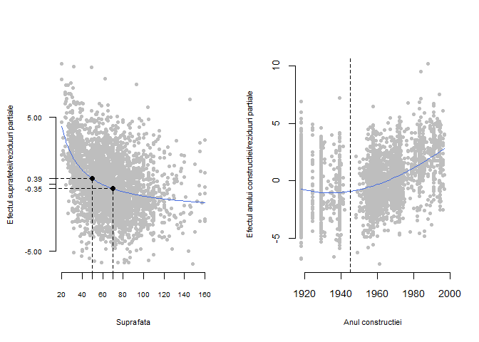

Din punct de vedere al interpretabilității, efectul suprafeței de locuit (figura din stânga) specifică influența acestei covariabile asupra prețului mediu net al chiriei pe metrul pătrat atunci când celelalte covariabile sunt păstrate constante. Astfel pentru apartamentele cu o suprafață de 50 și respectiv 70 metrii pătrați obținem un efect estimat de $\hat{f}_1(50)\approx 0.39$ și respectiv $\hat{f}_1(70)\approx -0.35$ euro pe metrul pătrat. Acest fapt implică faptul că în medie prețul chiriei pe metrul pătrat pentru apartamentele de 70 metrii pătrați sunt mai ieftine cu 0.74 euro pe metrul pătrat față de cele cu o suprafață de 50 metrii pătrați, presupunând că ambele au fost construite în același an. De asemenea, dacă ne uităm la apartamentele cu suprafața de 60 și respectiv 80 metrii pătrați atunci diferența este de doar 0.54 euro fapt indicat de efectul aproape constant al covariabilei atunci când locuițele au suprafața mare.

În același mod poate fi interpretat și graficul care prezintă efectul anului de construcție a locuinței. Putem observa (figura de mai sus dreapta) că pentru apartamentele, cu aceeași suprafață, construite inaintea Celui de-al Doilea Război Mondial efectul anului construcției asupra prețului mediu pe metrul pătrat al chiriei este constant pe când pentru apartamentele construite după 1945 tendința este de creștere în mod liniar.

### 4.3.2 Cazul variabilelor explicative discrete

În secțiunea precedentă am prezentat succint care este efectul indus de o variabilă explicativă continuă asupra variabilei răspuns. În această secțiune vom ilustra cazul variabilelor explicative discrete (categoriale).

> *Exemplu: prețul chiriilor din Munchen - covariabile categoriale*

Pentru prezentarea metodologiei ne plasăm în contextul setului de date `Munchen` referitor la prețul chiriilor din orașul Munchen și investigăm modul în care locația imobilului (variabila `locatie` - `location`) influențează prețul chiriei locuinței. Variabila `locatie` admite trei categorii: 1 = locație medie, 2 = locație bună și 3 = locație de top.

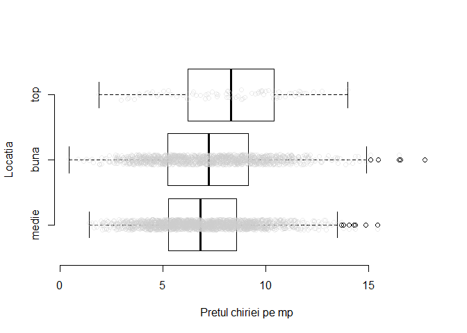

Dacă am modela prețul chiriei pe metrul pătrat în funcție de locație folosind un model de regresie liniară simplă și tratând covariabila `locatie` ca pe o variabilă continuă am avea

$$pret{\_m^2}_i = \beta_0 + \beta_1\times locatie_i + \varepsilon_i$$

care în urma estimării ar conduce la

$$\widehat{pret{\_m^2}_i} = 6.544 + 0.393\times locatie_i.$$

Observăm că, datorită modului în care am ales codificarea variabile `locatie`, prețul mediu al chiriilor pe metrul pătrat pentru locuințele care se situează într-o locație bună este de două ori mai mare decât al celor care se află într-o locație medie (0.393 Euro față de 0.786 Euro) iar cel al locuințelor dintr-o locație de top este de trei ori mai mare. Binențeles că dacă am fi codificat variabila `locatie` prin 2 = locație medie, 6 = locație bună și 8 = locație de top atunci efectele ar fi fost diferite (apartamentele din locații de top ar fi fost de patru ori mai scumpe, în medie, față de cele din locație medie).

Prin urmare, constatăm că modul în care codificăm covariabila categorială influențează direct rezultatele și modul de interpretare. Problema care apare este că în cazul variabilelor categoriale distanțele dintre categorii nu au întotdeauna aceași însemnătate, precum nici apartamentele dintr-o locție bună nu sunt de două ori (sau de trei ori) mai *bune* față de cele situate într-o locație medie. O modalitate de a corecta această problemă constă în introducerea unor noi covariabile, denumite variabile ajutătoare - *dummy*, care să permită estimarea efectului indus de fiecare categorie a variabilei explicative în cauză. Mai precis, pentru variabila `locatie` introducem trei noi variabile ajutătoare `alotatie`, `glocatie` și `tlocatie` de tip variabilă indicator după cum locuința se află într-o locație medie (average), bună (good) respectiv de top astfel

$$\begin{aligned}
alocatie &= \left\{\begin{array}{ll}1, & \text{locatie = 1 (locație medie)}\\ 0, & \text{altfel}\end{array}\right.\\
glocatie &= \left\{\begin{array}{ll}1, & \text{locatie = 2 (locație bună)}\\ 0, & \text{altfel}\end{array}\right.\\
tlocatie &= \left\{\begin{array}{ll}1, & \text{locatie = 3 (locație de top)}\\ 0, & \text{altfel}\end{array}\right.
\end{aligned}$$

Folosind cele trei variabile ajutătoare pentru modelarea prețului chiriei pe metrul pătrat avem modelul de regresie

$$pret{\_m^2}_i = \beta_0 + \beta_1\times alocatie_i + \beta_2\times glocatie_i + \beta_3\times tlocatie_i + \varepsilon_i$$

care prezintă acum o nouă problemă, și anume că parametrii acestuia nu sunt identifiabili, deci nu pot fi determinați în mod unic. Acest lucru se poate vedea imediat dacă ne uităm la efectele celor trei covariabile: apartamentele dintr-o locație medie impun un efect asupra prețului mediu al chiriei de $\beta_0 + \beta_1$ ($alocatie_i = 1$, $glocatie_i = 0$ și $tlocatie_i = 0$), iar cele care se situează în locații bune și de top prezintă un efect de $\beta_0 + \beta_2$ și respectiv $\beta_0 + \beta_3$. Termenul $\beta_0$ (ordonata la origine) apare în toate cele trei efecte astfel, adăugând o cantitate constantă la $\beta_0$ și scăzând-o apoi din coeficienții $\beta_1$, $\beta_2$ și $\beta_3$ conduce la același efect asupra variabilei dependente. Același lucru se putea observa și dacă ne uitam la matricea de design $\boldsymbol X$ care acum nu mai avea rang plin, vectorii coloană nu mai sunt liniar independenți, în fapt primul vector coloană este egal cu suma vectorilor coloană 2, 3 și 4.

Problema identifiabilității se poate rezolva în mai multe moduri dar aici vom considera cazul cel mai uzual și anume eliminarea din model a unei variabile ajutătoare din cele trei nou create. Prin urmare, dacă eliminăm variabila `alocatie` obținem modelul

$$pret{\_m^2}_i = \beta_0 + \beta_1\times glocatie_i + \beta_2\times tlocatie_i + \varepsilon_i$$

care în urma estimării devine

$$\widehat{pret{\_m^2}_i} = 6.957 + 0.316\times glocatie_i + 1.216\times tlocatie_i.$$

Trebuie să avem grijă ca atunci când interpretăm coeficienții modelului de mai sus și efectele induse să ținem seama de categoria (variabila ajutătoare) eliminată - în cazul nostru locație medie. Această categorie se numește *categorie de referință*. Astfel, pentru apartamentele situate într-o locație medie obținem un efect estimat $\hat{\beta_0} = 6.957$, pentru cele din locație bună $\hat{\beta_0} + \hat{\beta_1} = 7.273$ iar pentru cele din locație de top efectul este $\hat{\beta_0} + \hat{\beta_3} = 8.173$. Constatăm că în comparație cu apartamentele aflate într-o locație medie, prețul mediu al chiriei pe metrul pătrat al apartamentelor situate într-o locație bună este cu $0.316$ Euro mai mult iar cel al apartamentelor aflate într-o locație de top cu $1.216$ Euro mai mult.$\square$

În general, atunci când vrem să modelăm efectul unei variabile predictor categoriale $z$ cu $c$ categorii, $z\in\{1,2,\ldots,c\}$, fixăm o categorie de referință (de obicei categoria cea mai frecventă sau categoria de control), în acest caz categoria $c$, și definim $c-1$ variabile de tip *dummy*

$$x_{i1} = \left\{\begin{array}{ll}1, & z_i = 1,\\0, & \text{altfel}\end{array}\right. \quad\cdots\quad x_{i,c-1} = \left\{\begin{array}{ll}1, & z_i = c-1,\\0, & \text{altfel}\end{array}\right.$$

pe care să le includem ca variabile explicative în model

$$y_i = \beta_0 + \beta_1 x_{i1} + \cdots + \beta_{i,c-1} x_{i, c-1} + \varepsilon_i.$$

Efectele estimate trebuie interpretate în raport cu categoria de referință. Este important de menționat că există mai multe scheme de codificare a variabilelor explicative categoriale (`simple coding`, `deviation` sau `effect coding`, `Helmert coding`, `Orthogonal polynomial coding`, etc.), cea de mai sus este cea mai des întâlnită.

Înainte de a încheia această secțiune vom ilustra o serie (patru) de metode prin care putem crea în `R` variabilele ajutătoate de tip *dummy*. Vom începe prin crearea efectivă a variabilelor folosind librăria `tidyverse` (sau funcțiile de bază):

```r
# 1) creare variabilelor alocation, glocation si tlocation
munich = munich %>%
  mutate(alocation = ifelse(location == 1, 1, 0),
         glocation = ifelse(location == 2, 1, 0),
         tlocation = ifelse(location == 3, 1, 0))

# exemplu
lm(rentsqm ~ alocation + tlocation, data = munich)
lm(rentsqm ~ glocation + tlocation, data = munich)
```

O a doua metodă este de a folosi funcția `I()` (permite interpretarea aritmetică a expresiei din paranteză) în care specificăm categoria variabilei explicative care vrem să fie inclusă în model. Această metodă ne permite fixarea unei categorii de referință, prin eliminarea ei din model.

```r
# 2) Folosirea functei I()
lm(rentsqm ~ I(location == 1) + I(location == 3), data = munich)
lm(rentsqm ~ I(location == 2) + I(location == 3), data = munich)
```

În al treilea rând putem folosi funcția `factor()` care asigură programul `R` că avem de-a face cu o variabilă categorială, fiecare categorie numindu-se nivel (level).

```r
# 3) Folosirea functiei factor
munich$locationf = factor(munich$location)

lm(rentsqm ~ locationf, data = munich)

# sau echivalent
lm(rentsqm ~ factor(location), data = munich)
```

Ultima funcție este funcția `contr.treatment()`, care în fapt se folosește în pereche cu funcția `contrasts()`. Funcția `contr.treatment()` ne permite specificarea categoriei de referință prin includerea opțiunii `base =`.

```r
# 4) Folosirea functiei contr.treatment
munich$locationf = factor(munich$location)

contrasts(munich$locationf) = contr.treatment(3, base = 2)
# 3 - este numarul de niveluri iar base reprezinta nivelul de referinta
lm(rentsqm ~ locationf, data = munich)

contrasts(munich$locationf) = contr.treatment(3, base = 1)
lm(rentsqm ~ locationf, data = munich)
```

### 4.3.3 Interacția dintre două covariabile

Atunci când pentru fiecare variabilă explicativă efectul ei asupra răspunsului mediu nu depinde de nivelul celorlalte covariabile din model spunem că variabilele predictor au efect *aditiv* sau nu interacționează unele cu celelalte. În cazul în care efectul unei covariabile depinde de nivelul cel puțin a uneia dintre celelalte covariabile, spunem că există un efect de interacție între ele. Un exemplu simplu de model de regresie liniară neaditiv este
$$y = \beta_0 + \beta_1 x_1 + \beta_2 x_2 + \beta_3 x_1x_2 + \varepsilon$$

unde termenul $\beta_3 x_1x_2$ se numește *termen de interacție* sau *interacția* dintre $x_1$ și $x_2$ (*interaction effect*). Cum termenii $\beta_1 x_1$ și $\beta_2 x_2$ depind doar de covariabilele $x_1$ și respectiv $x_2$, se numesc *efecte principale* (*main effects*). Evident că modelul de mai sus este un caz particular de model de regresie liniară deoarece putem nota termenul $x_1x_2$ cu $x_3$. În general, produsul a două sau mai multe efecte principale diferite reprezintă o interacție.

Pentru a înțelege care este impactul termenului de interacție asupra răspunsului mediu să considerăm că variabila predictor $x_1$ se modifică prin cantitatea $\delta = 1$:

$$\mathbb{E}[y|x_1 + \delta, x_2] - \mathbb{E}[y|x_1, x_2] = \beta_1\delta + \beta_3\delta x_2 = \beta_1 + \beta_3 x_2$$

ceea ce arată că, în cazul în care $\beta_3\neq 0$, răspunsul mediu se modifică prin $\beta_1 + \beta_3 x_2$ unități odată cu creșterea cu o unitate a lui $x_1$ și păstrarea la nivel constant a lui $x_2$. Prin urmare dacă efectul indus asupra răspunsului mediu de schimbarea unei variabile explicative depinde de valoarea unei alte variabile explicative atunci avem de-a face cu un efect de interacție. De cele mai multe ori, atunci când semnele coeficienților $\beta_1$ și $\beta_2$ sunt la fel (negative sau pozitive) și semnul lui $\beta_3$ coincide cu acestea spunem că avem un efect de întărire (reinforcement effect) iar când semnul lui $\beta_3$ este contrar atunci avem efect de intersecție (intersection effect).

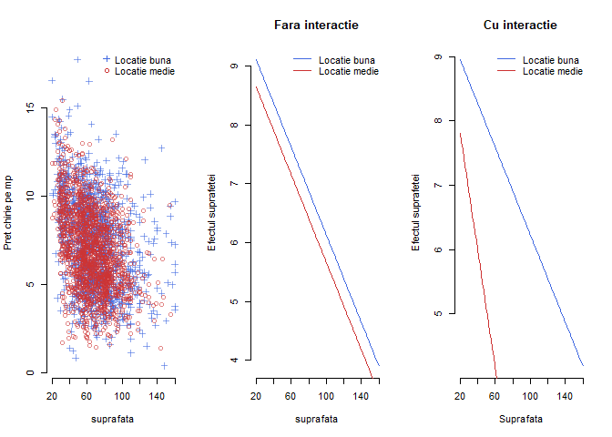

Ca regulă, în cazul unui model de regresie liniară care conține un termen de interacție sau o putere este recomandat ca acesta să conțină și efectele principale corespunzătoare care au alcătuit termenul de interacție sau putere. De exemplu, dacă în modelul de regresie apar termenii $x_1^3$ și respectiv $x_2x_3x_4$ atunci modelul ar trebui să conțină și termenii (efectele principale) $x_1$, $x_2$, $x_3$ și respectiv $x_4$.

În subsecțiunile care urmează, vom trata separat cazurile în care efectul de interacție apare între două variabile categoriale sau între o variabilă categorială și una continuă.

#### 4.3.3.1 Interacția dintre două variabile categoriale

În această secțiune vom trata cazul în care în model apar două variabile predictor calitative $x_1$ și $x_2$, categoriale, cu $c$ și respectiv $m$ categorii și suntem interesați de efectul interacției dintre cele două asupra răspunsului mediu. Cum putem modela efectul fiecărei variabile predictor categoriale prin intermediul a $c-1$ și respectiv $m-1$ variabile ajutătoare de tip indicator (*dummy*) este suficient să ne limităm atenția asupra covariabilelor binare. Într-adevăr, cele două variabile explicative $x_1$ și $x_2$ induc în modelul de regresie $cm-1$ termeni, fiecare fiind o variabilă binară.

> *Exemplu: prețul chiriilor din Munchen - interacția dintre două covariabile categoriale*

În contextul setului de date `Munchen` să presupunem că vrem să investigăm relația dintre prețul mediu al chiriilor pe metrul pătrat și tipul de baie (0 = standard, 1 = premium), respectiv bucătărie (0 = standard, 1 = premium) cu care este dotat apartamentul. În acest caz, cele două covariabile binare $x_1 = bucatarie$ și $x_2 = baie$ conduc la modelul de regresie

$$pret{\_m^2}_i = \beta_0 + \beta_1\times bucatarie_i + \beta_2\times baie_i + \beta_3\times bucatarie_i\cdot baie_i + \varepsilon_i$$

care în urma estimării devine

$$\widehat{pret{\_m^2}_i} = 7.024 + 1.419\times bucatarie_i + 0.401\times baie_i + 0.287\times bucatarie_i\cdot baie_i$$

Astfel, coeficientul $\hat{\beta_1} = 1.419$ măsoară efectul indus de o bucătărie premium asupra prețului mediu al chiriei pe metrul pătrat, $\hat{\beta_2} = 0.401$ măsoară efectul indus de o baie premium iar $\hat{\beta_3} = 0.287$ măsoară efectul adițional pentru locuințele care au și baie și bucătărie premium. Observăm că față de un apartament cu dotări standard (baie și bucătărie standard), apartamentele care au doar bucătărie premium sunt mai scumpe în medie cu 1.419 Euro pe metrul pătrat pe când cele care au doar baie premium au un preț mai ridicat cu 0.401 Euro. Având și baie și bucătărie premium face ca prețul mediu al chiriei pe metrul pătrat să crească cu 2.107 Euro.

Dacă ne interesăm acum la efectul interacției dintre covariabila locația apartamentului ($locatie$ - 1 = medie, 2 = bună, 3 = de top) și covariabila tipul de bucătărie ($bucatarie$ - 0 = standard sau 1 = premium) asupra prețului chiriei pe metrul pătrat, atunci avem modelul

$$\begin{aligned}
pret{\_m^2}_i &= \beta_0 + \beta_1\times alocatie_i + \beta_2\times glocatie_i + \beta_3\times bucatarie_i + \\
&\quad+\beta_4\times alocatie_i\cdot bucatarie_i + \beta_5\times glocatie_i\cdot bucatarie_i + \varepsilon_i
\end{aligned}$$

în care am considerat toate combinațiile posibile între valorile celor două variabile explicative (cu excepția categoriilor de referință - în acest caz locații de top). Efectul variabilei explicative $locatie$ este explicat prin intermediul a două variabile ajutătoare binare $alocatie$ și $glocatie$ folosind ca și categorie de referință locațiile din zone de top. Interpretarea coeficienților este următoarea:

$$\begin{aligned}
\beta_0: & \text{ efectul locație = de top și bucătărie = standard}\\
\beta_0 + \beta_1: & \text{ efectul locatie = medie și bucatarie = standard}\\
\beta_0 + \beta_2: & \text{ efectul locatie = bună și bucatarie = standard}\\
\beta_0 + \beta_3: & \text{ efectul locatie = de top și bucatarie = premium}\\
\beta_0 + \beta_1 + \beta_3 + \beta_4: & \text{ efectul locatie = medie și bucatarie = premium}\\
\beta_0 + \beta_2 + \beta_3 + \beta_5: & \text{ efectul locatie = bună și bucatarie = premium}\\
\end{aligned}$$

Putem observa că, față de un apartament de top cu bucătărie standard, un apartament dintr-o locație medie cu același tip de bucătărie are un preț mediu al chiriei pe metrul pătrat cu $\hat{\beta_1} = -1.279$ Euro mai mic pe când un apartament dintr-o zonă bună cu o bucătărie premium are un preț mediu cu $\hat{\beta_2} + \hat{\beta_3} + \hat{\beta_5} = 1.052$ Euro mai mare.

#### 4.3.3.2 Interacția dintre o variabilă categorială și una continuă

Să presupunem că vrem să modelăm efectul pe care îl are interacția dintre o covariabilă continuă $x$ și una discretă (categorială) $z$ cu $c$ categorii asupra răspunsului mediu. Într-o primă etapă pentru a include efectul variabilei explicative $z$ vom fixa o categorie ca și categorie de referință și vom introduce, ca și până acum, $c-1$ variabile ajutătoare de tip indicator (*dummy*). Pentru a simplifica discuția vom considera că variabila categorială $z\in\{0,1\}$ este o variabilă de tip indicator, binară, și vom presupune că efectele principale și efectele de interacție datorate covariabilelor $x$ și $z$ sunt liniare în raport cu răspunsul prin urmare avem un model de tipul

$$y = \beta_0 + \underbrace{\beta_1 x + \beta_2 z}_{\text{efecte principale}} + \underbrace{\beta_3 xz}_{\text{efect de interacție}} + \cdots + \varepsilon$$

unde prin $\cdots$ înțelegem că în model ar putea intra și alți termeni care depind de alte covariabile. În general, ar fi trebuit să includem în model toți cei $2c-1$ termeni: efecte principale $x, z_1,\ldots,z_{c-1}$ și interacții $x z_1,\ldots,x z_{c-1}$.

În ceea ce privește interpretarea termenilor modelului, aceasta se poate face atât din perspectiva covariabilei continue cât și din cea a celei discrete. Astfel, în raport cu covariabila $x$, $\beta_1 x$ este efectul liniar al covariabilei $x$ atunci când $z = 0$ iar $\beta_2 + (\beta_1 + \beta_3)x$ este efectul liniar indus de $x$ atunci când $z = 1$. Alternativ, în raport cu $z$, $\beta_2 + \beta_3 x$ reprezintă efectul produs de diferența dintre observațiile pentru care $z = 1$ și $z = 0$. Această diferență depinde de valorile covariabilei $x$, nu este constantă ca și în cazul unui model fără interacții.

> *Exemplu: prețul chiriilor din Munchen - interacția dintre o covariabilă continuă și una discretă*

În acest exemplu vom ilustra efectul de interacție dintre o variabilă explicativă continuă și una discretă folosindu-ne de setul de date `Munchen`. Ne propunem să modelăm relația dintre prețul net al chiriei unui apartament în funcție de suprafața acestuia și tipul de locație în care se află. În acest context avem de-a face cu o variabilă predictor cu trei categorii (locație de top, bună și respectiv medie) pentru care vom introduce două variabile ajutătoare de tip indicator $alocatie$ și $glocatie$, ținând ca nivel de referință categoria locațiilor de top. Presupunând că atât efectele principale cât și cele datorate interacțiilor intră liniar în model, avem

$$\begin{aligned}
pret_i &= \beta_0 + \beta_1\times suprafata_i + \beta_2\times alocatie_i + \beta_3\times glocatie_i + \\
&\quad + \beta_4\times suprafata_i\cdot alocatie_i + \beta_5\times suprafata_i\cdot glocatie_i + \varepsilon_i
\end{aligned}$$

unde prin estimare devine

$$\begin{aligned}
\widehat{pret_i} &= 137.924 + 6.22\times suprafata_i + 11.824\times alocatie_i + 1.473\times glocatie_i + \\
&\quad -1.846\times suprafata_i\cdot alocatie_i -1.274\times suprafata_i\cdot glocatie_i.
\end{aligned}$$

Putem interpreta efectele după cum urmează (acestea pot fi vizualizate în figura de mai jos):

- $\beta_1\times suprafata_i = 6.22\times suprafata_i$ - efectul suprafeței de locuit pentru apartamentele situate într-o locație de top asupra prețului mediu net al chiriei ($alocation = 0$ și $glocation = 0$)
- $\beta_2 + (\beta_1+\beta_4)\times suprafata_i = 11.824 + 4.374\times suprafata_i$ - efectul suprafeței de locuit pentru apartamentele situate într-o locație medie
- $\beta_3 + (\beta_1+\beta_5)\times suprafata_i = 1.473 + 4.946\times suprafata_i$ - efectul suprafeței de locuit pentru apartamentele situate într-o locație bună
- $\beta_3 + \beta_5\times suprafata_i = 1.473 -1.274\times suprafata_i$ - efectul diferență pentru apartamentele care se află într-o locație bună față de cele care se află într-o locație de top; coeficientul $\hat{\beta_5} = -1.274$ negativ implică faptul că prețul mediu net al chiriilor pentru apartamentele aflate într-o zonă de top sunt întotdeauna mai mari decât cele dintr-o zonă bună, pentru fiecare metru pătrat adăugat suprafeței de locuit face ca diferența dintre prețul mediu net al chiriei pentru locații bune și să scadă cu 1.274 Euro față de cel al locuințelor situate în locații de top
- $\beta_2 + \beta_4\times suprafata_i = 11.824 -1.846\times suprafata_i$ - efectul diferență pentru apartamentele care se află într-o locație medie față de cele care se află într-o locație de top
- $\beta_3 -\beta_2 + (\beta_5 - \beta_4)\times suprafata_i = -10.351 + 0.572\times suprafata_i$ - efectul diferență pentru apartamentele care se află într-o locație bună față de cele care se află într-o locație medie $\square$

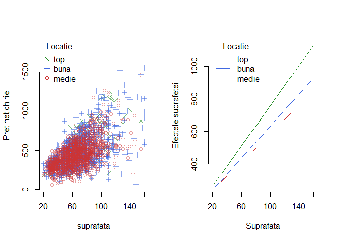

În exemplul anterior am presupus că efectul principal indus de covariabila continuă și efectul de interacție dintre covariabila continuă și cea categorială este liniar asupra răspunsului mediu dar putem include în model și efecte neliniare. Să presupunem că efectul principal indus de covariabila $x$ este $f_1(x)$ și efectul de interacție este $f_2(x)z$ (pentru cazul de liniaritate aveam $f_1(x) = \beta_1 x$ și respectiv $f_2(x) = \beta_2 x$) ceea ce conduce la modelul

$$y = \beta_0 + \beta_1 z + f_1(x) + \underbrace{f_2(x)z}_{\text{efect de interacție}} + \cdots + \varepsilon$$

Ca și în secțiunea Cazul variabilelor explicative continue, neliniaritatea efectelor poate fi dobândită atât prin folosirea de transformări asupra covariabilelor cât și prin intermediul polinoamelor. De exemplu, putem considera că $f_1(x) = \beta_2 x + \beta_3 \log(x)$ iar $f_2(x) = \beta_4 x + \beta_5 x^2$ și în acest caz modelul devine

$$y = \beta_0 + \beta_1 z + \beta_2 x + \beta_3 \log(x) + \beta_4 xz + \beta_5 x^2z + \cdots + \varepsilon.$$

Pentru interpretarea modelului avem:

- $f_1(x)$ - efectul neliniar indus de covariabila continuă $x$ atunci când $z = 0$
- $\beta_1 + f_1(x) + f_2(x)$ - efectul neliniar indus de covariabila continuă $x$ atunci când $z = 1$; cele două curbe $f_1(x)$ și $\beta_1 + f_1(x) + f_2(x)$ prezintă intensitatea interacției, în cazul lipsei acesteia curbele fiind paralele (ar fi o translație cu $\beta_1$)
- $\beta_1 + f_2(x)$ - efectul diferență apărut pentru observațiile cu $z = 1$ în raport cu cele pentru care $z = 0$

Pentru a facilita interpretarea, efectul principal $f_1(x)$ trebuie centrat în zero, același lucru nefiind necesar pentru $f_2$.

> *Exemplu: prețul chiriilor din Munchen - interacția dintre o covariabilă continuă și una discretă - efect neliniar*

Pentru a ilustra efectul neliniar de interacție dintre o covariabilă continuă și una discretă vom considera, în contextul setului de date `Munchen`, acele apartamente care se află în locații bune sau locații de tip mediu (vom folosi doar covariabila $glocation$). Dorim să modelăm relația dintre prețul chiriei pe metrul pătrat în funcție de suprafața de locuit și tipul de locație și vom folosi ca efect principal pentru suprafață transformarea $\frac{1}{x}$ ca și în Exemplul . Presupunând că avem un efect de interacție liniar între suprafață și tipul locației atunci avem modelul

$$pret{\_m^2}_i = \beta_0 + \beta_1\times glocatie_i + f_1(suprafata_i) + f_2(suprafata_i)\cdot glocatie_i + \varepsilon_i$$

unde $f_1(suprafata_i) = \beta_1\left(\underbrace{\frac{1}{suprafata_i} - \overline{\frac{1}{suprafata_i}}}_{suprafata{\_inv\_cen}_i}\right)$ iar $f_2(suprafata_i) = \beta_3\times suprafata_i$. În urma estimării găsim

$$\widehat{pret{\_m^2}_i} = 6.918 + 0.334\times glocatie_i + 147.152\times suprafata{\_inv\_cen}_i + 0.001suprafata_i\cdot glocatie_i$$

Pentru interpretarea rezultatelor am inclus în figura de mai jos efectul estimat $\hat{f_1}(suprafata_i)$ a suprafeței de locuit în locații medii (cu roșu) și efectul estimat $\hat{\beta_1} + \hat{f_1}(suprafata_i) + \hat{f_2}(suprafata_i)$ al suprafeței pentru apartamentele din locații bune (albastru).

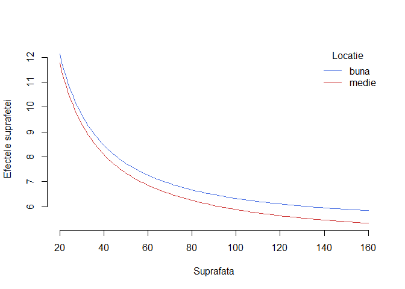

Constatăm că efectele suprafeței pentru apartamentele situate în locații bune și medii sunt similare, chiar dacă cele două curbe nu sunt paralele (ceea ce implică un efect de interacție). Dacă suprafața de locuit crește atunci prețul mediu pe metrul pătrat scade pentru ambele locații. De asemenea, se observă că apartamentele situate în locații bune sunt întotdeauna mai scumpe decât cele din locații medii, indiferent de mărimea acestora. Diferența de preț este mai mică pentru apartamentele cu suprafața mai mică față de cele cu suprafața mai mare ceea ce sugerează că odată cu creșterea în suprafață găsim și o creștere în diferența medie de preț pe metrul pătrat între imobile situare în locații bune și medii, iar această diferență crește liniar.

## 4.4 Estimarea parametrilor

În această secțiune vom prezenta estimatorii parametrilor modelului de regresie liniară, $\boldsymbol\beta$ și $\sigma^2$, precum și o serie de proprietăți statistice ale acestora fără a face ipoteze suplimentare asupra distribuției răspunsului. Înainte de a începe, vom reaminti că modelul de regresie liniară multiplă se poate scrie sub forma matriceală $\boldsymbol Y = \boldsymbol X\boldsymbol \beta + \boldsymbol \varepsilon$, unde $\boldsymbol Y$, $\boldsymbol X$, $\boldsymbol\beta$, și $\boldsymbol\varepsilon$ sunt în conformitate cu Definiția . Ipotezele făcute asupra modelului sunt cele menționate în secțiunea Modelare și anume: $\mathcal{H}_1: \, rang(\boldsymbol X) = p+1$ ($n>p+1$) și respectiv $\mathcal{H}_2: \, \mathbb{E}[\boldsymbol \varepsilon] = 0,\, Var(\boldsymbol \varepsilon) = \sigma^2 I_n$.

### 4.4.1 Estimarea coeficienților de regresie prin metoda celor mai mici pătrate

În conformitate cu metoda celor mai mici pătrate (ordinary least squares), coeficienții (necunoscuți) modelului de regresie $\boldsymbol\beta$ se estimează prin minimizarea costului total

$$\underset{\boldsymbol\beta\in\mathbb{R}^{p+1}}{\arg\min}\sum_{i = 1}^{n}L\left(y_i - \underbrace{\left(\beta_0 + \beta_1 x_{i1} + \cdots + \beta_p x_{ip}\right)}_{f(\boldsymbol x_i)}\right)$$

unde funcția de $L$ este funcția de cost pătratic $L(u) = u^2$. Prin urmarea, estimatorul $\hat{\boldsymbol \beta}$ obținut prin metoda celor mai mici pătrate este definit prin

$$\hat{\boldsymbol \beta} = \underset{\boldsymbol\beta\in\mathbb{R}^{p+1}}{\arg\min}\sum_{i = 1}^{n}\left[y_i - \left(\beta_0 + \beta_1 x_{i1} + \cdots + \beta_p x_{ip}\right)\right]^2 = \underset{\boldsymbol\beta\in\mathbb{R}^{p+1}}{\arg\min}\sum_{i = 1}^{n}\left(y_i - \sum_{j= 0}^{p}\beta_j x_{ij}\right)^2 = \underset{\boldsymbol\beta\in\mathbb{R}^{p+1}}{\arg\min}\left\lVert \boldsymbol Y - \boldsymbol X \boldsymbol\beta\right\rVert^2$$

unde am folosit convenția $x_{i0} = 1$, $i = 1,2,\ldots,n$.

De exemplu, în cazul în care $p=2$, în care avem doar două variabile explicative și putem afișa observațiile într-un cadru trei dimensional, figura de mai jos ilustrează, pentru un set de date simulat, diagrama de împrăștiere (cu proiecțiile pe fiecare plan - albastru) împreună cu planul de regresie obținut prin metoda celor mai mici pătrate (acel plan pentru care suma pătratelor distanțelor verticale până la plan este minimă).

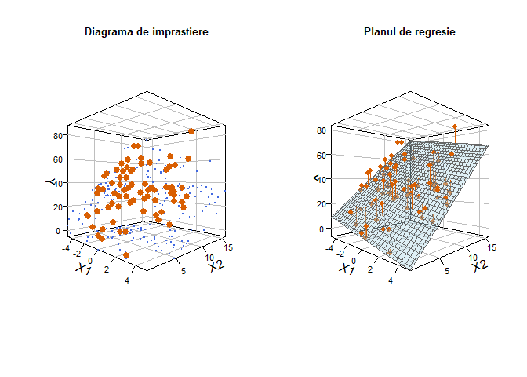

În propoziția următoare prezentăm forma estimatorului coeficienților de regresie obținut prin metoda celor mai mici pătrate:

Dacă ipoteza $\mathcal{H}_1$ este adevărată atunci estimatorul $\hat{\boldsymbol \beta}$ obținut prin metoda celor mai mici pătrate este

$$\hat{\boldsymbol \beta} = (\boldsymbol{X}^\intercal \boldsymbol X)^{-1}\boldsymbol{X}^\intercal \boldsymbol Y$$

Ne propunem să prezentăm mai multe metode de calcul pentru estimatorul $\hat{\boldsymbol \beta}$.

1. Metoda geometrică

Din punct de vedere geometric, ne plasăm în spațiul variabilelor $\mathbb{R}^n$ (am presupus că $n>p$)). Vectorul variabilelor răspuns $\boldsymbol Y\in \mathbb{R}^n$ iar matricea de design $\boldsymbol{X}$ poate fi văzută ca fiind formată din $p+1$ vectori coloană, $\boldsymbol{X} = \left[\underbrace{\boldsymbol X_0}_{\mathbf{1} = (1,\cdots,1)}|\boldsymbol X_1|\cdots|\boldsymbol X_p\right]$.

Începem prin a reaminti câteva noțiuni de algebră liniară, pentru mai multe detalii se poate consulta monografia (Ornea and Turtoi 2000). Fiind dată matricea (de design) $\boldsymbol{X}\in\mathcal{M}_{n,p+1}(\mathbb{R})$ putem defini nucleul matricei

$$\ker(\boldsymbol{X}) = \left\{\boldsymbol u\in\mathbb{R}^{p+1}\,|\, \boldsymbol{X}\boldsymbol u = 0\right\}$$

ca fiind subspațiul lui $\mathbb{R}^{p+1}$ care conține vectorii ortogonali pe liniile din matricea $\boldsymbol{X}$. De asemenea, imaginea matricei $\boldsymbol{X}$ este subspațiul vectorilor din $\mathbb{R}^n$ care se pot scrie ca o combinație liniară de coloanele matricei $\boldsymbol{X}$ și este definit prin

$$\mathrm{Im}(\boldsymbol{X}) = \left\{\boldsymbol v\in\mathbb{R}^{n}\,|\,\exists \boldsymbol u\in\mathbb{R}^{p+1} \text{ a.î. } \boldsymbol{X}\boldsymbol u = \boldsymbol v\right\}.$$

Se poate arăta (a se vedea (Ornea and Turtoi 2000, Capitolul 1)) că $\dim \ker(\boldsymbol{X}) = p + 1 - \mathrm{rang}(\boldsymbol{X})$ și că $\dim \mathrm{Im}(\boldsymbol{X}) = \mathrm{rang}(\boldsymbol{X})$ ceea ce conduce la $\dim \ker(\boldsymbol{X}) + \dim \mathrm{Im}(\boldsymbol{X}) = p+1$ (caz particular al *teoremei lui Grassman*).

Reamintim că doi vectori $\boldsymbol u$ și $\boldsymbol v$ sunt ortogonali dacă $\langle \boldsymbol u, \boldsymbol v\rangle = 0$, iar în acest caz scriem $\boldsymbol u \perp \boldsymbol v$, și că două subspații $V$ și $W$ sunt ortogonale dacă $\forall \boldsymbol v \in V$ și respectiv $\forall \boldsymbol w \in W$ avem $\boldsymbol v\perp \boldsymbol w$ și notăm $V\perp W$. De asemenea, spațiul ortogonal al lui $V$ este spațiul $V^{\perp}$ care conține toți vectorii ortogonali pe $V$ și are ca proprietăți: $V\cap V^{\perp} = \{0\}$ și $\left(V^{\perp}\right)^\perp = V$. Se poate arăta cu ușurință că dacă $V$ este un subspațiu a lui $W\subset\mathbb{R}^n$ atunci pentru orice vector $\boldsymbol w\in W$ avem că $\boldsymbol w = \boldsymbol v + \boldsymbol v^\perp$ unde $\boldsymbol v\in V$ și $\boldsymbol v^\perp\in V^\perp$ iar descompunerea se face în mod unic (acest rezultat se mai scrie și sub forma $W = V\oplus V^\perp$). Se numește *proiecție ortogonală*[^4] a lui $\boldsymbol w$ pe $V$ de-a lungul lui $V^\perp$ endomorfismul $p_V: W\to W$ definit prin $p_V(\boldsymbol w) = \boldsymbol v$. Se poate arăta cu ușurință că dacă $V$ este un subspațiu vectorial al lui $W$ atunci au loc următoarele proprietăți:

1. pentru orice $\boldsymbol w\in W$ avem: $\boldsymbol w = p_V(\boldsymbol w) + p_{V^\perp}(\boldsymbol w)$, $\lVert p_V(\boldsymbol w)\rVert \leq \lVert \boldsymbol w\rVert$ iar $\boldsymbol w - p_{V}(\boldsymbol w) \perp \boldsymbol v$, $\forall \boldsymbol v \in V$
2. pentru orice $\boldsymbol w\in W$ are loc $\lVert \boldsymbol w - p_V(\boldsymbol w)\rVert = \inf_{\boldsymbol v\in V}\lVert \boldsymbol w - \boldsymbol v\rVert$
3. dacă $p$ este o proiecție ortogonală atunci $p\circ p = p$
4. dacă $p$ este un endomorfism care verifică $p\circ p = p$ și în plus $\textrm{Im}(p)\perp \ker(p)$ atunci $p$ este proiecția ortogonală pe $\textrm{Im}(p)$ de-a lungul lui $\ker(p)$
5. dacă $\{\boldsymbol e_1, \boldsymbol e_2, \ldots, \boldsymbol e_k\}$ este o bază ortonormală în $V$ atunci $p_V(\boldsymbol w) = \sum_{i = 1}^{k}\langle \boldsymbol w, \boldsymbol e_i\rangle \boldsymbol e_i$

Spunem că o matrice pătratică $P\in\mathcal{M}_{n}(\mathbb{R})$ este o matrice de proiecție dacă este idempotentă $P^2 = P$ (numele vine de la faptul că pentru $\boldsymbol x\in\mathbb{R}^n$ aplicația liniară $P\boldsymbol x$ este proiecția lui $\boldsymbol x$ pe $\mathrm{Im}(P)$ de-a lungul lui $\ker(P)$ - a se vedea (Ornea and Turtoi 2000, Capitolul 1, Secțiunea 5.2) sau (Yanai, Takeuchi, and Takane 2011, Capitolul 2)). Dacă în plus matricea $P$ este simetrică, i.e. $P = P^\intercal$, atunci $P\boldsymbol x$ este proiecția ortogonală a lui $\boldsymbol x$ pe $V = \mathrm{Im}(P)$ de-a lungul lui $V^\perp = \ker(P)$, cu alte cuvinte în descompunerea $\boldsymbol x = P\boldsymbol x + (I - P)\boldsymbol x$ vectorii $P\boldsymbol x$ și respectiv $(I - P)\boldsymbol x$ sunt ortogonali (Yanai, Takeuchi, and Takane 2011, Capitolul 2, Secțiunea 2.2). Prin urmare matricea $P$ este o matrice de proiecție ortogonală dacă are loc relația $\boldsymbol v\perp \boldsymbol v - P\boldsymbol v$ adică $\langle\boldsymbol v, \boldsymbol v - P\boldsymbol v\rangle = 0$ pentru toți $\boldsymbol v$.

Dacă $\boldsymbol{X}\in\mathcal{M}_{m,k}(\mathbb{R})$ este o matrice de $\mathrm{rang}(\boldsymbol{X}) = k$ ($m\geq k$), deci $\boldsymbol{X}^\intercal\boldsymbol{X}$ este inversabilă, atunci pentru a determina matricea de proiecție ortogonală $P_X$ pe subspațiul imagine $\mathrm{Im}(\boldsymbol{X})$ să observăm că dacă $\boldsymbol v\in \textrm{Im}(\boldsymbol X)$ atunci $\boldsymbol v = \boldsymbol X \boldsymbol \alpha$ și cum $P_X \boldsymbol v = \boldsymbol v$ deducem că $P_X \boldsymbol v = \boldsymbol{X}\underbrace{\left(\boldsymbol{X}^\intercal\boldsymbol{X}\right)^{-1}\boldsymbol{X}^\intercal \boldsymbol v}_{= \boldsymbol \alpha}$. În plus dacă $\boldsymbol v^\perp\in \textrm{Im}(\boldsymbol X)^\perp = \ker(\boldsymbol X^\intercal)$ atunci $\boldsymbol X^\intercal\boldsymbol v^\perp = 0$ prin urmare $\boldsymbol{X}\left(\boldsymbol{X}^\intercal\boldsymbol{X}\right)^{-1}\boldsymbol{X}^\intercal \boldsymbol v^\perp = 0$ și astfel, pentru $\boldsymbol w = \boldsymbol v + \boldsymbol v^\perp$ arbitrar, avem $P_{X}\boldsymbol w = \boldsymbol{X}\left(\boldsymbol{X}^\intercal\boldsymbol{X}\right)^{-1}\boldsymbol{X}^\intercal\boldsymbol w$ de unde găsim că

$$P_{X} = \boldsymbol{X}\left(\boldsymbol{X}^\intercal\boldsymbol{X}\right)^{-1}\boldsymbol{X}^\intercal.$$

În cazul particular în care $\boldsymbol{X} = \boldsymbol{v}$ avem

$$P_v = \boldsymbol{v}\left(\boldsymbol{v}^\intercal\boldsymbol{v}\right)^{-1}\boldsymbol{v}^\intercal = \frac{\boldsymbol{v}\boldsymbol{v}^\intercal}{\lVert\boldsymbol{v}\rVert^2}$$

prin urmare proiecția vectorului $\boldsymbol{u}$ pe $\boldsymbol{v}$ este $P_v\boldsymbol{u} = \frac{\boldsymbol{v}\boldsymbol{v}^\intercal}{\lVert\boldsymbol{v}\rVert^2}\boldsymbol{u} = \frac{\langle\boldsymbol{u}, \boldsymbol{v}\rangle}{\lVert\boldsymbol{v}\rVert^2}\boldsymbol{v}$.

Pentru problema noastră, notăm cu $\mathcal{M}(X) = \mathrm{Im}(\boldsymbol{X})$ subspațiul imagine și conform ipotezei $\mathcal{H}_1$ avem că $\mathrm{rang}(\boldsymbol{X}) = p+1$, deci $\dim \mathcal{M}(X) = p+1$. Din definiția spațiului imagine avem că toți vectorii din $\mathcal{M}(X)$ sunt de forma $\boldsymbol X \boldsymbol\alpha$, cu $\boldsymbol \alpha = (\alpha_0, \alpha_1,\ldots, \alpha_p)\in\mathbb{R}^{p+1}$

$$\boldsymbol X \boldsymbol\alpha = \sum_{i = 0}^{p}\alpha_i \boldsymbol X_i.$$

Conform modelului de regresie, $\boldsymbol Y = \boldsymbol X\boldsymbol \beta + \boldsymbol \varepsilon$, vectorul răspuns $\boldsymbol Y$ este suma dintre un element din $\mathcal{M}(X)$ și un element din $\mathbb{R}^n$ care nu are niciun motiv să aparțină tot lui $\mathcal{M}(X)$. Astfel, problema minimizării funcției $S(\boldsymbol \beta) = \left\lVert \boldsymbol Y - \boldsymbol X \boldsymbol\beta\right\rVert^2$ revine la a găsi acel vector din $\mathcal{M}(X)$ care este cel mai aproape de $\boldsymbol Y$ în sensul distanței euclidiene, cu alte cuvinte de a determina vectorul proiecției ortogonale a lui $\boldsymbol Y$ pe $\mathcal{M}(X)$ (a se vedea figura de mai jos).

Proiecția ortogonală a lui $\boldsymbol Y$ pe $\mathcal{M}(X)$ se notează cu $\hat{\boldsymbol Y} = P_X \boldsymbol Y$, unde $P_X$ este matricea de proiecție ortogonală pe $\mathcal{M}(X)$, iar spațiul ortogonal $\mathcal{M}(X)^\perp$ se mai numește și spațiul reziduurilor și are dimensiunea $\dim \mathcal{M}(X)^\perp = n - (p+1)$ (*teorema lui Grassman*). Să remarcăm că $\hat{\boldsymbol Y}\in\mathcal{M}(X)$ deci putem scrie $\hat{\boldsymbol Y} = \boldsymbol X\hat{\boldsymbol \beta}$ unde $\hat{\boldsymbol \beta}$ reprezintă estimatorul obținut prin metoda celor mai mici pătrate iar elementele lui $\hat{\boldsymbol \beta}$ sunt coordonatele vectorului $\hat{\boldsymbol Y}$ în baza $\{\boldsymbol X_0, \boldsymbol X_1,\ldots, \boldsymbol X_p\}$ a spațiului $\mathcal{M}(X)$. Cum reperul $\{\boldsymbol X_0, \boldsymbol X_1,\ldots, \boldsymbol X_p\}$ nu este neapărat ortogonal, elementele $\hat{\beta_j}$ nu sunt neapărat coordonatele proiecției lui $\boldsymbol Y$ pe $\boldsymbol X_j$, aceasta din urmă fiind dată de

$$\begin{align*}
P_{X_j}\boldsymbol Y &= P_{X_j}P_X \boldsymbol Y = P_{X_j}\sum_{i = 0}^{p} \hat{\beta_i}\boldsymbol X_i\\
&= \sum_{i = 0}^{p}\hat{\beta_i} P_{X_j}\boldsymbol X_i = \hat{\beta_j} \boldsymbol X_j + \sum_{i \neq j}\hat{\beta_i} P_{X_j}\boldsymbol X_i
\end{align*}$$

În cazul în care $\boldsymbol X_j$ este ortogonal pe $\boldsymbol X_i$, $i\neq j$, atunci $P_{X_j}\boldsymbol Y = \hat{\beta_j} \boldsymbol X_j$ iar dacă $\langle\boldsymbol X_i, \boldsymbol X_j\rangle = 0$ pentru toți $i\neq j$ atunci matricea $\boldsymbol X^\intercal\boldsymbol X = \mathrm{diag}\left(\lVert\boldsymbol X_0\rVert^2, \lVert\boldsymbol X_1\rVert^2, \ldots, \lVert\boldsymbol X_p\rVert^2\right)$.

O altă metodă (tot prin proiecții) de a arăta că $\hat{\boldsymbol \beta} = (\boldsymbol{X}^\intercal \boldsymbol X)^{-1}\boldsymbol{X}^\intercal \boldsymbol Y$ se bazează pe observația că proiecția ortogonală $\hat{\boldsymbol Y} = \boldsymbol X\hat{\boldsymbol \beta}$ este definită ca fiind unicul vector pentru care $\boldsymbol Y - \hat{\boldsymbol Y}$ este ortogonal pe $\mathcal{M}(X)$. Cum $\mathcal{M}(X)$ este generat de $\{\boldsymbol X_0, \boldsymbol X_1,\ldots, \boldsymbol X_p\}$ putem spune că $\boldsymbol Y - \hat{\boldsymbol Y}$ este ortogonal pe fiecare $\boldsymbol X_i$:

$$\left\{\begin{array}{lll}
\langle \boldsymbol X_0, \boldsymbol Y - \hat{\boldsymbol Y}\rangle = 0\\
\langle \boldsymbol X_1, \boldsymbol Y - \hat{\boldsymbol Y}\rangle = 0\\
\vdots\\
\langle \boldsymbol X_p, \boldsymbol Y - \hat{\boldsymbol Y}\rangle = 0
\end{array}\right. \iff \left\{\begin{array}{lll}
\langle \boldsymbol X_0, \boldsymbol Y - \boldsymbol X\hat{\boldsymbol \beta}\rangle = 0\\
\langle \boldsymbol X_1, \boldsymbol Y - \boldsymbol X\hat{\boldsymbol \beta}\rangle = 0\\
\vdots\\
\langle \boldsymbol X_p, \boldsymbol Y - \boldsymbol X\hat{\boldsymbol \beta}\rangle = 0
\end{array}\right. \iff \boldsymbol X^\intercal \left(\boldsymbol Y - \boldsymbol X\hat{\boldsymbol \beta}\right) = 0$$

de unde găsim *sistemul de ecuații normale*

$$\boldsymbol X^\intercal\boldsymbol X\hat{\boldsymbol \beta} = \boldsymbol X^\intercal\boldsymbol Y$$

care, atunci când ipoteza $\mathcal{H}_1$ este adevărată - matricea $\boldsymbol X^\intercal \boldsymbol X$ este inversabilă, revine la

$$\hat{\boldsymbol \beta} = (\boldsymbol X^\intercal \boldsymbol X)^{-1} \boldsymbol X^\intercal \boldsymbol Y.$$

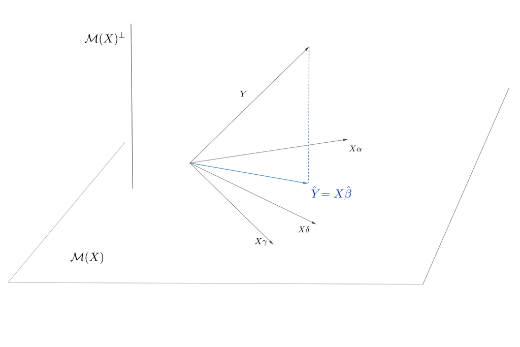

Notând cu $P_{X^\perp} = I_n - P_X$ matricea de proiecție ortogonală pe $\mathcal{M}^\perp(X)$, unde $P_X = \boldsymbol X(\boldsymbol X^\intercal \boldsymbol X)^{-1} \boldsymbol X^\intercal$ este matricea de proiecție ortogonală pe $\mathcal{M}(X)$, observăm că descompunerea

$$\boldsymbol Y = \hat{\boldsymbol Y} + \left(\boldsymbol Y - \hat{\boldsymbol Y}\right) = P_X\boldsymbol Y + (I - P_X)\boldsymbol Y = P_X\boldsymbol Y + P_{X^\perp}\boldsymbol Y$$

nu este altceva decât descompunerea ortogonală a lui $\boldsymbol Y$ pe $\mathcal{M}(X)$ și respectiv $\mathcal{M}^\perp(X)$. De asemenea este de remarcat faptul că în ceea ce privește notația folosită în literatura de statistică de specialitate, matricea de proiecție ortogonală $P_X$ se mai notează și cu $H$ (care vine de la *hat*, $\hat{\boldsymbol Y} = H\boldsymbol Y$).

2. Metoda analitică

O a doua metodă este metoda analitică. Problema noastră cere să căutăm vectorul $\boldsymbol \beta\in\mathbb{R}^{p+1}$ care minimizează funcția

$$\begin{align*}
S(\boldsymbol \beta) &= \left\lVert \boldsymbol Y - \boldsymbol X \boldsymbol\beta\right\rVert^2 = \left(\boldsymbol Y - \boldsymbol X \boldsymbol\beta\right)^\intercal\left(\boldsymbol Y - \boldsymbol X \boldsymbol\beta\right) = \boldsymbol Y^\intercal \boldsymbol Y - \boldsymbol Y^\intercal \boldsymbol X \boldsymbol\beta - \boldsymbol \beta^\intercal \boldsymbol X^\intercal \boldsymbol Y + \boldsymbol \beta^\intercal \boldsymbol X^\intercal \boldsymbol X \boldsymbol\beta \\
& = \boldsymbol \beta^\intercal \boldsymbol X^\intercal \boldsymbol X \boldsymbol\beta - 2 \boldsymbol Y^\intercal \boldsymbol X \boldsymbol\beta + \lVert \boldsymbol Y \rVert^2
\end{align*}$$

unde am folosit faptul că $\boldsymbol Y^\intercal \boldsymbol X \boldsymbol\beta = \left(\boldsymbol Y^\intercal \boldsymbol X \boldsymbol\beta\right)^\intercal = \boldsymbol \beta^\intercal \boldsymbol X^\intercal \boldsymbol Y$ (sunt elemente de dimensiune $1\times 1$). Pentru aceasta trebuie să rezolvăm ecuația $\nabla S(\boldsymbol \beta) = 0$ și să verificăm că soluția este într-adevăr punct de minim.

Reamintim că dacă $f:\mathbb{R}^k\to\mathbb{R}$ atunci

$$\nabla f = \frac{\partial f}{\partial \boldsymbol x^\intercal} = \begin{pmatrix}\frac{\partial f}{\partial x_1} & \frac{\partial f}{\partial x_2} & \cdots & \frac{\partial f}{\partial x_k}\end{pmatrix}.$$

În particular, pentru $f(\boldsymbol x) = \boldsymbol a^\intercal \boldsymbol x$ (formă liniară) avem

$$\nabla f = \frac{\partial \boldsymbol a^\intercal \boldsymbol x}{\partial \boldsymbol x^\intercal} = \begin{pmatrix}\frac{\partial \sum_{i=1}^{k}a_i x_i}{\partial x_1} & \frac{\partial \sum_{i=1}^{k}a_i x_i}{\partial x_2} & \cdots & \frac{\partial \sum_{i=1}^{k}a_i x_i}{\partial x_k}\end{pmatrix} = \boldsymbol a^\intercal$$

iar $\frac{\partial \boldsymbol a^\intercal \boldsymbol x}{\partial \boldsymbol x} = \boldsymbol a$.

În cazul în care $f$ este o aplicație liniară, $f(\boldsymbol x) = A \boldsymbol x$ unde $A\in\mathcal{M}_{m,k}(\mathbb{R})$, atunci

$$A \boldsymbol x = \begin{pmatrix}\sum_{j=1}^{k}a_{1j} x_j\\
\sum_{j=1}^{k}a_{2j} x_j\\
\vdots\\
\sum_{j=1}^{k}a_{mj} x_j\end{pmatrix}, \qquad \frac{\partial A \boldsymbol x}{\partial x_j} = \begin{pmatrix}a_{1j}\\
a_{2j}\\
\vdots\\
a_{mj}\end{pmatrix}$$

și

$$\frac{\partial A \boldsymbol x}{\partial \boldsymbol x^\intercal} = \begin{pmatrix}\begin{pmatrix}a_{11}\\
a_{21}\\
\vdots\\
a_{m1}\end{pmatrix}, \ldots, \begin{pmatrix}a_{1j}\\
a_{2j}\\
\vdots\\
a_{mj}\end{pmatrix}, \ldots, \begin{pmatrix}a_{1k}\\
a_{2k}\\
\vdots\\
a_{mk}\end{pmatrix}\end{pmatrix} = \begin{pmatrix}a_{11} & \cdots & a_{1j} & \cdots & a_{1k}\\
\vdots & \ddots & \vdots & \ddots & \vdots\\
a_{i1} & \cdots & a_{ij} & \cdots & a_{ik}\\
\vdots & \ddots & \vdots & \ddots & \vdots\\
a_{m1} & \cdots & a_{mj} & \cdots & a_{mk}
\end{pmatrix} = A.$$

În mod similar se poate verifica și relația $\frac{\partial \boldsymbol x^\intercal A^\intercal}{\partial \boldsymbol x} = A^\intercal$.

Dacă $f$ este o formă pătratică $f(\boldsymbol x) = \boldsymbol x^\intercal A \boldsymbol x$ cu $A\in\mathcal{M}_{k}(\mathbb{R})$ (matrice pătratică de ordin $k$), atunci

$$\boldsymbol x^\intercal A \boldsymbol x = \sum_{i = 1}^{k}\sum_{j = 1}^{k}a_{ij}x_ix_j = \sum_{i = 1}^{k}a_{ii}x_i^2 + \sum_{i = 1}^{k}\sum_{\substack{j = 1\\ j\neq i}}^{k}a_{ij}x_ix_j$$

de unde

$$\frac{\partial \boldsymbol x^\intercal A \boldsymbol x}{\partial x_r} = 2 a_{rr}x_r + \sum_{j\neq r}a_{rj}x_j + \sum_{i\neq r}a_{ir}x_i = \sum_{j = 1}^{k}a_{rj}x_j + \sum_{i = 1}^{k}a_{ir}x_i$$

prin urmare

$$\frac{\partial \boldsymbol x^\intercal A \boldsymbol x}{\partial \boldsymbol x} = \begin{pmatrix}\frac{\partial \boldsymbol x^\intercal A \boldsymbol x}{\partial x_1}\\
\vdots\\
\frac{\partial \boldsymbol x^\intercal A \boldsymbol x}{\partial x_k}\end{pmatrix} = \begin{pmatrix}\sum_{j = 1}^{k}a_{1j}x_j + \sum_{i = 1}^{k}a_{i1}x_i\\
\vdots\\
\sum_{j = 1}^{k}a_{kj}x_j + \sum_{i = 1}^{k}a_{ik}x_i\end{pmatrix} = A\boldsymbol x + A^\intercal \boldsymbol x.$$

De asemenea putem observa că $\frac{\partial \boldsymbol x^\intercal A \boldsymbol x}{\partial \boldsymbol x^\intercal} = \left(A\boldsymbol x + A^\intercal \boldsymbol x\right)^\intercal = \boldsymbol x^\intercal A^\intercal + \boldsymbol x^\intercal A$.

În plus, dacă $A\in\mathcal{M}_{k}(\mathbb{R})$ este o matrice simetrică ($A^\intercal = A$) atunci

$$\frac{\partial \boldsymbol x^\intercal A \boldsymbol x}{\partial \boldsymbol x} = 2A\boldsymbol x, \quad \frac{\partial \boldsymbol x^\intercal A \boldsymbol x}{\partial \boldsymbol x^\intercal} = 2\boldsymbol x^\intercal A^\intercal.$$

Revenind la problema noastră observăm că $S(\boldsymbol \beta)$ este pătratică în $\boldsymbol \beta$ iar matricea $\boldsymbol X^\intercal \boldsymbol X$ este simetrică, prin urmare

$$\nabla S(\boldsymbol \beta) = \frac{\partial S(\boldsymbol \beta)}{\partial \boldsymbol \beta^\intercal} = \frac{\partial }{\partial \boldsymbol \beta^\intercal}\left(\boldsymbol \beta^\intercal \boldsymbol X^\intercal \boldsymbol X \boldsymbol\beta - 2 \boldsymbol Y^\intercal \boldsymbol X \boldsymbol\beta + \lVert \boldsymbol Y \rVert^2\right) = 2 \boldsymbol \beta^\intercal (\boldsymbol X^\intercal \boldsymbol X) - 2 \boldsymbol Y^\intercal \boldsymbol X = 0$$

este echivalentă cu *sistem de ecuații normale* (prin trecerea la transpusă)

$$(\boldsymbol X^\intercal \boldsymbol X)\boldsymbol \beta = \boldsymbol X^\intercal\boldsymbol Y$$

care atunci când ipoteza $\mathcal{H}_1$ este adevărată, ceea ce conduce la inversabilitatea matricei $\boldsymbol X^\intercal \boldsymbol X$ (are valori proprii nenule), revine la

$$\hat{\boldsymbol \beta} = (\boldsymbol X^\intercal \boldsymbol X)^{-1} \boldsymbol X^\intercal \boldsymbol Y.$$

Pentru a arăta că $\hat{\boldsymbol \beta}$ este într-adevăr un punct de minim pentru $S(\boldsymbol \beta)$ trebuie să arătăm că matricea hessiană este pozitiv definită. Matricea hessiană, ținând cont de simetria matricii $\boldsymbol X^\intercal \boldsymbol X$, este

$$\frac{\partial^2 S(\boldsymbol \beta)}{\partial \boldsymbol \beta\partial \boldsymbol \beta^\intercal} = \frac{\partial}{\partial \boldsymbol \beta}\left(\frac{\partial S(\boldsymbol \beta)}{\partial \boldsymbol \beta^\intercal}\right) = \frac{\partial}{\partial \boldsymbol \beta}\left(2 \boldsymbol \beta^\intercal (\boldsymbol X^\intercal \boldsymbol X) - 2 \boldsymbol Y^\intercal \boldsymbol X\right) = 2 \boldsymbol X^\intercal \boldsymbol X$$

iar pentru $\boldsymbol u\in\mathbb{R}^{p+1}\backslash\{0\}$ avem

$$\boldsymbol u^\intercal \frac{\partial^2 S(\boldsymbol \beta)}{\partial \boldsymbol \beta\partial \boldsymbol \beta^\intercal} \boldsymbol u = \boldsymbol u^\intercal \left(2 \boldsymbol X^\intercal \boldsymbol X\right) \boldsymbol u = \langle \boldsymbol X\boldsymbol u, \boldsymbol X\boldsymbol u\rangle = 2\lVert \boldsymbol X\boldsymbol u\rVert^2 > 0$$

deci $\boldsymbol X^\intercal \boldsymbol X$ este pozitiv definită prin urmare și $\frac{\partial^2 S(\boldsymbol \beta)}{\partial \boldsymbol \beta\partial \boldsymbol \beta^\intercal}$ este pozitiv definită. $\square$

În cele ce urmează vom prezenta două cazuri particulare ale modelului de regresie liniară: modelul nul și respectiv modelul de regresie liniară simplă.

> *Exemplu: modelul nul*

În acest exemplu considerăm că modelul de regresie liniară nu conține niciun predictor ci doar termenul constant $\mu$, prin urmare modelul se scrie

$$y_i = \mu + \varepsilon_i, \quad i = 1,2,\ldots,n.$$

Acesta este un caz particular în care $p = 0$, $\boldsymbol X = \boldsymbol 1$ iar $\boldsymbol \beta = \mu$. Cum $\boldsymbol X^\intercal \boldsymbol X = \boldsymbol 1^\intercal\boldsymbol 1 = n$ găsim că estimatorul coeficientului de regresie obținut prin metoda celor mai mici pătrate este

$$\hat\beta = (\boldsymbol{X}^\intercal \boldsymbol X)^{-1}\boldsymbol{X}^\intercal \boldsymbol Y = \frac{1}{n}\boldsymbol 1^\intercal \boldsymbol Y = \bar y$$

> *Exemplu: modelul de regresie liniară simplă*

În contextul modelului de regresie liniară simplă

$$y_i = \beta_0 + \beta_1 x_i + \varepsilon_i, \quad i = 1,2,\ldots, n$$

avem $\boldsymbol Y = \begin{pmatrix}y_1\\ y_2\\ \vdots \\ y_n\end{pmatrix}$, $\boldsymbol X = \begin{pmatrix}1 & x_1\\ 1 & x_2\\ \vdots & \vdots \\ 1 & x_n\end{pmatrix}$ iar $\boldsymbol\beta = \begin{pmatrix}\beta_0\\ \beta_1\end{pmatrix}$. Astfel găsim că

$$\boldsymbol{X}^\intercal \boldsymbol X = \begin{pmatrix}n & \sum x_i\\ \sum x_i & \sum x_i^2\end{pmatrix}, \quad \boldsymbol{X}^\intercal \boldsymbol Y = \begin{pmatrix}\sum y_i\\ \sum x_iy_i\end{pmatrix}$$

iar $(\boldsymbol{X}^\intercal \boldsymbol X)^{-1} = \frac{1}{n\sum x_i^2 - \left(\sum x_i\right)^2}\begin{pmatrix}\sum x_i^2 & -\sum x_i\\ -\sum x_i & n\end{pmatrix}$ ceea ce conduce la estimatorul

$$\hat{\boldsymbol\beta} = (\boldsymbol{X}^\intercal \boldsymbol X)^{-1}\boldsymbol{X}^\intercal \boldsymbol Y = \frac{1}{n\sum x_i^2 - \left(\sum x_i\right)^2}\begin{pmatrix}\left(\sum x_i^2\right)\left(\sum y_i\right) -\left(\sum x_i\right)\left(\sum x_iy_i\right)\\ -\left(\sum x_i\right)\left(\sum y_i\right) + n\sum x_iy_i\end{pmatrix}$$

care coincide (după mici manipulări algebrice) cu cel găsit anterior.$\square$

### 4.4.2 Proprietăți ale estimatorilor obținuți prin metoda celor mai mici pătrate

În această subsecțiune vom prezenta o serie de proprietăți statistice ale estimatorilor coeficienților de regresie obținuți prin metoda celor mai mici pătrate fără a face ipoteze suplimentare asupra distribuției răspunsului.

În ipotezele $\mathcal{H}_1$ și $\mathcal{H}_2$, estimatorul $\hat{\boldsymbol \beta}$ obținut prin metoda celor mai mici pătrate este nedeplasat, i.e. $\mathbb{E}[\hat{\boldsymbol \beta}] = \boldsymbol \beta$ iar matricea de varianță-covarianță $Var\left(\hat{\boldsymbol \beta}\right)$ este

$$Var\left(\hat{\boldsymbol \beta}\right) = \sigma^2 \left(\boldsymbol X^\intercal\boldsymbol X\right)^{-1}.$$

Pentru început, deoarece vorbim de operații cu vectori aleatori sau matrice aleatoare, vom reaminti câteva proprietăți de calcul a acestora (acestea generalizează noțiunile corespunzătoare din cazul variabilelor aleatoare). Reamintim că fiind dată matricea $\boldsymbol Z = \left(Z_{ij}\right)_{i,j}$ unde $Z_{ij}$, $1\leq i\leq m$, $1\leq j\leq k$ sunt variabile aleatoare de medie $\mathbb{E}[Z_{ij}]$, media matricei $\mathbb{E}[\boldsymbol Z]$ este definită ca matricea mediilor $\left(\mathbb{E}[Z_{ij}]\right)_{i,j}$. În plus dacă $\boldsymbol A\in\mathcal{M}_{l,m}(\mathbb{R})$, $\boldsymbol B\in\mathcal{M}_{k,q}(\mathbb{R})$ și $\boldsymbol C\in\mathcal{M}_{l,q}(\mathbb{R})$ sunt trei matrice cu coeficienți constanți atunci

$$\mathbb{E}\left[\boldsymbol A\boldsymbol Z\boldsymbol B + \boldsymbol C\right] = \boldsymbol A\mathbb{E}[\boldsymbol Z]\boldsymbol B + \boldsymbol C.$$

În mod similar, dacă $\boldsymbol Z$ și $\boldsymbol T$ sunt doi vectori aleatori de dimensiune $m\times 1$ și respectiv $k\times 1$ atunci covarianța acestora este definită prin $Cov(\boldsymbol Z, \boldsymbol T) = \left(Cov(Z_i, T_j)\right)_{i,j}$ și se poate verifica relația

$$Cov(\boldsymbol Z, \boldsymbol T) = \mathbb{E}\left[\left(\boldsymbol Z - \mathbb{E}[\boldsymbol Z]\right)\left(\boldsymbol T - \mathbb{E}[\boldsymbol T]\right)^\intercal\right] = \mathbb{E}\left[\boldsymbol Z\boldsymbol T^\intercal\right] - \mathbb{E}\left[\boldsymbol Z\right]\mathbb{E}\left[\boldsymbol T\right]^\intercal = Cov(\boldsymbol T, \boldsymbol Z)^\intercal.$$

În particular pentru $\boldsymbol T = \boldsymbol Z$ avem matricea de varianță-covarianță $Var(\boldsymbol Z) = Cov(\boldsymbol Z, \boldsymbol Z)$ care, în conformitate cu relația de mai sus, este egală cu

$$Var(\boldsymbol Z) = \mathbb{E}\left[\left(\boldsymbol Z - \mathbb{E}[\boldsymbol Z]\right)\left(\boldsymbol Z - \mathbb{E}[\boldsymbol Z]\right)^\intercal\right] = \mathbb{E}\left[\boldsymbol Z\boldsymbol Z^\intercal\right] - \mathbb{E}\left[\boldsymbol Z\right]\mathbb{E}\left[\boldsymbol Z\right]^\intercal.$$

Un calcul direct arată că dacă $\boldsymbol A\in\mathcal{M}_{l,m}(\mathbb{R})$ și $\boldsymbol B\in\mathcal{M}_{q, k}(\mathbb{R})$ sunt două matrice cu coeficienți constanți atunci

$$Cov\left(\boldsymbol A\boldsymbol Z, \boldsymbol B\boldsymbol T\right) = \boldsymbol A Cov\left(\boldsymbol Z, \boldsymbol T\right)\boldsymbol B^\intercal$$

iar atunci când $\boldsymbol T = \boldsymbol Z$ și $\boldsymbol A = \boldsymbol B$ găsim că $Var(\boldsymbol A\boldsymbol Z) = \boldsymbol A Var(\boldsymbol Z)\boldsymbol A^\intercal$. De asemenea, dacă $\boldsymbol Z$, $\boldsymbol T$, $\boldsymbol U$ și $\boldsymbol V$ sunt vectori aleatori de dimensiune $m\times 1$ iar $a,b,c,d\in\mathbb{R}$ sunt constante reale atunci

$$Cov(a\boldsymbol Z + b\boldsymbol T, c\boldsymbol U + d\boldsymbol V) = ac Cov(\boldsymbol Z, \boldsymbol U) + ad Cov(\boldsymbol Z, \boldsymbol V) + bc Cov(\boldsymbol T, \boldsymbol U) + bd Cov(\boldsymbol T, \boldsymbol V)$$

și respectiv

$$Var(a\boldsymbol Z + b\boldsymbol T) = a^2 Var(\boldsymbol Z) + ab\left(Cov(\boldsymbol Z, \boldsymbol T) + Cov(\boldsymbol T, \boldsymbol Z)\right) + b^2 Var(\boldsymbol T).$$

Pentru a verifica nedeplasarea estimatorului $\hat{\boldsymbol \beta}$ obținut prin metoda celor mai mici pătrate să notăm că, în contextul ipotezei $\mathcal{H}_1$, acesta este $\hat{\boldsymbol \beta} = (\boldsymbol X^\intercal \boldsymbol X)^{-1} \boldsymbol X^\intercal \boldsymbol Y$. Astfel putem scrie

$$\mathbb{E}[\hat{\boldsymbol \beta}] = \mathbb{E}\left[(\boldsymbol X^\intercal \boldsymbol X)^{-1} \boldsymbol X^\intercal \boldsymbol Y\right] = (\boldsymbol X^\intercal \boldsymbol X)^{-1} \boldsymbol X^\intercal \mathbb{E}[\boldsymbol Y] = (\boldsymbol X^\intercal \boldsymbol X)^{-1} \boldsymbol X^\intercal \mathbb{E}[\boldsymbol X\boldsymbol \beta + \boldsymbol \varepsilon]$$

și cum $\mathbb{E}[\boldsymbol \varepsilon] = 0$ conform $\mathcal{H}_2$ deducem că

$$\mathbb{E}[\hat{\boldsymbol \beta}] = \underbrace{(\boldsymbol X^\intercal \boldsymbol X)^{-1} \boldsymbol X^\intercal \boldsymbol X}_{ = I_{p+1}}\boldsymbol \beta + \underbrace{\mathbb{E}[\boldsymbol \varepsilon]}_{=0} = \boldsymbol \beta.$$

Pentru matricea de varianță-covarianță avem

$$\begin{align*}
Var(\hat{\boldsymbol \beta}) &= Var\left((\boldsymbol X^\intercal \boldsymbol X)^{-1} \boldsymbol X^\intercal \boldsymbol Y\right) = (\boldsymbol X^\intercal \boldsymbol X)^{-1} \boldsymbol X^\intercal Var\left(\boldsymbol Y\right) \left((\boldsymbol X^\intercal \boldsymbol X)^{-1} \boldsymbol X^\intercal\right)^\intercal \\
&= (\boldsymbol X^\intercal \boldsymbol X)^{-1} \boldsymbol X^\intercal Var\left(\boldsymbol Y\right) \boldsymbol X (\boldsymbol X^\intercal \boldsymbol X)^{-1}
\end{align*}$$

unde în ultima egalitate am ținut cont de simetria matricei $\boldsymbol X^\intercal \boldsymbol X$: $\left((\boldsymbol X^\intercal \boldsymbol X)^{-1}\right)^\intercal = (\boldsymbol X^\intercal \boldsymbol X)^{-1}$. Din modelul de regresie avem că $Var\left(\boldsymbol Y\right) = Var\left(\boldsymbol X\boldsymbol \beta + \boldsymbol\varepsilon\right) = Var(\boldsymbol\varepsilon)$ și din ipoteza $\mathcal{H}_2$ avem $Var(\boldsymbol\varepsilon) = \sigma^2 I_n$ prin urmare

$$Var(\hat{\boldsymbol \beta}) = (\boldsymbol X^\intercal \boldsymbol X)^{-1} \boldsymbol X^\intercal \underbrace{Var\left(\boldsymbol Y\right)}_{= \sigma^2 I_n} \boldsymbol X (\boldsymbol X^\intercal \boldsymbol X)^{-1} = \sigma^2 \underbrace{(\boldsymbol X^\intercal \boldsymbol X)^{-1} \boldsymbol X^\intercal \boldsymbol X}_{= I_{p+1}} (\boldsymbol X^\intercal \boldsymbol X)^{-1} = \sigma^2 (\boldsymbol X^\intercal \boldsymbol X)^{-1}.\square$$

Trebuie remarcat că atunci când variabilele explicative sunt ortogonale două câte două (și prin urmare și coloanele matricei de design), componentele vectorului $\boldsymbol\beta$ sunt necorelate deoarece matricea simetrică $\boldsymbol X^\intercal \boldsymbol X$ este o matrice diagonală.

Următoarea propoziție ne spune că estimatorul obținut prin metoda celor mai mici pătrate este optimal într-o anumită clasă de estimatori.

Estimatorul $\hat{\boldsymbol \beta}$ obținut prin metoda celor mai mici pătrate este estimatorul liniar, nedeplasat de varianță minimală ([BLUE](https://en.wikipedia.org/wiki/Gauss%E2%80%93Markov_theorem)).

Rezultatul acestei propoziții este cunoscut și sub denumirea de [Teorema Gauss-Markov](https://en.wikipedia.org/wiki/Gauss%E2%80%93Markov_theorem) (a se vedea de exemplu (Faraway 2015, Capitolul 2)). Pentru a putea demonstra acest rezultat trebuie pentru început să remarcăm câteva aspecte: în primul rând, *liniaritatea* estimatorului se referă la *liniaritatea în raport cu $\boldsymbol Y$*, adică vorbim de clasa estimatorilor de forma $\boldsymbol A\boldsymbol Y$ unde $\boldsymbol A\in\mathcal{M}_{p+1, n}(\mathbb{R})$; în al doilea rând pentru a determina *varianța minimală* avem nevoie de o relație parțială de ordine pe mulțimea matricelor simetrice, ori o asemenea relație există și spune că $\boldsymbol S_1\leq \boldsymbol S_2$ atunci când $\boldsymbol S = \boldsymbol S_2 - \boldsymbol S_1$ este pozitiv semidefinită (valorile proprii ale lui $\boldsymbol S$ sunt $\geq 0$), cu alte cuvinte $\boldsymbol S_1\leq \boldsymbol S_2$ dacă $\boldsymbol x^\intercal\boldsymbol S_1\boldsymbol x\leq \boldsymbol x^\intercal\boldsymbol S_2\boldsymbol x$ pentru orice $\boldsymbol x$.

În acest context, cum $\hat{\boldsymbol \beta}$ este un estimator nedeplasat (conform exercițiului anterior) și liniar deoarece $\hat{\boldsymbol \beta} = \underbrace{(\boldsymbol X^\intercal \boldsymbol X)^{-1} \boldsymbol X^\intercal}_{A} \boldsymbol Y$, considerând $\tilde{\boldsymbol \beta}$ un alt estimator liniar și nedeplasat pentru $\boldsymbol \beta$ vrem să arătăm că $Var(\tilde{\boldsymbol \beta})\geq Var(\hat{\boldsymbol \beta})$. Avem, conform proprietăților matricei de varianță-covarianță de mai sus, descompunerea

$$Var(\tilde{\boldsymbol \beta}) = Var(\tilde{\boldsymbol \beta} - \hat{\boldsymbol \beta} + \hat{\boldsymbol \beta}) = Var(\tilde{\boldsymbol \beta} - \hat{\boldsymbol \beta}) + Var(\hat{\boldsymbol \beta}) + Cov(\tilde{\boldsymbol \beta} - \hat{\boldsymbol \beta}, \hat{\boldsymbol \beta}) + Cov(\hat{\boldsymbol \beta}, \tilde{\boldsymbol \beta} - \hat{\boldsymbol \beta}).$$

Cum matricele de varianță-covarianță sunt pozitiv semidefinite (pentru $\boldsymbol a\in\mathbb{R}^{p+1}$ avem $\boldsymbol a^\intercal Var(\tilde{\boldsymbol \beta})\boldsymbol a = Var(\boldsymbol a^\intercal\tilde{\boldsymbol \beta})\geq 0$, deoarece varianța este pozitivă) este suficient să arătăm că $Cov(\tilde{\boldsymbol \beta} - \hat{\boldsymbol \beta}, \hat{\boldsymbol \beta}) = 0$. Liniaritatea estimatorului $\tilde{\boldsymbol \beta}$ implică $\tilde{\boldsymbol \beta} = \boldsymbol A\boldsymbol Y$ iar nedeplasarea acestuia, $\mathbb{E}[\tilde{\boldsymbol \beta}] = \boldsymbol \beta$ pentru orice $\boldsymbol \beta$, conduce la $\mathbb{E}[\boldsymbol A\boldsymbol Y] = \boldsymbol A\boldsymbol X\boldsymbol \beta = \boldsymbol \beta$ pentru orice $\boldsymbol \beta$ de unde $\boldsymbol A\boldsymbol X = I_{p+1}$.

În final avem

$$\begin{align*}
Cov(\tilde{\boldsymbol \beta} - \hat{\boldsymbol \beta}, \hat{\boldsymbol \beta}) &= Cov(\tilde{\boldsymbol \beta}, \hat{\boldsymbol \beta}) - Var(\hat{\boldsymbol \beta}) = Cov\left(\boldsymbol A\boldsymbol Y, (\boldsymbol X^\intercal \boldsymbol X)^{-1} \boldsymbol X^\intercal \boldsymbol Y\right) - Var(\hat{\boldsymbol \beta})\\
&= \boldsymbol A Cov\left(\boldsymbol Y, \boldsymbol Y\right) \left((\boldsymbol X^\intercal \boldsymbol X)^{-1} \boldsymbol X^\intercal\right)^\intercal - Var(\hat{\boldsymbol \beta}) = \boldsymbol A \underbrace{Var\left(\boldsymbol Y\right)}_{=\sigma^2 I_n}\boldsymbol X (\boldsymbol X^\intercal \boldsymbol X)^{-1} - \underbrace{Var(\hat{\boldsymbol \beta})}_{=\sigma^2 (\boldsymbol X^\intercal \boldsymbol X)^{-1}}\\
&= \sigma^2\underbrace{\boldsymbol A \boldsymbol X}_{= I_{p+1}} (\boldsymbol X^\intercal \boldsymbol X)^{-1} - \sigma^2 (\boldsymbol X^\intercal \boldsymbol X)^{-1} = 0. \square
\end{align*}$$

Trebuie remarcat că teorema Gauss-Markov poate fi extinsă la o combinație liniară $b_0\beta_0+\cdots+b_{p}\beta_p = \boldsymbol b^\intercal\boldsymbol\beta$ a lui $\boldsymbol\beta$, mai precis putem afirma că cel mai bun estimator liniar, nedeplasat și de varianță minimală pentru $\boldsymbol b^\intercal\boldsymbol\beta$ este $\boldsymbol b^\intercal\hat{\boldsymbol\beta}$ unde $\hat{\boldsymbol\beta}$ este estimatorul obținut prin metode celor mai mici pătrate.

O altă proprietate interesantă a lui $\hat{\boldsymbol\beta}$ este că valorile ajustate $\hat{\boldsymbol Y} = \boldsymbol X\hat{\boldsymbol\beta}$ (media (condiționată) a lui $\boldsymbol Y$, $\widehat{\mathbb{E}[\boldsymbol Y]}$) sunt invariante la simple schimbări liniare de scală a covariabilelor. Cu alte cuvinte, se poate arăta că dacă $\boldsymbol Z_j = c_j \boldsymbol X_j$, $j = 1,2,\ldots, p$ și $c_j$ sunt coeficienți constanți, atunci $\hat{\boldsymbol Y} = \boldsymbol X\hat{\boldsymbol\beta} = \boldsymbol Z\hat{\boldsymbol\beta}_Z$ unde $\hat{\boldsymbol\beta}_Z$ este estimatorul obținut prin metoda celor mai mici pătrate în modelul de regresie $\boldsymbol Y = \boldsymbol Z\boldsymbol\beta_Z + \boldsymbol\varepsilon$. Acest rezultat poate fi extins la o clasă mai largă de transformări liniare (Rencher and Schaalje 2008).

### 4.4.3 Reziduuri și varianța reziduală

Am văzut (în metoda geometrică de determinare a lui $\boldsymbol\beta$ din Propoziția ) că plecând de la estimatorul obținut prin metoda celor mai mici pătrate pentru coeficienții modelului de regresie liniară, putem estima media (condiționată) a vectorului răspuns $\boldsymbol Y$ prin

$$\widehat{\mathbb{E}[\boldsymbol Y]} = \hat{\boldsymbol{Y}} = \boldsymbol X\hat{\boldsymbol{\beta}}$$

ceea ce conduce la $\hat{\boldsymbol{Y}} = \boldsymbol X\hat{\boldsymbol{\beta}} = \underbrace{\boldsymbol X\left(\boldsymbol X^\intercal\boldsymbol X\right)^{-1}\boldsymbol X^\intercal}_{P_X \,(\text{sau }H)}\boldsymbol Y$. Prin intermediul matricei de proiecție $P_X$ putem exprima vectorul valorilor reziduale $\varepsilon_i = y_i - \hat{y}_i$ prin

$$\boldsymbol\varepsilon = \boldsymbol Y - \hat{\boldsymbol Y} = (I - P_X)\boldsymbol Y.$$

Vectorul valorilor reziduale verifică următoarele proprietăți:

Fie $\hat{\boldsymbol \varepsilon} = \boldsymbol Y - \hat{\boldsymbol Y}$ vectorul valorilor reziduale. Atunci sub ipotezele $\mathcal{H}_1$ și $\mathcal{H}_2$ au loc relațiile

1. $\mathbb{E}[\hat{\boldsymbol \varepsilon}] = 0$ și $Var(\hat{\boldsymbol \varepsilon}) = \sigma^2 P_{X^\perp}$
2. $\mathbb{E}[\hat{\boldsymbol Y}] = \boldsymbol X \boldsymbol\beta$ și $Var(\hat{\boldsymbol Y}) = \sigma^2 P_{X}$
3. $Cov(\hat{\boldsymbol \varepsilon}, \hat{\boldsymbol Y}) = 0$
1. Am văzut că $\hat{\boldsymbol Y} = P_X\boldsymbol Y$ prin urmare ținând cont de modelul de regresie $\boldsymbol Y = \boldsymbol X\boldsymbol \beta + \boldsymbol \varepsilon$ găsim că

$$\hat{\boldsymbol \varepsilon} = (\hat{\varepsilon}_1,\ldots, \hat{\varepsilon}_n)^\intercal = \boldsymbol Y - \hat{\boldsymbol Y} = (I - P_X)\boldsymbol Y = P_{X^\perp}\boldsymbol Y = P_{X^\perp}(\boldsymbol X\boldsymbol\beta + \boldsymbol\varepsilon) = P_{X^\perp} \boldsymbol\varepsilon$$

deoarece $\boldsymbol X\boldsymbol\beta\in\mathcal{M}(X)$, deci $P_{X^\perp}\boldsymbol X\boldsymbol\beta = 0$. Astfel $\hat{\boldsymbol \varepsilon}\in\mathcal{M}(X)^\perp$ și

$$\mathbb{E}[\hat{\boldsymbol \varepsilon}] = \mathbb{E}[P_{X^\perp} \boldsymbol\varepsilon] = P_{X^\perp} \mathbb{E}[\boldsymbol\varepsilon] = 0$$

iar, ținând seama de proprietatea de simetrie $P_{X^\perp}^\intercal = P_{X^\perp}$ și idempotență $P_{X^\perp}^2 = P_{X^\perp}$ a matricei de proiecție,

$$Var(\hat{\boldsymbol \varepsilon}) = Var(P_{X^\perp} \boldsymbol\varepsilon) = P_{X^\perp} Var(\boldsymbol\varepsilon) P_{X^\perp}^\intercal = P_{X^\perp} \underbrace{Var(\boldsymbol\varepsilon)}_{=\sigma^2 I_n} P_{X^\perp} = \sigma^2 P_{X^\perp}^2 = \sigma^2 P_{X^\perp}.$$

2. Din nedeplasarea lui $\hat{\boldsymbol\beta}$ și definiția lui $\hat{\boldsymbol Y} = \boldsymbol X\hat{\boldsymbol \beta}$ avem

$$\mathbb{E}[\hat{\boldsymbol Y}] = \mathbb{E}[\boldsymbol X\hat{\boldsymbol \beta}] = \boldsymbol X\mathbb{E}[\hat{\boldsymbol \beta}] = \boldsymbol X\boldsymbol \beta.$$

În mod similar

$$Var(\hat{\boldsymbol Y}) = Var(\boldsymbol X\hat{\boldsymbol \beta}) = \boldsymbol X \underbrace{Var(\hat{\boldsymbol \beta})}_{=\sigma^2 (\boldsymbol X^\intercal \boldsymbol X)^{-1}}\boldsymbol X^\intercal = \sigma^2\underbrace{\boldsymbol X(\boldsymbol X^\intercal \boldsymbol X)^{-1}\boldsymbol X^\intercal}_{=P_X} = \sigma^2 P_X.$$

3. Pentru a calcula $Cov(\hat{\boldsymbol \varepsilon}, \hat{\boldsymbol Y})$ folosim $Var(\hat{\boldsymbol \varepsilon}) = \sigma^2 P_{X^\perp}$ și $Var(\boldsymbol Y) = Var(\boldsymbol \varepsilon) = \sigma^2 I_n$ și avem

$$\begin{align*}
Cov(\hat{\boldsymbol \varepsilon}, \hat{\boldsymbol Y}) &= Cov(\hat{\boldsymbol \varepsilon}, \boldsymbol Y - \hat{\boldsymbol \varepsilon}) = Cov(\hat{\boldsymbol \varepsilon}, \boldsymbol Y) - Var(\hat{\boldsymbol \varepsilon}) = Cov(P_{X^\perp} \boldsymbol Y, \boldsymbol Y) - \sigma^2 P_{X^\perp} \\
&= P_{X^\perp}Var(\boldsymbol Y) P_{X^\perp}^\intercal - \sigma^2 P_{X^\perp} = \sigma^2 P_{X^\perp} - \sigma^2 P_{X^\perp} = 0.\square
\end{align*}$$

Ținând cont de faptul că matricea de design $\boldsymbol X$ are coloanele ortogonale pe vectorul valorilor reziduale $\hat{\boldsymbol\varepsilon}$,

$$\boldsymbol X^\intercal\hat{\boldsymbol \varepsilon} = \boldsymbol X^\intercal\left(I - P_X\right)\boldsymbol Y = \boldsymbol X^\intercal\boldsymbol Y - \boldsymbol X^\intercal\underbrace{\boldsymbol X\left(\boldsymbol X^\intercal\boldsymbol X\right)^{-1}\boldsymbol X^\intercal}_{P_X}\boldsymbol Y = \boldsymbol X^\intercal\boldsymbol Y - \boldsymbol X^\intercal\boldsymbol Y = \boldsymbol 0,$$

apar o serie de proprietăți interesante. Ca și în cazul modelului de regresie liniară simplă, se poate verifica cu ușurință că suma valorilor reziduale este nulă

$$\sum_{i = 1}^{n}\hat{\varepsilon}_i = \boldsymbol 1^\intercal \hat{\boldsymbol\varepsilon} = 0,$$

unde în ultima egalitate am ținut cont că $\boldsymbol 1\in\mathcal{M}(X)$ iar $\hat{\boldsymbol\varepsilon}\in\mathcal{M}(X)^\perp$, ceea ce implică la rândul ei că media eșantionului valorilor ajustate este egală cu media eșantionului răspunsului observat, $\frac{1}{n}\sum_{i = 1}^{n}\hat{y}_i = \bar{y}$. Aceasta din urmă observație conduce la rezultatul similar regresiei liniare simple, și anume că hiperplanul de regresie trece prin mijlocul norului de puncte, i.e. punctul $(\bar{x}_1,\ldots,\bar{x}_p,\bar{y})$, mai exact avem (prin sumare)

$$\bar{y} = \hat{\beta}_0 + \hat{\beta}_1\bar{x}_1 + \cdots + \hat{\beta}_p\bar{x}_p.$$

Următorul exemplu arată cum putem crea o matrice de design ortogonal, procedeul fiind cunoscut sub numele de procedeul Gram-Schmidt:

> *Exemplu: ortogonalizarea matricei de design*

O matrice de design ortogonală implică, pe lângă alte proprietăți, că varibilele explicative sunt necorelate prin urmare ortogonalizarea matricei de design se dovedește foarte utilă, de exemplu atunci când construim polinoame ortogonale (a se vedea Exemplul ).

Fie $\boldsymbol X$ matricea de design și $\boldsymbol X_j$ coloana $j$ a acesteia. Scopul este de a crea o nouă matrice $\tilde{\boldsymbol X}$ ale cărei coloane $\tilde{\boldsymbol X}_j$ sunt ortogonale. Astfel pentru fiecare $j = 2, \ldots, p+1$ considerăm transformarea

$$\tilde{\boldsymbol X}_j = \boldsymbol X_j - \tilde{\boldsymbol Z}_j\left(\tilde{\boldsymbol Z}_j^\intercal\tilde{\boldsymbol Z}_j\right)^{-1}\tilde{\boldsymbol Z}_j^\intercal\boldsymbol X_j,$$

unde $\tilde{\boldsymbol Z}_j$ este matricea care conține primele $j-1$ coloane transformate $\tilde{\boldsymbol X}_1,\ldots, \tilde{\boldsymbol X}_{j-1}$, $\tilde{\boldsymbol Z}_j = \boldsymbol 1$. Prima coloană a matricei de design $\boldsymbol X$ rămâne netransformată prin urmare $\tilde{\boldsymbol X}_2$ nu este altceva decât $\boldsymbol X_2$ centrat. Putem observa că vectorul coloană transformat $\tilde{\boldsymbol X}_j$ poate fi interpretat ca vectorul valorilor reziduale din modelul de regresie care consideră ca variabilă răspuns pe $\boldsymbol X_j$ și ca variabile predictor pe $\boldsymbol 1, \tilde{\boldsymbol X}_1, \ldots, \tilde{\boldsymbol X}_{j-1}$. Datorită ortogonalității dintre valorile reziduale și coloanele matricei de design, găsim că $\tilde{\boldsymbol X}_j$ este ortogonal pe $\tilde{\boldsymbol X}_i$, $i = 1,\ldots, j-1$. $\square$

Rezultatul următoarei propoziții ne spune că în cazul în care variabilele explicative sunt ortogonale, a efectua o regresie multiplă revine la a efectua $p$ regresii simple.

Considerăm modelul de regresie liniară

$$\boldsymbol Y = \boldsymbol X\boldsymbol \beta + \boldsymbol\varepsilon$$

unde $\boldsymbol Y\in\mathbb{R}^n$, $\boldsymbol X \in\mathcal{M}_{n, p}(\mathbb{R})$ este o matrice compusă din $p$ vectori ortogonali, $\boldsymbol \beta\in\mathbb{R}^{p}$ iar $\boldsymbol \varepsilon\in\mathbb{R}^n$. Fie $\boldsymbol Z$ matricea formată din primele $q$ coloane ale lui $\boldsymbol X$ și $\boldsymbol U$ matricea formată din ultimele $p-q$ coloane ale lui $\boldsymbol X$. Prin metoda celor mai mici pătrate obținem

$$\begin{align*}
\hat{\boldsymbol Y}_X &= \hat{\beta}_1^X \boldsymbol X_1 + \cdots + \hat{\beta}_p^X \boldsymbol X_p\\
\hat{\boldsymbol Y}_Z &= \hat{\beta}_1^Z \boldsymbol X_1 + \cdots + \hat{\beta}_q^Z \boldsymbol X_q\\
\hat{\boldsymbol Y}_U &= \hat{\beta}_{q+1}^U \boldsymbol X_{q+1} + \cdots + \hat{\beta}_p^U \boldsymbol X_p
\end{align*}$$

1. Atunci $\lVert P_X\boldsymbol Y\rVert^2 = \lVert P_Z\boldsymbol Y\rVert^2 + \lVert P_U\boldsymbol Y\rVert^2$.
2. Pentru $i\in\{1,2,\ldots,p\}$ dat, avem că $\hat{\beta}_i^X = \hat{\beta}_i^Z$ dacă $i\leq q$ și $\hat{\beta}_i^X = \hat{\beta}_i^U$ altfel.
1. Cum $P_Z + P_{Z^\perp} = I$ putem scrie

$$\hat{\boldsymbol Y}_X = P_X\boldsymbol Y = (P_Z + P_{Z^\perp})P_X\boldsymbol Y = P_ZP_X\boldsymbol Y + P_{Z^\perp}P_X\boldsymbol Y,$$

și din $P_ZP_X = P_{Z\cap X} = P_Z$ găsim că $\hat{\boldsymbol Y}_X = P_Z\boldsymbol Y + P_{Z^\perp}P_X\boldsymbol Y$. De asemenea, să notăm că $P_{Z^\perp}P_X = P_{Z^\perp\cap X}$ și ținând cont de faptul că matricea $\boldsymbol X$ are coloanele ortogonale avem $P_{Z^\perp\cap X} = P_U$ (în fapt ortogonalitatea coloanelor lui $\boldsymbol X$ implică $\mathcal{M}(X) = \mathcal{M}(Z)\overset{\perp}{\oplus}\mathcal{M}(U)$, sumă directă de spații ortogonale). Prin urmare obținem descompunerea ortogonală

$$\hat{\boldsymbol Y}_X = P_Z\boldsymbol Y + P_U\boldsymbol Y = \hat{\boldsymbol Y}_Z + \hat{\boldsymbol Y}_U$$

și din Teorema lui Pitagora avem

$$\lVert P_X\boldsymbol Y\rVert^2 = \lVert P_Z\boldsymbol Y\rVert^2 + \lVert P_U\boldsymbol Y\rVert^2.$$

2. Vom arăta relația pentru $i\leq q$, cazul general fiind analog. Din formula generală avem că $\hat{\boldsymbol\beta}^X$ este

$$\hat{\boldsymbol\beta}^X = \left(\boldsymbol X^\intercal \boldsymbol X\right)^{-1}\boldsymbol X^\intercal\boldsymbol Y$$

și cum coloanele lui $\boldsymbol X$ sunt ortogonale deducem că matricea $\boldsymbol X^\intercal\boldsymbol X$ este o matrice diagonală, $\boldsymbol X^\intercal\boldsymbol X = \mathrm{diag}\left(\lVert\boldsymbol X_1\rVert^2, \ldots, \lVert\boldsymbol X_p\rVert^2\right)$. Notând de asemenea că $\boldsymbol X^\intercal\boldsymbol Y$ este un vector coloană cu elemente de tipul $\langle\boldsymbol X_i, \boldsymbol Y\rangle$, deducem că

$$\hat{\boldsymbol\beta}^X = \begin{pmatrix}\frac{\langle\boldsymbol X_1, \boldsymbol Y\rangle}{\lVert\boldsymbol X_1\rVert^2} & \cdots & \frac{\langle\boldsymbol X_p, \boldsymbol Y\rangle}{\lVert\boldsymbol X_p\rVert^2}\end{pmatrix}^\intercal,$$
prin urmare $\hat{\boldsymbol\beta}_i^X = \frac{\langle\boldsymbol X_i, \boldsymbol Y\rangle}{\lVert\boldsymbol X_i\rVert^2}$. Pentru $i\leq q$, coloana $i$ a matricei $\boldsymbol Z$ este $\boldsymbol Z_i = \boldsymbol X_i$ și aplicând raționamentul anterior găsim că

$$\hat{\boldsymbol\beta}_i^Z = \frac{\langle\boldsymbol Z_i, \boldsymbol Y\rangle}{\lVert\boldsymbol Z_i\rVert^2} = \frac{\langle\boldsymbol X_i, \boldsymbol Y\rangle}{\lVert\boldsymbol X_i\rVert^2} = \hat{\boldsymbol\beta}_i^X.\square$$

Ca și în cazul modelului de regresie liniară simplă, un estimator *natural* al varianței reziduale $\sigma^2$ ar fi

$$\frac{1}{n}\sum_{i = 1}^{n}(y_i - \hat{y}_i)^2 = \frac{1}{n}\sum_{i = 1}^{n}\hat{\varepsilon}_i^2 = \frac{\hat{\boldsymbol\varepsilon}^\intercal \hat{\boldsymbol\varepsilon}}{n} = \frac{1}{n}\lVert\hat{\boldsymbol \varepsilon}\rVert^2,$$

care se dovedește a coincide cu estimatorul de verosimilitate maximă (a se vedea Propoziția ). Chiar dacă acest estimator este deplasat putem determina cu ușurință unul nedeplasat după cum arată și rezultatul următor.

Statistica $\hat{\sigma}^2 = \frac{\lVert\hat{\boldsymbol \varepsilon}\rVert^2}{n-(p+1)}$ este un estimator nedeplasat pentru $\sigma^2$.

Ca să arătăm că $\hat{\sigma}^2 = \frac{\lVert\hat{\boldsymbol \varepsilon}\rVert^2}{n-(p+1)}$ este un estimator nedeplasat pentru $\sigma^2$ trebuie să calculăm $\mathbb{E}\left[\lVert\hat{\boldsymbol \varepsilon}\rVert^2\right]$. Cum $\lVert\hat{\boldsymbol \varepsilon}\rVert^2$ este un scalar atunci $\lVert\hat{\boldsymbol \varepsilon}\rVert^2 = \mathrm{Tr}(\lVert\hat{\boldsymbol \varepsilon}\rVert^2)$ (este egal cu urma sa) prin urmare

$$\mathbb{E}\left[\lVert\hat{\boldsymbol \varepsilon}\rVert^2\right] = \mathbb{E}\left[\mathrm{Tr}\left(\lVert\hat{\boldsymbol \varepsilon}\rVert^2\right)\right] = \mathbb{E}\left[\mathrm{Tr}\left(\hat{\boldsymbol \varepsilon}^\intercal \hat{\boldsymbol \varepsilon}\right)\right]$$

și cum pentru orice matrice $\boldsymbol A$ urma verifică $\mathrm{Tr}(\boldsymbol A^\intercal \boldsymbol A) = \mathrm{Tr}(\boldsymbol A\boldsymbol A^\intercal) = \sum_{i,j}a_{ij}^2$ avem ($\mathbb{E}\left[\hat{\boldsymbol \varepsilon}\right] = 0$)

$$\begin{align*}
\mathbb{E}\left[\lVert\hat{\boldsymbol \varepsilon}\rVert^2\right] &= \mathbb{E}\left[\mathrm{Tr}\left(\hat{\boldsymbol \varepsilon}^\intercal \hat{\boldsymbol \varepsilon}\right)\right] = \mathbb{E}\left[\mathrm{Tr}\left(\hat{\boldsymbol \varepsilon} \hat{\boldsymbol \varepsilon}^\intercal\right)\right] = \mathrm{Tr}\left(\mathbb{E}\left[\hat{\boldsymbol \varepsilon} \hat{\boldsymbol \varepsilon}^\intercal\right]\right) = \mathrm{Tr}\left(\mathbb{E}\left[\hat{\boldsymbol \varepsilon} \hat{\boldsymbol \varepsilon}^\intercal\right] - \mathbb{E}\left[\hat{\boldsymbol \varepsilon}\right]\mathbb{E}\left[\hat{\boldsymbol \varepsilon}\right]^\intercal\right) \\
&= \mathrm{Tr}\left(Var(\hat{\boldsymbol \varepsilon})\right) = \mathrm{Tr}\left(\sigma^2 P_{X^\perp}\right) = \sigma^2 \mathrm{Tr}\left( P_{X^\perp}\right).
\end{align*}$$

Cum $P_{X^\perp} = I - P_{X}$ este matrice de proiecție avem că $\mathrm{Tr}\left( P_{X^\perp}\right) = \textrm{rang}\left( P_{X^\perp}\right) = n - (p+1)$ (urma matricei de proiecție este egală cu dimensiunea spațiului pe care proiectăm) prin urmare

$$\mathbb{E}\left[\lVert\hat{\boldsymbol \varepsilon}\rVert^2\right] = \sigma^2 \left[n - (p+1)\right]$$

de unde $\mathbb{E}\left[\hat{\sigma}^2\right] = \mathbb{E}\left[\frac{\lVert\hat{\boldsymbol \varepsilon}\rVert^2}{n-(p+1)}\right] = \sigma^2$. $\square$

Trebuie menționat că estimatorul nedeplasat $\hat{\sigma}^2$ pentru $\sigma^2$ coincide, în cazul modelului (condiționat) normal (a se vedea secțiunea Modelul (condiționat) normal), cu estimatorul de verosimilitate maximă restrâns (*REML - restricted maximum likelihood estimator*) care este definit ca

$$\underset{\sigma^2}{\arg\max}{\,L(\sigma^2;\boldsymbol Y)},$$

unde $L(\sigma^2;\boldsymbol Y)=\int L(\boldsymbol\beta, \sigma^2;\boldsymbol Y)\,d\boldsymbol\beta$. În general acest estimator este mai puțin deplasat față de estimatorul de verosimilitate maximă și prin urmare este de preferat în practică.

Folosind estimatorul $\hat{\sigma}^2$ pentru $\sigma^2$ putem construi un estimator $\hat{\sigma}_{\hat{\boldsymbol\beta}}^2$ pentru varianța $Var(\hat{\boldsymbol\beta}) = \sigma^2 (\boldsymbol X^\intercal \boldsymbol X)^{-1}$:

$$\hat{\sigma}_{\hat{\boldsymbol\beta}}^2 = \hat{\sigma}^2(\boldsymbol X^\intercal \boldsymbol X)^{-1} = \frac{\lVert\hat{\boldsymbol \varepsilon}\rVert^2}{n-(p+1)}(\boldsymbol X^\intercal \boldsymbol X)^{-1}.$$

În particular, un estimator pentru abaterea standard a estimatorului coeficientului $\beta_j$, $\hat{\beta}_j$, este dat de elementul $j+1$ de pe diagonala matricii $(\boldsymbol X^\intercal \boldsymbol X)^{-1}$:

$$\hat{\sigma}_{\hat{\beta}_j} = \hat{\sigma}\sqrt{\left[(\boldsymbol X^\intercal \boldsymbol X)^{-1}\right]_{j+1,j+1}},\quad j = 0,1,\ldots,p.$$

În exemplul următor vom ilustra numeric aceste rezultate:

> *Exemplu: prețul chiriilor din Munchen*

Să considerăm modelul propus în Exemplul prin care exprimăm prețul mediu al chiriei pe metrul pătrat pentru locuințele din orașul Munchen în funcție de efectul invers proporțional dat de suprafața de locuit și de anul de construcție a apartamentului:

$$pret{\_m^2}_i = \beta_0 + \beta_1\times \frac{1}{suprafata_i} + \beta_2\times an{\_con}_{i} + \varepsilon_i.$$

Matricea de design este

$$\boldsymbol X = \begin{pmatrix}1 & \frac{1}{suprafata_1} & an{\_con}_1\\ 1 & \frac{1}{suprafata_2} & an{\_con}_2 \\ \vdots & \vdots & \vdots\\ 1 & \frac{1}{suprafata_{3082}} & an{\_con}_{3082}\end{pmatrix} = \begin{pmatrix}1 & 0.029 & 1939\\1 & 0.01 & 1939\\ \vdots & \vdots & \vdots\\ 1 & 0.016 & 1953\end{pmatrix}$$

iar estimatorul coeficienților de regresie obținut prin metoda celor mai mici pătrate este

$$\hat{\boldsymbol \beta} = (\boldsymbol{X}^\intercal \boldsymbol X)^{-1}\boldsymbol{X}^\intercal \boldsymbol Y = \begin{pmatrix}-65.406 \\ 119.361 \\ 0.036\end{pmatrix}.$$
Varianța reziduală estimată $\hat{\sigma}^2$ este $\hat{\sigma}^2 = \frac{\lVert\hat{\boldsymbol \varepsilon}\rVert^2}{n-(p+1)} = 4.3993026$ iar estimatorul matricei de varianță-covarianță $Var(\hat{\boldsymbol\beta}) = \sigma^2(\boldsymbol X^\intercal \boldsymbol X)^{-1}$ devine

$$\hat{\sigma}_{\hat{\boldsymbol\beta}}^2 = \hat{\sigma}^2(\boldsymbol X^\intercal \boldsymbol X)^{-1} = \begin{pmatrix}11.23 & 2.808 & -0.006\\ 2.808 & 31.767 & -0.002 \\ -0.006 & -0.002 & 0\end{pmatrix}.$$

Astfel găsim că estimatorii pentru abaterile standard ale coeficienților de regresie sunt $\hat{\sigma}_{\hat{\beta}_0} = 3.3511$, $\hat{\sigma}_{\hat{\beta}_1} = 5.6362$ și respectiv $\hat{\sigma}_{\hat{\beta}_2} = 0.0017$. $\square$

### 4.4.4 Predicție

Unul dintre scopurile aplicării unui model de regresie este acela de a prezice valoarea variabilei răspuns atunci când avem de-a face cu un set nou de valori pentru variabilele explicative considerate în model. Să presupunem că $(x_{n+1,1}, \ldots, x_{n+1,p})$ sunt valori ale variabilelor explicative ce corespund unei noi observații și dorim să prezicem $y_{n+1}$ conform modelului de regresie liniară

$$y_{n+1} = \beta_0 + \beta_1 x_{n+1,1} + \cdots + \beta_p x_{n+1,p} + \varepsilon_{n+1}$$

pentru care $\mathbb{E}[\varepsilon_{n+1}] = 0$, $Var(\varepsilon_{n+1}) = \sigma^2$ și $Cov(\varepsilon_{n+1}, \varepsilon_i)=0$ pentru $i = 1,\ldots,n$. Metoda naturală, este de a prezice valoarea corespunzătoare prin intermediul valorii ajustate $\hat{y}_{n+1} = \boldsymbol x_{n+1}^\intercal\hat{\boldsymbol \beta}$ unde $\boldsymbol x_{n+1}^\intercal = (1, x_{n+1,1}, \ldots, x_{n+1,p})$ și în acest caz eroarea de predicție este $\hat{\varepsilon}_{n+1} = y_{n+1} - \hat{y}_{n+1}$.

Trebuie remarcat că atunci când vorbim de predicție putem să ne referim sau la *predicție asupra răspunsului mediu* sau la *predicție asupra unei noi valori*. În prima situație ne referim la valoarea ajustată $x_{n+1}^\intercal\hat{\boldsymbol \beta}$ în care doar varianța lui $\hat{\boldsymbol\beta}$ este luată în calcul atunci când vorbim de variabilitatea predicției. Plasându-ne în contextul setului de date referitor la prețul chiriilor din orașul Munchen, acest caz revine la a răspunde la întrebare: Cu cât se va închiria, în medie, un apartament al cărui caracteristici sunt $(x_{n+1,1}, \ldots, x_{n+1,p})$ (suprafață, an de construcție, etc.) ? A doua situație se referă la prețul de închiriere $x_{n+1}^\intercal\boldsymbol \beta + \varepsilon_{n+1}$ al unui nou apartament cu particularitățile $(x_{n+1,1}, \ldots, x_{n+1,p})$. În acest caz, variabilitatea predicției vine din două surse: varianța lui $\hat{\boldsymbol \beta}$ și respectiv a termenului eroare $\varepsilon_{n+1}$.

Rezultatul următor descrie varianța erorii de predicție.

Fie $(x_{n+1,1}, \ldots, x_{n+1,p})$ o nouă observație și considerăm $\boldsymbol x_{n+1}^\intercal = (1, x_{n+1,1}, \ldots, x_{n+1,p})$. Ne propunem să prezicem valoarea $y_{n+1}$ conform modelului

$$y_{n+1} = \boldsymbol x_{n+1}^\intercal\boldsymbol \beta + \varepsilon_{n+1}$$

cu $\mathbb{E}[\varepsilon_{n+1}] = 0$, $Var(\varepsilon_{n+1}) = \sigma^2$ și $Cov(\varepsilon_{n+1}, \varepsilon_i)=0$ pentru $i = 1,\ldots,n$.

Atunci eroarea de predicție $\hat{\varepsilon}_{n+1} = y_{n+1} - \hat{y}_{n+1}$ verifică proprietățile

1. $\mathbb{E}[\hat{\varepsilon}_{n+1}] = 0$
2. $Var(\hat{\varepsilon}_{n+1}) = \sigma^2\left(1 + \boldsymbol x_{n+1}^\intercal(\boldsymbol X^\intercal \boldsymbol X)^{-1}\boldsymbol x_{n+1}\right)$
1. Cum $\mathbb{E}[\varepsilon_{n+1}] = 0$ și ținând cont de nedeplasarea estimatorului $\hat{\boldsymbol \beta}$ avem

$$\mathbb{E}[\hat{\varepsilon}_{n+1}] = \mathbb{E}[ y_{n+1} - \hat{y}_{n+1}] = \mathbb{E}\left[\underbrace{\boldsymbol x_{n+1}^\intercal \boldsymbol \beta + \varepsilon_{n+1}}_{y_{n+1}} - \underbrace{\boldsymbol x_{n+1}^\intercal\hat{\boldsymbol \beta}}_{\hat{y}_{n+1}}\right]$$

de unde $\mathbb{E}[\hat{\varepsilon}_{n+1}] = \boldsymbol x_{n+1}^\intercal\left(\boldsymbol \beta - \mathbb{E}[\hat{\boldsymbol \beta}]\right) + \mathbb{E}[\varepsilon_{n+1}] = 0$.

Cum $\hat{\boldsymbol \beta}$ depinde doar de variabilele $\{\varepsilon_1,\ldots,\varepsilon_n\}$ iar $Cov(\varepsilon_{n+1}, \varepsilon_i)=0$ pentru $i = 1,\ldots,n$ deducem că

$$\begin{align*}
Var(\hat{\varepsilon}_{n+1}) &= Var\left(y_{n+1} - \hat{y}_{n+1}\right) = Var\left(\boldsymbol x_{n+1}^\intercal\left(\boldsymbol \beta - \hat{\boldsymbol \beta}\right) + \varepsilon_{n+1}\right) \\
&= Var\left(\boldsymbol x_{n+1}^\intercal\left(\boldsymbol \beta - \hat{\boldsymbol \beta}\right)\right) + Var(\varepsilon_{n+1}) = \boldsymbol x_{n+1}^\intercal Var(\boldsymbol \beta - \hat{\boldsymbol \beta}) \boldsymbol x_{n+1} + \sigma^2\\
&= \boldsymbol x_{n+1}^\intercal Var(\hat{\boldsymbol \beta}) \boldsymbol x_{n+1} + \sigma^2 = \boldsymbol x_{n+1}^\intercal \sigma^2(\boldsymbol X^\intercal \boldsymbol X)^{-1} \boldsymbol x_{n+1} + \sigma^2\\
&= \sigma^2\left(1 + \boldsymbol x_{n+1}^\intercal(\boldsymbol X^\intercal \boldsymbol X)^{-1}\boldsymbol x_{n+1}\right). \square
\end{align*}$$

Observăm astfel că incertitudinea erorii de predicție este egală cu suma incertitudinii datorate lui $\boldsymbol \beta$, $\sigma^2(\boldsymbol X^\intercal \boldsymbol X)^{-1}$, și cea datorate lui $\varepsilon_{n+1}$, $\sigma^2$.

Rezultatul următor generalizează rezultatul similar din cadrul modelului de regresie liniară simplă.

Fie modelul de regresie $\boldsymbol Y = \boldsymbol X\boldsymbol \beta + \boldsymbol \varepsilon$ unde matricea de design se scrie

$$\boldsymbol {X}=\begin{pmatrix}
1 & x_{11} & \cdots & x_{1p}\\
\vdots & \vdots & \ddots & \vdots\\
1 & x_{n1} & \cdots & x_{np}
\end{pmatrix}_{n\times(p+1)} = \left[\underbrace{\boldsymbol X_0}_{\mathbf{1} = (1,\cdots,1)}|\boldsymbol X_1|\cdots|\boldsymbol X_p\right] = \left[\mathbf{1}|\boldsymbol Z\right]$$

cu $\boldsymbol Z$ matricea de dimensiune $n\times p$ formată din coloanele $\{\boldsymbol X_1,\ldots,\boldsymbol X_p\}$. În contextul propoziției precedente, fie $\boldsymbol z_{n+1}^\intercal = (x_{n+1,1}, \ldots, x_{n+1,p})$ o nouă observație și considerăm $\boldsymbol x_{n+1}^\intercal = (1, \boldsymbol z_{n+1}^\intercal)$. Arătați că varianța erorii de predicție este

$$Var(\hat{\varepsilon}_{n+1}) = \sigma^2\left[1 + \frac{1}{n} + \frac{1}{n}(\boldsymbol z_{n+1} - \bar{\boldsymbol x})^\intercal \boldsymbol \Gamma^{-1}(\boldsymbol z_{n+1} - \bar{\boldsymbol x})\right]$$

unde $\boldsymbol \Gamma = \frac{1}{n}\boldsymbol Z^\intercal \boldsymbol Z - \bar{\boldsymbol x}\bar{\boldsymbol x}^\intercal$ este o matrice simetrică și pozitiv definită atunci când $\boldsymbol X^\intercal \boldsymbol X$ este inversabilă iar $\bar{\boldsymbol x}^\intercal = (\bar{\boldsymbol x}_1, \ldots, \bar{\boldsymbol x}_p)$ cu $\bar{\boldsymbol x}_j = \frac{1}{n}\sum_{i = 1}^{n}x_{ij}$.

Pentru început să observăm că matricea $\boldsymbol X^\intercal \boldsymbol X$ se scrie sub forma

$$\begin{align*}
\boldsymbol X^\intercal \boldsymbol X &= \begin{bmatrix}\mathbf{1}^\intercal \\ \boldsymbol X_1^\intercal \\ \vdots \\ \boldsymbol X_p^\intercal\end{bmatrix}\begin{bmatrix}\mathbf{1} & \boldsymbol X_1 & \cdots &\boldsymbol X_p\end{bmatrix} = \begin{pmatrix}\underbrace{\mathbf{1}^\intercal\mathbf{1}}_{=n} & \underbrace{\mathbf{1}^\intercal\boldsymbol X_1}_{=n\bar{\boldsymbol x}_1} & \cdots & \underbrace{\mathbf{1}^\intercal\boldsymbol X_p}_{=n\bar{\boldsymbol x}_p}\\
\boldsymbol X_1^\intercal\mathbf{1} & \boldsymbol X_1^\intercal\boldsymbol X_1 & \cdots & \boldsymbol X_1^\intercal \boldsymbol X_p\\
\cdots & \cdots & \cdots & \cdots \\
\boldsymbol X_p^\intercal\mathbf{1} & \boldsymbol X_p^\intercal\boldsymbol X_1 & \cdots & \boldsymbol X_p^\intercal \boldsymbol X_p\end{pmatrix} = \begin{pmatrix}n & n\bar{\boldsymbol x}_1 & \cdots & n\bar{\boldsymbol x}_p\\
n\bar{\boldsymbol x}_1 & \boldsymbol X_1^\intercal\boldsymbol X_1 & \cdots & \boldsymbol X_1^\intercal \boldsymbol X_p\\
\cdots & \cdots & \cdots & \cdots\\
n\bar{\boldsymbol x}_p & \boldsymbol X_p^\intercal\boldsymbol X_1 & \cdots & \boldsymbol X_p^\intercal \boldsymbol X_p\end{pmatrix}\\
&= \begin{pmatrix}n & n\bar{\boldsymbol x}^\intercal\\
n\bar{\boldsymbol x} & \boldsymbol Z^\intercal \boldsymbol Z\end{pmatrix} = n\begin{pmatrix}1 & \bar{\boldsymbol x}^\intercal\\ \bar{\boldsymbol x} & \frac{1}{n}\boldsymbol Z^\intercal \boldsymbol Z\end{pmatrix}.
\end{align*}$$

Reamintim, e.g. (Henderson and Searle 1981) sau (Rencher and Schaalje 2008, Capitolul 2), că dacă $\boldsymbol F$ este o matrice pătrată inversabilă care se scrie sub formă de bloc de patru submatrice

$$\boldsymbol F = \begin{pmatrix}\boldsymbol A & \boldsymbol B\\ \boldsymbol C & \boldsymbol D\end{pmatrix}$$

cu $\boldsymbol A$ inversabilă atunci matricea $\boldsymbol Q = \boldsymbol D - \boldsymbol C \boldsymbol A^{-1}\boldsymbol B$ este inversabilă iar inversa matricii $\boldsymbol F$ este

$$\boldsymbol F^{-1} = \begin{pmatrix}\boldsymbol A^{-1} + \boldsymbol A^{-1}\boldsymbol B \boldsymbol Q\boldsymbol C\boldsymbol A^{-1} & -\boldsymbol A^{-1}\boldsymbol B\boldsymbol Q\\
-\boldsymbol Q\boldsymbol C\boldsymbol A^{-1} & \boldsymbol Q\end{pmatrix}.$$

În cazul problemei noastre avem $\boldsymbol A = 1$, $\boldsymbol B = \bar{\boldsymbol x}^\intercal$, $\boldsymbol C = \bar{\boldsymbol x}$ și $\boldsymbol D = \frac{1}{n}\boldsymbol Z^\intercal\boldsymbol Z$ prin urmare

$$\boldsymbol Q = \boldsymbol D - \boldsymbol C \boldsymbol A^{-1}\boldsymbol B = \frac{1}{n}\boldsymbol Z^\intercal\boldsymbol Z - \bar{\boldsymbol x}\bar{\boldsymbol x}^\intercal = \boldsymbol \Gamma$$

iar

$$\left(\boldsymbol X^\intercal \boldsymbol X\right)^{-1} = \frac{1}{n}\begin{pmatrix}1 & \bar{\boldsymbol x}^\intercal\\ \bar{\boldsymbol x} & \frac{1}{n}\boldsymbol Z^\intercal \boldsymbol Z\end{pmatrix}^{-1} = \frac{1}{n}\begin{pmatrix}1 + \bar{\boldsymbol x}^\intercal\boldsymbol \Gamma^{-1}\bar{\boldsymbol x} & -\bar{\boldsymbol x}^\intercal\boldsymbol \Gamma^{-1}\\ -\boldsymbol \Gamma^{-1}\bar{\boldsymbol x} & \boldsymbol \Gamma^{-1}\end{pmatrix}.$$
Dat fiind $\boldsymbol x_{n+1}^\intercal = (1, \boldsymbol z_{n+1}^\intercal)$ am văzut în Propoziția că varianța erorii de predicție este dată de formula

$$Var(\hat{\varepsilon}_{n+1}) = \sigma^2\left(1 + \boldsymbol x_{n+1}^\intercal(\boldsymbol X^\intercal \boldsymbol X)^{-1}\boldsymbol x_{n+1}\right).$$

Ținând cont de scrierea sub formă de blocuri a matricei $\left(\boldsymbol X^\intercal \boldsymbol X\right)^{-1}$ găsim că

$$\begin{align*}
\boldsymbol x_{n+1}^\intercal(\boldsymbol X^\intercal \boldsymbol X)^{-1}\boldsymbol x_{n+1} &= \begin{pmatrix}1 & \boldsymbol z_{n+1}^\intercal\end{pmatrix} \frac{1}{n}\begin{pmatrix}1 + \bar{\boldsymbol x}^\intercal\boldsymbol \Gamma^{-1}\bar{\boldsymbol x} & -\bar{\boldsymbol x}^\intercal\boldsymbol \Gamma^{-1}\\ -\boldsymbol \Gamma^{-1}\bar{\boldsymbol x} & \boldsymbol \Gamma^{-1}\end{pmatrix} \begin{pmatrix}1\\ \boldsymbol z_{n+1}\end{pmatrix} \\
&= \frac{1}{n}\left(1 + \bar{\boldsymbol x}^\intercal\boldsymbol\Gamma^{-1}\bar{\boldsymbol x} - \boldsymbol z_{n+1}^\intercal \boldsymbol\Gamma^{-1}\bar{\boldsymbol x} - \bar{\boldsymbol x}^\intercal\boldsymbol\Gamma^{-1}\boldsymbol z_{n+1} + \boldsymbol z_{n+1}^\intercal\boldsymbol\Gamma^{-1}\boldsymbol z_{n+1}\right).
\end{align*}$$

Notând cu $\boldsymbol Z_c$ matricea (centrată) cu coloanele $\boldsymbol X_j - \bar{\boldsymbol x}_j\mathbf{1}$, $j = 1,\ldots,p$ putem observa că

$$\boldsymbol \Gamma = \frac{1}{n}\boldsymbol Z^\intercal\boldsymbol Z - \bar{\boldsymbol x}\bar{\boldsymbol x}^\intercal = \frac{1}{n}\boldsymbol Z_c^\intercal\boldsymbol Z_c$$

prin urmare $\boldsymbol \Gamma = \boldsymbol \Gamma^\intercal$, deci $\boldsymbol \Gamma$ este simetrică. Astfel, folosind faptul că un scalar este egal cu transpusul său, avem

$$\boldsymbol z_{n+1}^\intercal \boldsymbol\Gamma^{-1}\bar{\boldsymbol x} = \left(\boldsymbol z_{n+1}^\intercal \boldsymbol\Gamma^{-1}\bar{\boldsymbol x}\right)^\intercal = \bar{\boldsymbol x}^\intercal\boldsymbol\Gamma^{-1}\boldsymbol z_{n+1}$$

ceea ce conduce la

$$\begin{align*}
\boldsymbol x_{n+1}^\intercal(\boldsymbol X^\intercal \boldsymbol X)^{-1}\boldsymbol x_{n+1} &= \frac{1}{n}\left(1 + \bar{\boldsymbol x}^\intercal\boldsymbol\Gamma^{-1}\bar{\boldsymbol x} - 2\bar{\boldsymbol x}^\intercal\boldsymbol\Gamma^{-1}\boldsymbol z_{n+1} + \boldsymbol z_{n+1}^\intercal\boldsymbol\Gamma^{-1}\boldsymbol z_{n+1}\right) \\
&= \frac{1}{n}\left[1 + (\boldsymbol z_{n+1} - \bar{\boldsymbol x})^\intercal \boldsymbol \Gamma^{-1}(\boldsymbol z_{n+1} - \bar{\boldsymbol x})\right]
\end{align*}$$

de unde găsim

$$Var(\hat{\varepsilon}_{n+1}) = \sigma^2\left[1 + \frac{1}{n} + \frac{1}{n}(\boldsymbol z_{n+1} - \bar{\boldsymbol x})^\intercal \boldsymbol \Gamma^{-1}(\boldsymbol z_{n+1} - \bar{\boldsymbol x})\right].$$

Mai mult, să remarcăm că dacă $\boldsymbol X^\intercal \boldsymbol X$ este inversabilă atunci matricea $\boldsymbol \Gamma$ este pozitiv definită. Într-adevăr am văzut că $\boldsymbol \Gamma = \frac{1}{n}\boldsymbol Z_c^\intercal\boldsymbol Z_c$ iar pentru $\boldsymbol u \in\mathbb{R}^p$ putem scrie

$$\boldsymbol u^\intercal \boldsymbol \Gamma\boldsymbol u = \frac{1}{n}\boldsymbol u^\intercal \boldsymbol Z_c^\intercal\boldsymbol Z_c \boldsymbol u = \frac{1}{n}\lVert\boldsymbol Z_c \boldsymbol u\rVert^2 \geq 0$$

deci $\boldsymbol \Gamma$ este pozitiv semidefinită. Avem egalitate $\frac{1}{n}\lVert\boldsymbol Z_c \boldsymbol u\rVert^2 = 0$ atunci când $\boldsymbol Z_c \boldsymbol u = 0$ sau, altfel spus, atunci când

$$u_1(\boldsymbol X_1 - \bar{\boldsymbol x}_1\mathbf{1}) + \cdots + u_p(\boldsymbol X_p - \bar{\boldsymbol x}_p\mathbf{1}) = 0 \iff \sum_{j=1}^{n}u_j\boldsymbol X_j = \left(\sum_{j=1}^{n}u_j\bar{\boldsymbol x}_j\right)\mathbf{1}.$$

Această ultimă relație ne spune că prima coloană a lui $\boldsymbol X$ se scrie ca o combinație liniară de celelalte, ceea ce înseamnă că $\mathrm{rang}(\boldsymbol X)\leq p$ de unde concluzionăm că matricea $\boldsymbol X^\intercal \boldsymbol X$ nu este inversabilă. $\square$

Este interesant de remarcat cum din faptul că $\boldsymbol \Gamma$ este simetrică și pozitiv definită deducem că $(\boldsymbol z_{n+1} - \bar{\boldsymbol x})^\intercal \boldsymbol \Gamma^{-1}(\boldsymbol z_{n+1} - \bar{\boldsymbol x})\geq 0$, cu egalitate dacă și numai dacă $\boldsymbol z_{n+1} = \bar{\boldsymbol x}$, adică $\boldsymbol x_{n+1}^\intercal = (1, \boldsymbol z_{n+1}^\intercal) = (1, \bar{\boldsymbol x}^\intercal)$. În acest caz $Var(\hat{\varepsilon}_{n+1}) = \sigma^2\left(1+\frac{1}{n}\right)$, rezultat care generalizează rezultatul corespunzător de la regresia liniară simplă: trebuie să ne plasăm în centrul norului de puncte ale variabilelor explicative pentru a prezice variabila răspuns cu mai multă precizie.

## 4.5 Interpretări geometrice - coeficientul de determinare

În această secțiune vom prezenta descompunerea ANOVA a modelului de regresie, vom defini, dintr-o perspectivă geometrică, coeficientul de determinare multiplă și vom investiga o serie de proprietăți ale acestuia.

Vom considera atât modelul de regresie liniară multiplă în care este inclus termenul liber cât și cel în care acesta nu apare. Fie astfel, modelul de regresie liniară $\boldsymbol Y = \boldsymbol X\boldsymbol \beta + \boldsymbol \varepsilon$ în care $\boldsymbol Y\in\mathbb{R}^n$ este vectorul răspuns, $\boldsymbol X = \left[\mathbf{1}|\boldsymbol X_1|\cdots|\boldsymbol X_p\right]\in\mathcal{M}_{n, p+1}(\mathbb{R})$ sau $\boldsymbol X = \left[\boldsymbol X_1|\cdots|\boldsymbol X_p\right]\in\mathcal{M}_{n, p}(\mathbb{R})$ (pentru modelul fără termenul liber) este matricea de design ($\mathrm{rang}(\boldsymbol X) = p+1$ respectiv $\mathrm{rang}(\boldsymbol X) = p$), $\boldsymbol \beta\in\mathbb{R}^{p+1}$ sau $\boldsymbol \beta\in\mathbb{R}^{p}$ este vectorul parametrilor după caz și $\boldsymbol \varepsilon\in\mathbb{R}^n$ este vectorul termenilor eroare.

Notăm, ca și până acum, cu $\mathcal{M}(X)$ subspațiul generat de coloanele matricii $\boldsymbol X$, cu $\mathcal{M}(X)^\perp$ subspațiul ortogonal, cu $\hat{\boldsymbol Y} = \boldsymbol X\hat{\boldsymbol\beta}$ proiecția ortogonală a lui $\boldsymbol Y$ pe $\mathcal{M}(X)$ și cu $\hat{\boldsymbol\varepsilon} = \boldsymbol Y - \hat{\boldsymbol Y}\in\mathcal{M}(X)^\perp$ vectorul valorilor reziduale.

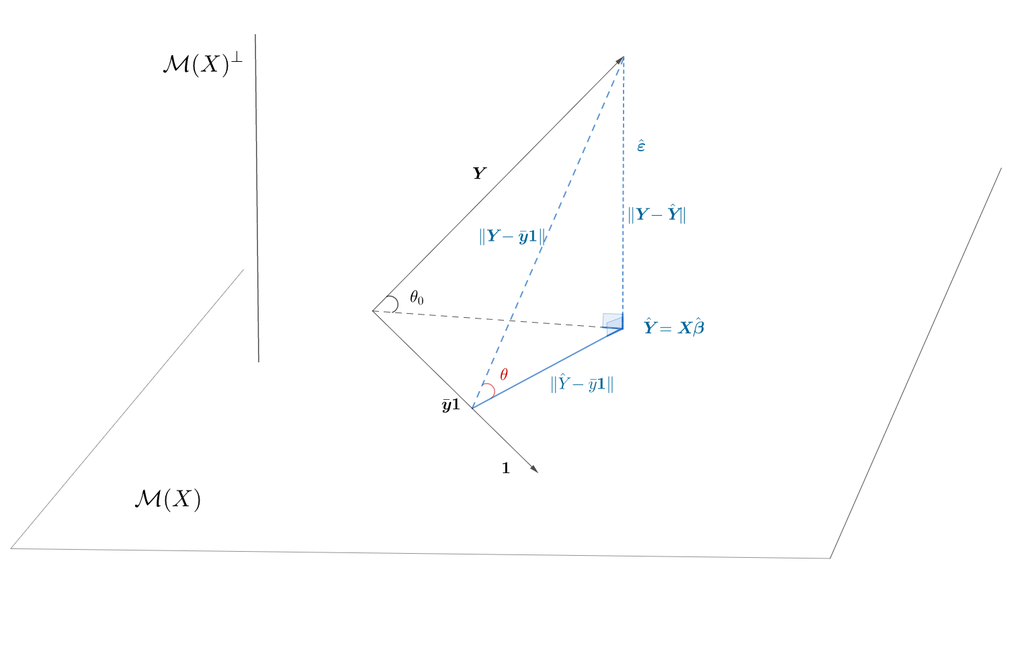

Dacă modelul de regresie considerat nu include termenul liber ($\beta_0$) atunci, conform figurii de mai sus, observăm că putem aplica *Teorema lui Pitagora* direct (în triunghiul determinat de $\boldsymbol Y$, $\hat{\boldsymbol Y}$ și $\hat{\boldsymbol \varepsilon}$) și obținem că

$$\begin{aligned}
\lVert \boldsymbol Y\rVert^2 &= \lVert \hat{\boldsymbol Y}\rVert^2 + \lVert\hat{\boldsymbol\varepsilon}\rVert^2\\
&= \lVert \boldsymbol X \hat{\boldsymbol \beta}\rVert^2 + \lVert \boldsymbol Y - \boldsymbol X \hat{\boldsymbol \beta}\rVert^2\\
SS_T &= SS_{reg} + RSS.
\end{aligned}$$

Pe de altă parte, atunci când modelul include și termenul liber (cum este cazul în cele mai multe aplicații), atunci tot prin aplicarea *Teoremei lui Pitagora*, dar de această dată în triunghiul albastru, are loc următoarea descompunere (descompunerea ANOVA pentru regresie)

$$\begin{aligned}
\lVert \boldsymbol Y - \bar{\boldsymbol y}\mathbf{1}\rVert^2 &= \lVert \hat{\boldsymbol Y} - \bar{\boldsymbol y}\mathbf{1}\rVert^2 + \lVert\hat{\boldsymbol\varepsilon}\rVert^2\\
SS_T &= SS_{reg} + RSS\\
\end{aligned}$$

unde

- $SS_{T} = \lVert \boldsymbol Y - \bar{\boldsymbol y}\mathbf{1}\rVert^2$ se numește **suma abaterilor pătratice totale** (variația totală)
- $SS_{reg} = \lVert \hat{\boldsymbol Y} - \bar{\boldsymbol y}\mathbf{1}\rVert^2$ se numește **suma abaterilor pătratice de regresie** (variația explicată de model)
- $RSS = \lVert \boldsymbol Y - \hat{\boldsymbol Y}\rVert^2 = \lVert\hat{\boldsymbol\varepsilon}\rVert^2$ se numește **suma abaterilor pătratice reziduale** (variația reziduală)

astfel

$$\text{Variația totală} = \text{Variația explicată de regresie } + \text{ Variația reziduală}.$$

*Coeficientul de determinare* $R^2$ (în `R` are denumirea de $\texttt{Multiple R-Squared}$) este definit prin

$$R^2 = \cos^2(\theta_0) = \frac{\lVert \hat{\boldsymbol Y}\rVert^2}{\lVert \boldsymbol Y\rVert^2} = 1 - \frac{\lVert\hat{\boldsymbol\varepsilon}\rVert^2}{\lVert \boldsymbol Y\rVert^2} = 1 - \frac{RSS}{SS_T}$$

atunci când termenul liber nu este inclus în model și prin

$$R^2 = \cos^2(\theta) = \frac{\text{Variația explicată de model}}{\text{Variația totală}} = \frac{\lVert \hat{\boldsymbol Y} - \bar{\boldsymbol y}\mathbf{1}\rVert^2}{\lVert \boldsymbol Y - \bar{\boldsymbol y}\mathbf{1}\rVert^2} = 1 - \frac{\lVert\hat{\boldsymbol\varepsilon}\rVert^2}{\lVert \boldsymbol Y - \bar{\boldsymbol y}\mathbf{1}\rVert^2} = 1 - \frac{RSS}{SS_T}$$

atunci când termenul liber este inclus în model.

Din descompunerea ANOVA pentru regresie putem interpreta coeficientul de determinare (procentul din varianța totală explicat de model) astfel: cu cât este mai aproape $R^2$ de $1$ cu atât este mai mică suma abaterilor pătratice reziduale $\lVert\hat{\boldsymbol\varepsilon}\rVert^2 = \sum_{i=1}^{n}\hat{\varepsilon}_i^2$, prin urmare cu atât este mai bună potrivirea modelului pe date (fitul) - cazul extrem în care avem $R^2 = 1$ implică $\lVert\hat{\boldsymbol\varepsilon}\rVert^2 = 0$ ceea ce înseamnă că punctele se regăsesc în hiperplanul de regresie și avem potrivire perfectă; pe de altă parte, cu cât $R^2$ este mai aproape de $0$, cu atât potrivirea pe date este slabă (fitul nu este prea bun) - cazul limită $R^2 = 0$ implică faptul că predicția răspunsului $y_i$ este întotdeauna egală cu media $\bar{y}$ răspunsului și nu depinde de valorile covariabilelor, ceea ce atată că acestea nu au niciun impact asupra explicării modelului.

Trebuie să ținem cont că suntem în ipoteza în care modelul liniar considerat este adecvat datelor, în caz contrar (i.e. atunci când există relații neliniare între covariabile și răspuns), în care modelul nu este specificat corespunzător, putem avea un coeficient de determinare apropiat de $0$ și cu toate acestea covariabilele să aibă o mare putere explicativă asupra răspunsului. Prin urmare, folosirea coeficientului de determinare ca (singură) măsură de ajustare a modelului se poate dovedi înșelătoare.

În figura următoare avem diagramele de împrăștiere a patru modele simulate care întorc aproximativ același coeficient de determinare $R^2 \approx 0.76$. Dacă în figura din stânga sus avem un exemplu de situație normală, în figura din dreapta sus variația reziduală este mai scăzută decât cea din primul grafic dar atunci și variația lui $x$ este mai mică conducând la o valoare similară a lui $R^2$. Figura din stânga jos arată o corelație puternică între răspuns și variabila explicativă (un coeficient de corelație de $0.954$), cu excepția a două observații aberante (outlier) iar figura din dreapta jos prezintă un model specificat incorect, relația fiind una pătratică.

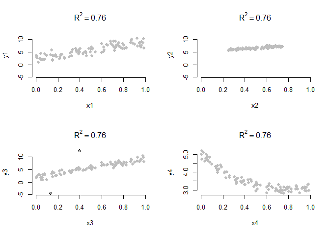

Este important de remarcat și că în modelul de regresie liniară multiplă, ca și în cazul modelului de regresie liniară simplă, putem interpreta coeficientul de determinare ca fiind pătratul coeficientului de corelație dintre răspuns $y_i$ și valorile ajustate $\hat{y}_i$: $R^2 = r_{\boldsymbol Y\hat{\boldsymbol Y}}^2$.

Atunci când vrem să comparăm diferite modele pe baza coeficientului de determinare, trebuie să avem grijă ca următoarele condiții să fie îndeplinite:

- fiecare model trebuie să aibă aceeași variabilă răspuns, nu putem compara modele în care primul area ca variabilă răspuns pe $y$ iar al doilea pe $h(y)$, $h$ o transformare
- fiecare model trebuie să aibă același număr de parametrii
- fiecare model trebuie să includă termenul liber

Astfel, în general, nu putem folosi coeficientul de determinare pentru compararea modelelor după cum se vede și în exemplul următor.

> *Exemplu: prețul chiriilor din Munchen - compararea modelelor după $R^2$*

După cum am văzut în exemplele și , putem explicita relația dintre prețul chiriei pe metrul pătrat al aparamentelor din Munchen în funcție de suprafața de locuit a acestora prin diferite modele de regresie liniară:

$$\begin{aligned}
M_1 &: pret{\_m^2}_i = \beta_0 + \beta_1 \times suprafata_i + \varepsilon_i,\\
M_2 &: pret{\_m^2}_i = \beta_0 + \beta_1 \times \frac{1}{suprafata_i} + \varepsilon_i, \\
M_3 &: pret{\_m^2}_i = \beta_0 + \beta_1 \times suprafata_i + \beta_2 \times suprafata_i^2 + \varepsilon_i\\
M_4 &: pret{\_m^2}_i = \beta_0 + \beta_1 \times suprafata_i + \beta_2 \times suprafata_i^2 + \beta_3 \times suprafata_i^3 + \varepsilon_i
\end{aligned}$$
Tabelul de mai jos include modelele estimate împreună cu coeficienții de determinare corespunzători:

[output not shown]

Se observă că pentru toate cele patru modele, coeficientul de determinare este relativ scăzut motivul principal fiind că, pe lângă variabilitatea mare a datelor, modelele nu includ o mare parte din covariabilele cu mare impact explicativ.

Dacă ne uităm la primele două modele, observăm că $M_2$ are un coeficient de determinare mai mare $R^2_{M_2} = 0.154 \geq R^2_{M_2} = 0.116$. Cum ambele modele conțin același număr de parametrii deducem că acest model este de preferat între cele două. Dacă ne uităm la modelele $M_1$, $M_3$ și $M_4$ constatăm că acestea sunt *modele imbricate* (nested models) ceea ce înseamnă că modelul $M_4$ include atât modelul $M_3$ ($\beta_3 = 0$) cât și pe $M_1$ ($\beta_3 = \beta_2 = 0$) iar modelul $M_3$ îl conține pe $M_1$ ca și caz particular ($\beta_2 = 0$). După cum vom vedea în Propoziția , asta implică faptul că $M_1$ are cel mai mic coeficient de determinare între cele trei modele, $M_3$ are al doilea cel mai mic $R^2$ iar $M_4$ are cel mai mare $R^2$. O comparație între cele trei modele, în funcție de $R^2$, în acest caz nu este recomandată deoarece modelele au un număr diferit de parametrii. Este de asemenea important de remarcat faptul că un model cu un număr mai mare de parametrii nu implică neapărat că are și un coeficient de determinare mai mare față de un model cu un număr mai mic de parametrii. Acest fenomen se observă atunci când comparăm $M_2$ cu $M_3$, $R^2_{M_2} = 0.154 \geq R^2_{M_3} = 0.143$. În acest caz, modelul $M_2$ este de preferat modelului $M_3$ deoarece conține un număr mai mic de parametrii și are un coeficient $R^2$ mai mare. $\square$

Cum coeficientul de determinare $R^2 = 1 - \frac{RSS}{SS_{T}} = 1 - \frac{\hat{\sigma}}{SS_{T}}[n-(p+1)]$ observăm că acesta crește odată cu numărul de variabile explicative $p$. În cele ce urmează vom defini o variantă a coeficientului de determinare care să amelioreze această problemă. Cum $R^2$ nu ține cont de dimensiunea spațiului $\mathcal{M}(X)$ se definește *coeficientul de determinare ajustat* $R_a^2$ (în `R` are denumirea de $\texttt{Adjusted R-Squared}$) prin

*Coeficientul de determinare ajustat* $R_a^2$ este definit prin

$$R_a^2 = 1 - \frac{\frac{\lVert\hat{\boldsymbol\varepsilon}\rVert^2}{n-(p+1)}}{\frac{\lVert \boldsymbol Y \rVert^2}{n}} = 1 - \frac{n}{n-(p+1)}\frac{\lVert\hat{\boldsymbol\varepsilon}\rVert^2}{\lVert \boldsymbol Y \rVert^2} = 1 - \frac{n}{n-(p+1)}(1 - R^2)$$

atunci când termenul liber nu este inclus în model și respectiv prin

$$R_a^2 = 1 - \frac{\frac{\lVert\hat{\boldsymbol\varepsilon}\rVert^2}{n-(p+1)}}{\frac{\lVert \boldsymbol Y - \bar{\boldsymbol y}\mathbf{1}\rVert^2}{n-1}} = 1 - \frac{n-1}{n-(p+1)}\frac{\lVert\hat{\boldsymbol\varepsilon}\rVert^2}{\lVert \boldsymbol Y - \bar{\boldsymbol y}\mathbf{1}\rVert^2} = 1 - \frac{n-1}{n-(p+1)}(1 - R^2).$$

atunci când termenul liber este inclus în model.

Ajustarea corespunde la împărțirea normelor la pătrat cu dimensiunea subspațiului din care fac parte vectorii. Notăm de asemenea că $R^2_a$ nu mai măsoară proporția variabilității lui $y$ explicate de modelul de regresie și în plus $R^2_a\leq 1$ și poate lua chiar și valori negative.

> *Exemplu: compararea coeficienților de determinare $R^2$ și $R^2_{a}$*

Pentru a vedea diferența dintre cei doi coeficienți de determinare considerăm următorul studiu de simulare în care presupunem că generăm observațiile $x_{i1}, x_{i2}, x_{i3}, y_i$ pentru $i = 1,2,\ldots,n =100$ conform modelului de regresie liniară

$$y_i = \beta_0 + \beta_1 x_{i1} + \beta_2 x_{i2} + \beta_3 x_{i3} + \varepsilon_i,$$

$$y = \beta_0 + \beta_1 x_{1} + \beta_2 x_{2} + \cdots + \beta_j x_{j} + \varepsilon,$$

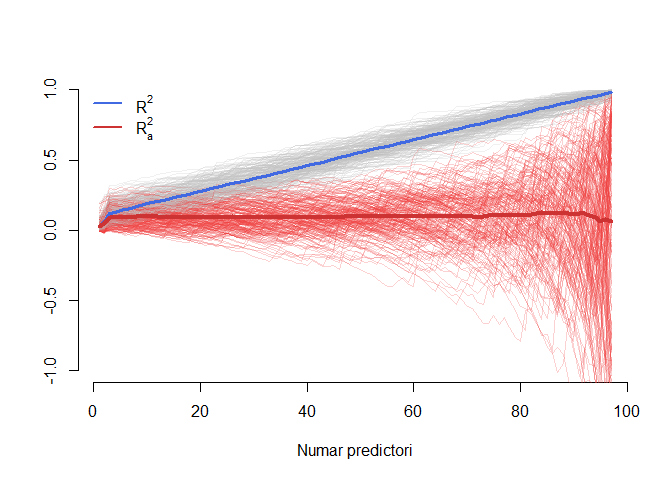

Următorul exercițiu este o aplicație numerică de calcul a coeficienților de determinare în contextul unui model de regresie cu două covariabile.

Ne propunem să determinăm evoluția unei variabile răspuns $y_i$ în funcție de două variabile explicative $x_i$ și $z_i$. Fie $\boldsymbol X = (\mathbf{1}, \boldsymbol x, \boldsymbol z)$ matricea de design.

1. Am obținut rezultatele următoare

$$\boldsymbol X^\intercal\boldsymbol X = \begin{pmatrix}25 & 0 & 0\\
? & 9.3 & 5.4\\
? & ? & 12.7\end{pmatrix}$$

1. Determinați valorile care lipsesc (?).
2. Cât este $n$ ?
3. Calculați coeficientul de corelație dintre $\boldsymbol x$ și $\boldsymbol z$.
2. Modelul de regresie liniară a lui $\boldsymbol Y$ în funcție de $\mathbf{1}, \boldsymbol x, \boldsymbol z$ este

$$\boldsymbol Y = -1.6\boldsymbol 1 + 0.61 \boldsymbol x + 0.46 \boldsymbol z + \hat{\boldsymbol \varepsilon}, \quad \lVert\hat{\boldsymbol \varepsilon}\rVert^2 = 0.3$$

1. Determinați $\bar{\boldsymbol y}$.
2. Calculați suma abaterilor pătratice de regresie $SS_{reg}$, suma abaterilor pătratice totale $SS_T$, coeficientul de determinare și coeficientul de determinare ajustat.
1. 1. Pentru a determina cele trei valori care lipsesc să notăm că matricea $\boldsymbol X^\intercal\boldsymbol X$ este simetrică, prin urmare $\boldsymbol X^\intercal\boldsymbol X = \left(\boldsymbol X^\intercal\boldsymbol X\right)^\intercal$ de unde

$$\begin{pmatrix}25 & 0 & 0\\
? & 9.3 & 5.4\\
? & ? & 12.7\end{pmatrix} = \begin{pmatrix}25 & ? & ?\\
0 & 9.3 & ?\\
0 & 5.4 & 12.7\end{pmatrix}$$

ceea ce conduce la valorile $0, 0, 5.4$.

2. Pentru a determina valoarea lui $n$ să observăm că

$$\boldsymbol X^\intercal\boldsymbol X = \begin{pmatrix}\mathbf{1}^\intercal \\
\boldsymbol x^\intercal\\
\boldsymbol z^\intercal\end{pmatrix}\begin{pmatrix}\mathbf{1} &
\boldsymbol x &
\boldsymbol z\end{pmatrix} = \begin{pmatrix}\mathbf{1}^\intercal \mathbf{1} & \mathbf{1}^\intercal\boldsymbol x & \mathbf{1}^\intercal\boldsymbol z \\
\boldsymbol x^\intercal\mathbf{1} & \boldsymbol x^\intercal\boldsymbol x & \boldsymbol x^\intercal\boldsymbol z\\
\boldsymbol z^\intercal\mathbf{1} & \boldsymbol z^\intercal\boldsymbol x & \boldsymbol z^\intercal\boldsymbol z\end{pmatrix} = \begin{pmatrix}n & n\bar x & n\bar z \\
n\bar x & \boldsymbol x^\intercal\boldsymbol x & \boldsymbol x^\intercal\boldsymbol z\\
n\bar z & \boldsymbol z^\intercal\boldsymbol x & \boldsymbol z^\intercal\boldsymbol z\end{pmatrix}$$

ceea ce arată că $n = \left(\boldsymbol X^\intercal\boldsymbol X\right)_{1,1} = 25$.

3. Coeficientul de corelație dintre $\boldsymbol x$ și $\boldsymbol z$ este dat de

$$r_{\boldsymbol x,\boldsymbol z} = \frac{\sum_{i=1}^{n}(x_i - \bar x)(z_i - \bar z)}{\sqrt{\sum_{i = 1}^{n}(x_i - \bar x)^2}\sqrt{\sum_{i = 1}^{n}(z_i - \bar z)^2}}$$

și cum, din punctul anterior, $\bar x = \frac{\left(\boldsymbol X^\intercal\boldsymbol X\right)_{1,2}}{n} = 0$ și $\bar z = \frac{\left(\boldsymbol X^\intercal\boldsymbol X\right)_{1,3}}{n} = 0$ deci

$$r_{\boldsymbol x,\boldsymbol z} = \frac{\sum_{i=1}^{n}x_iz_i}{\sqrt{\sum_{i = 1}^{n}x_i^2}\sqrt{\sum_{i = 1}^{n}z_i^2}} = \frac{\boldsymbol x^\intercal\boldsymbol z}{\sqrt{\boldsymbol x^\intercal\boldsymbol x}\sqrt{\boldsymbol z^\intercal\boldsymbol z}} = \frac{\left(\boldsymbol X^\intercal\boldsymbol X\right)_{2,3}}{\sqrt{\left(\boldsymbol X^\intercal\boldsymbol X\right)_{2,2}}\sqrt{\left(\boldsymbol X^\intercal\boldsymbol X\right)_{3,3}}} = \frac{5.4}{\sqrt{9.3}\sqrt{12.7}}\approx 0.5$$

2. 1. Avem modelul

$$y_i = -1.6 + 0.61 x_i + 0.46 z_i + \hat{\varepsilon}_i$$

care prin sumare devine

$$\bar y = -1.6 + 0.61 \bar x + 0.46 \bar z + \frac{1}{n}\sum_{i=1}^{n}\hat{\varepsilon}_i.$$

Cum $\mathbf{1}$ aparține modelului, deci $\mathbf{1}\in\mathcal{M}(\boldsymbol X)$ și ținând cont de faptul că $\hat{\boldsymbol \varepsilon}\in\mathcal{M}(X)^\perp$ deducem că $\langle\mathbf{1}, \hat{\boldsymbol \varepsilon}\rangle = 0$ sau $\frac{1}{n}\sum_{i=1}^{n}\hat{\varepsilon}_i = 0$. Astfel

$$\bar y = -1.6 + 0.61 \underbrace{\bar x}_{=0} + 0.46 \underbrace{\bar z}_{= 0} + \underbrace{\frac{1}{n}\sum_{i=1}^{n}\hat{\varepsilon}_i}_{=0} = -1.6.$$

2. Avem că suma abaterilor pătratice explicate de model este dată de

$$SS_{reg} = \lVert\hat{\boldsymbol Y} - \bar y\mathbf{1}\rVert^2 = \sum_{i=1}^{n}(\hat{y}_i - \bar y)^2 = \sum_{i=1}^{n}(0.61 x_i + 0.46 z_i)^2$$

adică

$$\begin{align*}
SS_{reg} &= \lVert\hat{\boldsymbol Y} - \bar y\mathbf{1}\rVert^2 = 0.61^2\sum_{i=1}^{n}x_i^2 + 2\times 0.61\times 0.46\sum_{i=1}^{n}x_iz_i + 0.46^2\sum_{i=1}^{n}z_i^2\\
&= 0.61^2\left(\boldsymbol X^\intercal\boldsymbol X\right)_{2,2} + 2\times 0.61\times 0.46\left(\boldsymbol X^\intercal\boldsymbol X\right)_{2,3} + 0.46^2\left(\boldsymbol X^\intercal\boldsymbol X\right)_{3,3} = 9.18.
\end{align*}$$

Suma abaterilor pătratice totale se determină folosind formula de descompunere a varianței:

$$\underbrace{SS_T}_{\lVert\boldsymbol Y - \bar y\mathbf{1}\rVert^2} = \underbrace{SS_{reg}}_{\lVert\hat{\boldsymbol Y} - \bar y\mathbf{1}\rVert^2} + \underbrace{RSS}_{\lVert\hat{\boldsymbol \varepsilon}\rVert^2} = 9.18 + 0.3 = 9.48.$$

Coeficientul de determinare $R^2$ este

$$R^2 = \frac{SS_{reg}}{SS_T} = \frac{9.18}{9.48}\approx 0.968$$

ceea ce arată că aproximativ $97\%$ din variabilitatea datelor este explicată de modelul de regresie iar coeficientul de determinare ajustat este

$$R_1^2 = 1 - \frac{n-1}{n-(p+1)}\frac{\lVert\hat{\boldsymbol\varepsilon}\rVert^2}{\lVert \boldsymbol Y - \bar{\boldsymbol y}\mathbf{1}\rVert^2} = 1 - \frac{n-1}{n-(p+1)}\left(1 - R^2\right) = 1 - \frac{25 - 1}{25 - (2 + 1)}(1-0.968)\approx 0.965$$

ceea ce verifică relația generală $R_a^2<R^2$. $\square$

Următorul rezultat justifică relația care există între coeficienții de determinare în cazul modelelor imbricate.

Fie $\boldsymbol Z\in\mathcal{M}_{n,q}(\mathbb{R})$ o matrice de rang $q$ și $\boldsymbol X\in\mathcal{M}_{n,p}(\mathbb{R})$ o matrice de rang $p$, $p>q$, compusă din cei $q$ vectori coloană ai lui $\boldsymbol Z$ și din alți $p-q$ vectori liniar independenți. Considerăm modelele următoare:

$$\begin{align*}
\boldsymbol Y &= \boldsymbol Z\boldsymbol \beta + \boldsymbol\varepsilon,\\
\boldsymbol Y &= \boldsymbol X\boldsymbol \gamma + \boldsymbol\eta
\end{align*}$$

Presupunem, pentru simplitate, că niciun model nu conține termenul liber (constanta). Notăm cu $P_X$ și $P_Z$ matricele de proiecție ortogonală pe subspațiile $\mathcal{M}(X)$ și respectiv $\mathcal{M}(Z)$, generate de coloanele lui $\boldsymbol X$ și $\boldsymbol Z$. De asemenea notăm cu $P_{X\cap Z^\perp}$ matricea de proiecție ortogonală pe $\mathcal{M}(X)\cap \mathcal{M}(Z)^\perp$, subspațiul ortogonal al lui $\mathcal{M}(Z)$ din $\mathcal{M}(X)$, astfel

$$\mathbb{R}^n = \mathcal{M}(X) \oplus \mathcal{M}(X)^\perp = \left(\mathcal{M}(Z) \oplus \left(\mathcal{M}(X)\cap \mathcal{M}(Z)^\perp\right) \right) \oplus \mathcal{M}(X)^\perp$$

Atunci:

1. Are loc relația $\lVert P_X\boldsymbol Y\rVert^2 = \lVert P_Z\boldsymbol Y\rVert^2 + \lVert P_{X\cap Z^\perp}\boldsymbol Y\rVert^2$.
2. Între coeficienții de determinare ai celor două modele există inegalitatea $R_X^2\geq R_Z^2$.

Această propoziție face referire la modele imbricate - *nested models*.

1. Deoarece $\mathcal{M}(\boldsymbol Z)\subset\mathcal{M}(\boldsymbol X)$ și aplicând *teorema celor trei perpendiculare*[^5] avem, vezi figura de mai jos,

$$\begin{align*}
\hat{\boldsymbol Y}_p &= P_X\boldsymbol Y = (\underbrace{P_Z + P_{Z^\perp}}_{I}) P_X\boldsymbol Y = P_Z P_X \boldsymbol Y + P_{Z^\perp}P_X\boldsymbol Y\\
&= P_X\boldsymbol Y + P_{X\cap Z^\perp} \boldsymbol Y = \hat{\boldsymbol Y}_q + P_{X\cap Z^\perp} \boldsymbol Y
\end{align*}$$

și din Teorema lui Pitagora (vezi triunghiul roșu) deducem că

$$\lVert P_X\boldsymbol Y\rVert^2 = \lVert P_Z\boldsymbol Y\rVert^2 + \lVert P_{X\cap Z^\perp}\boldsymbol Y\rVert^2.$$

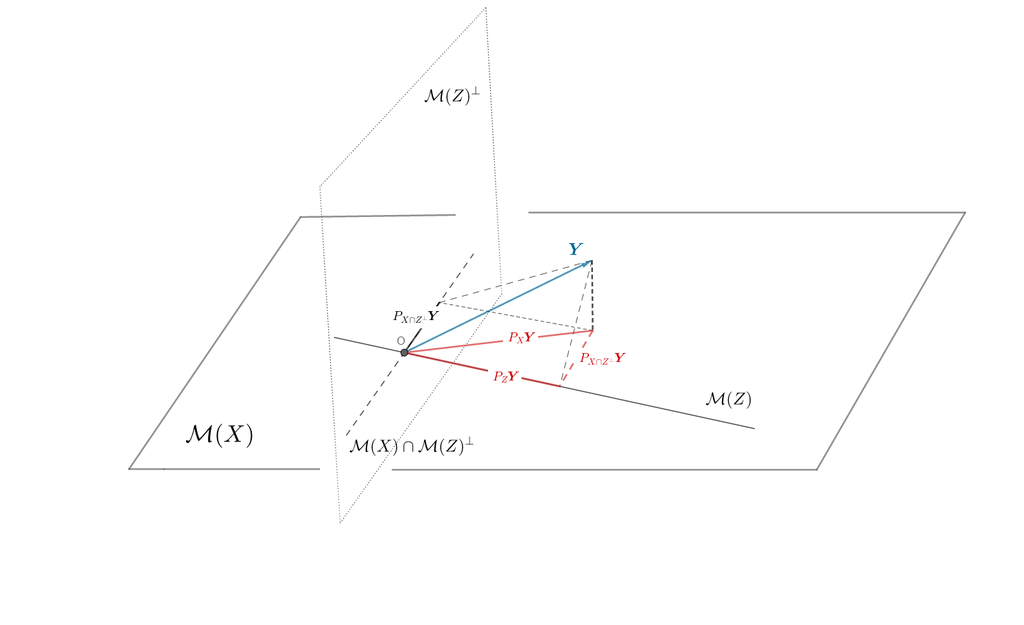

2. Dacă modelul nu are termenul liber (constanta) atunci coeficientul de determinare este definit prin $R_X^2 = \frac{\lVert P_{X}\boldsymbol Y\rVert^2}{\lVert\boldsymbol Y\rVert^2}$ prin urmare

$$R_X^2 = \frac{\lVert P_{X}\boldsymbol Y\rVert^2}{\lVert\boldsymbol Y\rVert^2} = \frac{\lVert P_Z\boldsymbol Y\rVert^2 + \lVert P_{X\cap Z^\perp}\boldsymbol Y\rVert^2}{\lVert\boldsymbol Y\rVert^2} = R_Z^2 + \frac{\lVert P_{X\cap Z^\perp}\boldsymbol Y\rVert^2}{\lVert\boldsymbol Y\rVert^2}\geq R_Z^2.\square$$

Rezultatul de mai sus se generalizează și în cazul modelelor imbricate care conțin termenul constant și ne arată că modelul mai mare are un coeficient de determinare superior modelului mai mic. Altfel spus, dacă la un model dat adăugăm una sau mai multe variabile explicative ameliorăm variabilitatea explicată de model, chiar dacă variabilele explicative suplimentare nu sunt pertinente! În acest caz este de preferat coeficientul de determinare ajustat.

## 4.6 Modelul (condiționat) normal

Considerăm modelul de regresie $\boldsymbol Y = \boldsymbol X\boldsymbol \beta + \boldsymbol \varepsilon$ în care $\boldsymbol Y\in\mathbb{R}^n$ este vectorul răspuns, $\boldsymbol X = \left[\mathbf{1}|\boldsymbol X_1|\cdots|\boldsymbol X_p\right]\in\mathcal{M}_{n, p+1}(\mathbb{R})$ este matricea de design, $\boldsymbol \beta\in\mathbb{R}^{p+1}$ este vectorul parametrilor și $\boldsymbol \varepsilon\in\mathbb{R}^n$ este vectorul termenilor eroare. Până acum, ipotezele modelului erau

$$\begin{array}{ll}
\mathcal{H}_1: \, rang(\boldsymbol X) = p+1\\
\mathcal{H}_2: \, \mathbb{E}[\boldsymbol \varepsilon] = 0,\, Var(\boldsymbol \varepsilon) = \sigma^2 I_n
\end{array}$$

și proprietățile estimatorilor rezultați din metoda celor mai mici pătrate au fost obținute fără a face apel la repartiția termenilor eroare.

În această secțiune ne propunem să studiem proprietățile statistice ale modelului de regresie liniară plasându-ne într-un context parametric și anume în contextul modelului gaussian:

$$\begin{array}{ll}
\mathcal{H}_1: \, rang(\boldsymbol X) = p+1\\
\mathcal{H}_2': \, \boldsymbol \varepsilon \sim\mathcal{N}(0, \sigma^2 I_n)
\end{array}$$

Observăm că ipoteza $\mathcal{H}_2'$ este un caz particular al ipotezei $\mathcal{H}_2$ și în plus implică faptul că reziduurile sunt independente și identic repartizate condiție care nu era necesară până acum. Ipoteza de normalitate a erorilor ne permite să scriem funcția de verosimilitate asociată modelului, să deducem repartițiile estimatorilor propuși, să construim intervale de încredere și să testăm ipoteze statistice asupra parametrilor modelului.

### 4.6.1 Estimatori de verosimilitate maximă

odată cu ipoteza suplimentară de normalitate a termenilor eroare, putem determina estimatorii de verosimilitate maximă. Rezultatul următor face legătura dintre estimatorii obținuți prin metoda celor mai mici pătrate din capitolul anterior și cei obținuți prin metoda verosimilității maxime.

Considerăm modelul de regresie liniară $\boldsymbol Y = \boldsymbol X\boldsymbol \beta + \boldsymbol\varepsilon$ sub ipotezele $\mathcal{H}_1$ și $\mathcal{H}_2'$ de mai sus. Atunci estimatorii de verosimilitate maximă pentru $\boldsymbol \beta$ și $\sigma^2$ sunt dați de

$$\hat{\boldsymbol\beta}_{VM} = (\boldsymbol{X}^\intercal \boldsymbol X)^{-1}\boldsymbol{X}^\intercal \boldsymbol Y, \quad \hat{\sigma}_{VM}^2 = \frac{\lVert\boldsymbol Y - \boldsymbol X\hat{\boldsymbol\beta}_{VM}\rVert^2}{n}=\frac{n - (p+1)}{n}\hat{\sigma}^2.$$

Începem prin a observa că din modelul de regresie

$$y_i = \boldsymbol x_i^\intercal\boldsymbol\beta + \varepsilon_i$$

și conform ipotezei $\mathcal{H}_2'$ avem $\varepsilon_i\sim\mathcal{N}(0, \sigma^2)$ prin urmare $y_i\sim\mathcal{N}(\boldsymbol x_i^\intercal\boldsymbol\beta, \sigma^2)$ și în plus $y_i$ sunt variabile aleatoare independete deoarece $\varepsilon_i$ sunt independente. Astfel funcția de verosimilitate se scrie

$$\begin{align*}
L(\boldsymbol\beta, \sigma^2;\boldsymbol Y) &= \prod_{i = 1}^{n}f_{Y}(y_i) = \left(\frac{1}{\sqrt{2\pi\sigma^2}}\right)^n e^{-\frac{1}{2\sigma^2}\sum_{i = 1}^{n}(y_i - \boldsymbol x_i^\intercal\boldsymbol\beta)^2} \\
&= \left(\frac{1}{\sqrt{2\pi\sigma^2}}\right)^n e^{-\frac{1}{2\sigma^2}\lVert\boldsymbol Y - \boldsymbol X\boldsymbol\beta\rVert^2}
\end{align*}$$

ceea ce conduce la logaritmul funcției de verosimilitate

$$\ell(\boldsymbol\beta, \sigma^2;\boldsymbol Y) = \log L(\boldsymbol\beta, \sigma^2;\boldsymbol Y) = -\frac{n}{2}\log{2\pi\sigma^2} -\frac{1}{2\sigma^2}\lVert\boldsymbol Y - \boldsymbol X\boldsymbol\beta\rVert^2.$$

Vrem să determinăm

$$(\hat{\boldsymbol\beta}_{VM}, \hat{\sigma}_{VM}^2) = \underset{(\boldsymbol\beta, \sigma^2)\in\mathbb{R}^{p+1}\times(0,\infty)}{\arg\max} \ell(\boldsymbol\beta, \sigma^2;\boldsymbol Y)$$

și observăm că pentru $\sigma^2$ fixat, a maximiza funcția $\ell(\boldsymbol\beta, \sigma^2;\boldsymbol Y)$ revine la a determina valoarea lui $\boldsymbol\beta$ care minimizează $\lVert\boldsymbol Y - \boldsymbol X\boldsymbol\beta\rVert^2$, aceasta ne fiind alta decât $\hat{\boldsymbol\beta}$ obținut prin metoda celor mai mici pătrate. Astfel găsim că

$$\hat{\boldsymbol\beta}_{VM} = \hat{\boldsymbol\beta} = (\boldsymbol{X}^\intercal \boldsymbol X)^{-1}\boldsymbol{X}^\intercal \boldsymbol Y.$$

Pentru a determina $\hat{\sigma}_{VM}^2$ să observăm că problema revine la a determina soluția ecuației

$$\frac{\partial l(\hat{\boldsymbol\beta}_{VM}, \sigma^2;\boldsymbol Y)}{\partial \sigma^2} = -\frac{n}{2\sigma^2} + \frac{1}{2\sigma^4}\lVert\boldsymbol Y - \boldsymbol X\hat{\boldsymbol\beta}_{VM}\rVert^2 = 0$$

care este $\hat{\sigma}_{VM}^2 = \frac{\lVert\boldsymbol Y - \boldsymbol X\hat{\boldsymbol\beta}_{VM}\rVert^2}{n}=\frac{\lVert\boldsymbol Y - \boldsymbol X\hat{\boldsymbol\beta}\rVert^2}{n}$. Comparând acest rezultat cu cel obținut prin metoda celor mai mici pătrate observăm că

$$\hat{\sigma}_{VM}^2 = \frac{n - (p+1)}{n}\hat{\sigma}^2,$$

deci estimatorul de verosimilitate maximă $\hat{\sigma}_{VM}^2$ a lui $\sigma^2$ est un estimator deplasat. $\square$

Se poate arăta că estimatorii de verosimilitate maximă $\hat{\boldsymbol\beta}_{VM} = \hat{\boldsymbol\beta}$ și $\hat{\sigma}_{VM}^2 = \frac{n - (p+1)}{n}\hat{\sigma}^2$ și prin urmare și cei obținuți prin metoda celor mai mici pătrate sunt suficienți în sensul că niciun alt estimator nu poate să îmbunătățească estimarea lui $\boldsymbol\beta$ și $\sigma^2$ plecând de la eșantionul dat (Rencher and Schaalje 2008). Mai mult, dacă în ipotezele $\mathcal{H}_1$ și $\mathcal{H}_2$ estimatorul $\hat{\boldsymbol\beta}$ era de varianță minimală în clasa estimatorilor liniari nedeplasați (Teorema Gauss-Markov - Propoziția ) în ipoteza suplimentară de normalitate $\mathcal{H}_2'$ acest rezultat se extinde la clasa tuturor estimatorilor nedeplasați. În același mod și $\hat{\sigma}^2$ are varianță minimală în clasa tuturor estimatorilor nedeplasați pentru $\sigma^2$ (Rencher and Schaalje 2008).

În cele ce urmează vom considera estimatorul nedeplasat $\hat{\sigma}^2 = \frac{\lVert\boldsymbol Y - \boldsymbol X\hat{\boldsymbol\beta}\rVert^2}{n - (p+1)} = \frac{\sum_{i=1}^{n}\hat{\varepsilon}_i^2}{n - (p+1)}$ ca estimator al lui $\sigma^2$.

### 4.6.2 Repartițiile estimatorilor

Înainte de a investiga repartițiile estimatorilor $\hat{\boldsymbol\beta}$ și $\hat{\sigma}^2$ pentru modelul de regresie liniară multiplă sub ipoteza de normalitate, să reamintim câteva noțiuni legate de vectorii gaussieni (pentru mai multe detalii se poate consulta (Seber and Lee 2003, Capitolul 2) sau (Jacod and Protter 2003, Capitolul 16)).

Spunem că un vector $\boldsymbol Y = (Y_1,\ldots,Y_n)\in\mathbb{R}^n$ este un vector gaussian dacă toate combinațiile liniare $\sum_{i=1}^{n}a_iY_i$ sunt repartizate normal (posibil degenerat dacă toți coeficienții sunt nuli). Acest vector admite o medie $\boldsymbol\mu = \mathbb{E}[\boldsymbol Y]$ și o matrice de varianță-covarianță $\Sigma_{\boldsymbol Y} = \mathbb{E}[(\boldsymbol Y - \boldsymbol\mu)(\boldsymbol Y - \boldsymbol\mu)^\intercal]$ care caracterizează complet repartiția lui $\boldsymbol Y$. În acest caz notăm $\boldsymbol Y \sim\mathcal{N}(\boldsymbol\mu, \Sigma_{\boldsymbol Y})$. Un vector gaussian $\boldsymbol Y$ admite o densitate de repartiție $f_{\boldsymbol Y}$ pe $\mathbb{R}^n$ dacă și numai dacă matricea sa de varianță-covarianță $\Sigma_{\boldsymbol Y}$ este inversabilă și în acest caz

$$f_{\boldsymbol Y}(\boldsymbol y) = \frac{1}{(2\pi)^{\frac{n}{2}}\sqrt{\det{\Sigma_{\boldsymbol Y}}}} e^{-\frac{1}{2}(\boldsymbol y - \boldsymbol \mu)^\intercal \Sigma_{\boldsymbol Y}^{-1}(\boldsymbol y - \boldsymbol \mu)}$$

În cazul în care matricea $\Sigma_{\boldsymbol Y}$ nu este inversabilă înseamnă că $\boldsymbol Y$ ia valori într-un subspațiu de dimensiune $n_0<n$ unde este repartizat ca un vector gaussian de dimensiune $n_0$.

Figura de mai jos prezintă patru repartiții normale bivariate ($n=2$) $\boldsymbol Y \sim\mathcal{N}(\boldsymbol\mu, \Sigma_{\boldsymbol Y})$, cu $\boldsymbol\mu = (\mu_1, \mu_2)^\intercal$ iar $\Sigma_{\boldsymbol Y} = \begin{pmatrix}\sigma_{11} & \sigma_{12}\\ \sigma_{21} & \sigma_{22}\end{pmatrix}= \begin{pmatrix}\sigma_{1}^2 & \sigma_{12}\\ \sigma_{12} & \sigma_{2}^2\end{pmatrix}$, rotite cu unghiul $\alpha$. În acest caz densitatea de repartiție este

$$f_{\boldsymbol Y}(y_1,y_2) = \frac{1}{2\pi\sigma_1\sigma_2\sqrt{1-\rho^2}}e^{-\frac{1}{2(1-\rho^2)}\left[\left(\frac{y_1 - \mu_1}{\sigma_1}\right)^2 - 2\rho\left(\frac{y_1 - \mu_1}{\sigma_1}\right)\left(\frac{y_2 - \mu_2}{\sigma_2}\right) + \left(\frac{y_2 - \mu_2}{\sigma_2}\right)^2\right]}$$

unde $\rho = \frac{\sigma_{12}}{\sigma_1\sigma_2}$ este coeficientul de corelație.

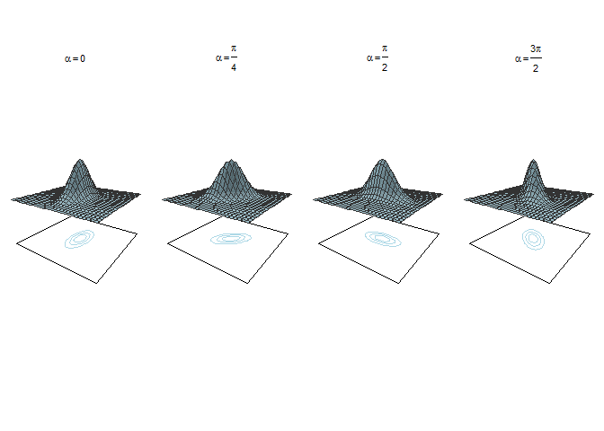

Una dintre proprietățile importante ale vectorilor gaussieni este stabilitatea prin transformări afine: dacă $\boldsymbol A\in\mathcal{M}_{m,n}(\mathbb{R})$ și $\boldsymbol b\in\mathcal{M}_{m,1}(\mathbb{R})$ sunt respectiv o matrice și un vector de scalari atunci

$$\boldsymbol Y \sim\mathcal{N}(\boldsymbol\mu, \Sigma_{\boldsymbol Y}) \Longrightarrow \boldsymbol A\boldsymbol Y + \boldsymbol b \sim\mathcal{N}(\boldsymbol A\boldsymbol\mu + \boldsymbol b, \boldsymbol A\Sigma_{\boldsymbol Y}\boldsymbol A^\intercal)$$

De asemenea, plecând de la funcția caracteristică, se poate verifica proprietatea de independență a componentelor unui vector gaussian care ne spune că acestea sunt independente dacă și numai dacă matricea de varianță-covarianță este o matrice diagonală (Jacod and Protter 2003).

Avem următorul rezultat care face legătura dintre repartiția normală și repartiția $\chi^2$:

Fie $\boldsymbol Y \sim\mathcal{N}(\boldsymbol\mu, \Sigma_{\boldsymbol Y})$ un vector gaussian în $\mathbb{R}^n$. Dacă $\Sigma_{\boldsymbol Y}$ este o matrice inversabilă atunci

$$(\boldsymbol Y - \boldsymbol \mu)^\intercal \Sigma_{\boldsymbol Y}^{-1}(\boldsymbol Y - \boldsymbol \mu) \sim \chi_n^2$$

repartiția $\chi^2$ cu $n$ grade de libertate.

Deoarece matricea de varianță-covarianță $\Sigma_{\boldsymbol Y}$ este o matrice simetrică și pozitiv definită atunci din [Teorema de descompunere spectrală](https://en.wikipedia.org/wiki/Eigendecomposition_of_a_matrix) ea se poate descompune sub forma $\Sigma_{\boldsymbol Y} = \boldsymbol Q\boldsymbol\Delta \boldsymbol Q^\intercal$ unde $\boldsymbol Q = [\boldsymbol v_1,\ldots,\boldsymbol v_n]$ este o matrice ortogonală ($\boldsymbol Q^\intercal = \boldsymbol Q^{-1}$) formată din vectorii proprii $\boldsymbol v_1,\ldots,\boldsymbol v_n$ corespunzători valorilor proprii $\lambda_1,\ldots,\lambda_n$, iar $\boldsymbol \Delta$ este matricea diagonală $\mathrm{diag}(\lambda_1,\ldots,\lambda_n)$. Dacă notăm cu $\boldsymbol \Delta^{-\frac{1}{2}}$ matricea diagonală de coeficienți diagonali $\frac{1}{\sqrt{\lambda_1}},\ldots,\frac{1}{\sqrt{\lambda_n}}$ (aceste fracții există deoarece pozitiv definirea matricei $\Sigma_{\boldsymbol Y}$ implică faptul că valorile proprii $\lambda_i>0$, $i = 1,\ldots,n$) atunci

$$\Sigma_{\boldsymbol Y} = \boldsymbol Q\boldsymbol\Delta \boldsymbol Q^\intercal \Longrightarrow \Sigma_{\boldsymbol Y}^{-1} = \boldsymbol Q\boldsymbol\Delta^{-1} \boldsymbol Q^\intercal = \left(\boldsymbol Q\boldsymbol\Delta^{-\frac{1}{2}} \boldsymbol Q^\intercal\right)\left(\boldsymbol Q\boldsymbol\Delta^{-\frac{1}{2}} \boldsymbol Q^\intercal\right) = \Sigma_{\boldsymbol Y}^{-\frac{1}{2}}\Sigma_{\boldsymbol Y}^{-\frac{1}{2}}.$$

Prin urmare găsim că

$$(\boldsymbol Y - \boldsymbol \mu)^\intercal \Sigma_{\boldsymbol Y}^{-1}(\boldsymbol Y - \boldsymbol \mu) = \left(\Sigma_{\boldsymbol Y}^{-\frac{1}{2}}(\boldsymbol Y - \boldsymbol \mu)\right)^\intercal\left(\Sigma_{\boldsymbol Y}^{-\frac{1}{2}}(\boldsymbol Y - \boldsymbol \mu)\right)$$

și cum vectorii gaussieni rămân gaussieni și prin aplicarea unor transformări afine (vezi rezultatul de mai sus) avem că

$$\boldsymbol Y \sim\mathcal{N}(\boldsymbol\mu, \Sigma_{\boldsymbol Y}) \Longrightarrow \Sigma_{\boldsymbol Y}^{-\frac{1}{2}}(\boldsymbol Y - \boldsymbol \mu) \sim\mathcal{N}(0, I_n).$$

Astfel vectorul $\boldsymbol V = [\boldsymbol V_1,\ldots,\boldsymbol V_n]^\intercal = \Sigma_{\boldsymbol Y}^{-\frac{1}{2}}(\boldsymbol Y - \boldsymbol \mu)$, care nu este altceva decât vectorul $\boldsymbol Y$ centrat și redus, este gaussian standard ($\boldsymbol V_j\sim\mathcal{N}(0,1)$ și $\boldsymbol V_i$ și $\boldsymbol V_j$ sunt independente) și

$$(\boldsymbol Y - \boldsymbol \mu)^\intercal \Sigma_{\boldsymbol Y}^{-1}(\boldsymbol Y - \boldsymbol \mu) = \lVert \boldsymbol V\rVert^2 = \boldsymbol V_1^2 + \cdots + \boldsymbol V_n^2\sim\chi^2_n. \square$$

Următorul rezultat, cunoscut sub denumirea de [Teorema lui Cochran](https://en.wikipedia.org/wiki/Cochran%27s_theorem) (a se vedea (Sen and Srivastava 2012) sau (Greene 2011) pentru o demonstrație a acestui rezultat), asigură că descompunerea unui vector gaussian în componente independente pe subspații ortogonale ne dă vectori independenți a căror repartiție o putem explicita. Această teoremă poate fi văzută și ca o generalizare a Teoremei lui Pitagora:

Fie $\boldsymbol Y \sim\mathcal{N}(\boldsymbol\mu, \sigma^2 I_n)$, $\mathcal{M}\subset\mathbb{R}^n$ un subspațiu de dimensiune $p$, $P$ matricea de proiecție ortogonală pe $\mathcal{M}$ și $P_\perp = I_n - P$ matricea de proiecție ortogonală pe $\mathcal{M}^\perp$. Au loc următoarele proprietăți:

1. $P\boldsymbol Y\sim\mathcal{N}(P\boldsymbol\mu, \sigma^2 P)$ și $P_\perp\boldsymbol Y\sim\mathcal{N}(P_\perp\boldsymbol\mu, \sigma^2 P_\perp)$
2. vectorii $P\boldsymbol Y$ și $P_\perp\boldsymbol Y = \boldsymbol Y - P\boldsymbol Y$ sunt independenți
3. $\frac{\lVert P(\boldsymbol Y - \boldsymbol\mu)\rVert^2}{\sigma^2}\sim\chi_p^2$ și $\frac{\lVert P_\perp(\boldsymbol Y - \boldsymbol\mu)\rVert^2}{\sigma^2}\sim\chi_{n-p}^2$.

Acum avem instrumentele necesare pentru a deduce repartițiile estimatorilor în modelul gaussian de regresie liniară.

Considerăm modelul de regresie liniară $\boldsymbol Y = \boldsymbol X\boldsymbol \beta + \boldsymbol \varepsilon$, sub ipotezele $\mathcal{H}_1$ și $\mathcal{H}_2'$. Dacă presupunem că varianța $\sigma^2$ este cunoscută atunci au loc proprietățile

1. Vectorul $\hat{\boldsymbol \beta}$ este un vector gaussian de medie $\boldsymbol \beta$ și matrice de varianță-covarianță $\sigma^2(\boldsymbol X^\intercal\boldsymbol X)^{-1}$, i.e. $\hat{\boldsymbol \beta}\sim\mathcal{N}(\boldsymbol \beta, \sigma^2(\boldsymbol X^\intercal\boldsymbol X)^{-1})$
2. $\hat{\boldsymbol \beta}$ și $\hat{\sigma}^2$ sunt independenți
3. $[n-(p+1)]\frac{\hat{\sigma}^2}{\sigma^2}\sim\chi^2_{n-(p+1)}$
1. Pentru a arăta că vectorul $\hat{\boldsymbol \beta}$ este un vector gaussian vom folosi expresia acestuia obținută prin metoda celor mai mici pătrate

$$\hat{\boldsymbol \beta} = (\boldsymbol X^\intercal\boldsymbol X)^{-1}\boldsymbol X^\intercal\boldsymbol Y = (\boldsymbol X^\intercal\boldsymbol X)^{-1}\boldsymbol X^\intercal(\boldsymbol X\boldsymbol \beta + \boldsymbol \varepsilon) = \boldsymbol \beta + (\boldsymbol X^\intercal\boldsymbol X)^{-1}\boldsymbol X^\intercal \boldsymbol \varepsilon.$$

Conform ipotezei $\mathcal{H}_2'$, $\boldsymbol \varepsilon\sim\mathcal{N}(0,\sigma^2 I_n)$ este un vector gaussian prin urmare și $\hat{\boldsymbol \beta} = \boldsymbol \beta + \underbrace{(\boldsymbol X^\intercal\boldsymbol X)^{-1}\boldsymbol X^\intercal}_{\boldsymbol A} \boldsymbol \varepsilon$ este tot un vector gaussian repartizat

$$\hat{\boldsymbol \beta} = \boldsymbol \beta + \underbrace{(\boldsymbol X^\intercal\boldsymbol X)^{-1}\boldsymbol X^\intercal}_{\boldsymbol A} \boldsymbol \varepsilon = \boldsymbol \beta + \boldsymbol A\boldsymbol \varepsilon \sim \mathcal{N}\left(\boldsymbol \beta, \boldsymbol A \sigma^2 I_n\boldsymbol A^\intercal\right) = \mathcal{N}\left(\boldsymbol \beta, \sigma^2(\boldsymbol X^\intercal\boldsymbol X)^{-1}\right)$$
deoarece $\boldsymbol A \sigma^2 I_n\boldsymbol A^\intercal = (\boldsymbol X^\intercal\boldsymbol X)^{-1}\boldsymbol X^\intercal \sigma^2 I_n \boldsymbol X(\boldsymbol X^\intercal\boldsymbol X)^{-1} = \sigma^2(\boldsymbol X^\intercal\boldsymbol X)^{-1}$.

2. Fie $\mathcal{M}(X)$ subspațiul lui $\mathbb{R}^n$ generat de coloanele matricei $\boldsymbol X$ și fie $P_{X} = \boldsymbol X(\boldsymbol X^\intercal\boldsymbol X)^{-1}\boldsymbol X^\intercal$ matricea de proiecție ortogonală pe $\mathcal{M}(X)$. Avem

$$\hat{\boldsymbol \beta} = (\boldsymbol X^\intercal\boldsymbol X)^{-1}\boldsymbol X^\intercal\boldsymbol Y = (\boldsymbol X^\intercal\boldsymbol X)^{-1}\boldsymbol X^\intercal\left(\underbrace{\boldsymbol X(\boldsymbol X^\intercal\boldsymbol X)^{-1}\boldsymbol X^\intercal}_{=P_X}\right)\boldsymbol Y = (\boldsymbol X^\intercal\boldsymbol X)^{-1}\boldsymbol X^\intercal P_X\boldsymbol Y$$

prin urmare $\hat{\boldsymbol \beta}$ este un vector aleator ce depinde de $P_X\boldsymbol Y$. Observăm de asemenea că din definiția lui $\hat{\sigma}^2$,

$$\hat{\sigma}^2 = \frac{\lVert\hat{\boldsymbol\varepsilon}\rVert^2}{n - (p+1)} = \frac{\lVert \boldsymbol Y - P_X\boldsymbol Y\rVert^2}{n - (p+1)}$$
acesta este o funcție de $\boldsymbol Y - P_X\boldsymbol Y$. Aplicând Teorema lui Cochran (Propoziția de mai sus) observăm că vectorii $P_X\boldsymbol Y$ și $\boldsymbol Y - P_X\boldsymbol Y$ sunt independenți prin urmare și $\hat{\boldsymbol \beta}$ și $\hat{\sigma}^2$ sunt independenți ca funcții de vectori independenți.

3. Notând cu $P_{X^\perp}$ proiecția ortogonală pe subspațiul ortogonal $\mathcal{M}(X)^\perp$, subspațiu de dimensiune $n-(p+1)$, avem

$$\hat{\boldsymbol\varepsilon} = \boldsymbol Y - P_X\boldsymbol Y = P_{X^\perp}\boldsymbol Y = P_{X^\perp}(\underbrace{\boldsymbol X\boldsymbol \beta}_{\in\mathcal{M}(X)} + \boldsymbol \varepsilon) = P_{X^\perp}\boldsymbol \varepsilon,$$

unde $\boldsymbol \varepsilon\sim\mathcal{N}(0,\sigma^2 I_n)$.

Din Teorema lui Cochran găsim că

$$(n-(p+1))\frac{\hat{\sigma}^2}{\sigma^2} = \frac{\lVert P_{X^\perp}\boldsymbol \varepsilon\rVert^2}{\sigma^2} = \frac{\lVert P_{X^\perp}\left(\boldsymbol \varepsilon - \mathbb{E}[\boldsymbol \varepsilon]\right)\rVert^2}{\sigma^2}\sim \chi^2_{n - (p+1)}. \square$$
Putem observa că rezultatul anterior nu este suficient pentru a determina o regiune de încredere pentru coeficienții modelului de regresie $\boldsymbol \beta$ deoarece varianța $\sigma^2$ a fost presupusă cunoscută, fenomen care nu este aplicabil în caz general. Rezultatul următor vine să acopere acest deficit.

Considerăm modelul de regresie liniară $\boldsymbol Y = \boldsymbol X\boldsymbol \beta + \boldsymbol \varepsilon$, sub ipotezele $\mathcal{H}_1$ și $\mathcal{H}_2'$ și presupunem că varianța $\sigma^2$ nu este cunoscută. Atunci au loc proprietățile

1. pentru $j\in\{0,1,\ldots, p\}$, notând cu $\left[(\boldsymbol X^\intercal\boldsymbol X)^{-1}\right]_{j+1,j+1}$ elementul $j+1$ de pe diagonala matricei $(\boldsymbol X^\intercal\boldsymbol X)^{-1}$, avem

$$\hat{\beta}_j\sim \mathcal{N}(\beta_j, \sigma^2\left[(\boldsymbol X^\intercal\boldsymbol X)^{-1}\right]_{j+1,j+1}), \quad T_j = \frac{\hat{\beta}_j - \beta_j}{\hat{\sigma}\sqrt{\left[(\boldsymbol X^\intercal\boldsymbol X)^{-1}\right]_{j+1,j+1}}} = \frac{\hat{\beta}_j - \beta_j}{\hat{\sigma}_{\hat{\beta}_j}}\sim t_{n-(p+1)}$$

2. fie $R\in\mathcal{M}_{q,p+1}(\mathbb{R})$ o matrice de rang $q$ ($q\leq p+1$) atunci

$$\frac{1}{q\hat{\sigma}^2}\left(R(\hat{\boldsymbol\beta} - \boldsymbol\beta)\right)^\intercal\left[R(\boldsymbol X^\intercal\boldsymbol X)^{-1}R^\intercal\right]^{-1}R(\hat{\boldsymbol\beta} - \boldsymbol\beta) \sim F_{q, n - (p+1)}$$

1. Din Propoziția am văzut că $\hat{\boldsymbol \beta}\sim\mathcal{N}(\boldsymbol \beta, \sigma^2(\boldsymbol X^\intercal\boldsymbol X)^{-1})$ prin urmare

$$\hat{\beta}_j\sim \mathcal{N}(\beta_j, \sigma^2\left[(\boldsymbol X^\intercal\boldsymbol X)^{-1}\right]_{j+1,j+1})$$

ceea ce implică $\frac{\hat{\beta}_j - \beta_j}{\sigma\sqrt{\left[(\boldsymbol X^\intercal\boldsymbol X)^{-1}\right]_{j+1,j+1}}}\sim\mathcal{N}(0,1)$.

Scriind

$$T_j = \frac{\frac{\hat{\beta}_j - \beta_j}{\sigma\sqrt{\left[(\boldsymbol X^\intercal\boldsymbol X)^{-1}\right]_{j+1,j+1}}}}{\frac{\hat{\sigma}}{\sigma}} = \frac{\frac{\hat{\beta}_j - \beta_j}{\sigma\sqrt{\left[(\boldsymbol X^\intercal\boldsymbol X)^{-1}\right]_{j+1,j+1}}}}{\sqrt{\frac{(n - (p+1))\frac{\hat{\sigma}^2}{\sigma^2}}{n-(p+1)}}}$$

și ținând cont de faptul că $(n-(p+1))\frac{\hat{\sigma}^2}{\sigma^2}\sim\chi^2_{n-(p+1)}$ iar $\hat{\beta}_j$ și $\hat{\sigma}^2$ sunt independente, deducem că $T_j \sim t_{n-(p+1)}$.

2. Să remarcăm că matricea $R(\boldsymbol X^\intercal\boldsymbol X)^{-1}R^\intercal$ pătratică de ordin $q$ este inversabilă deoarece matricea $(\boldsymbol X^\intercal\boldsymbol X)^{-1}$ este de rang $p+1$, $p+1\geq q$. Cum $\hat{\boldsymbol \beta}$ este un vector gaussian deducem că și $R\hat{\boldsymbol \beta}$ este un vector gaussian de medie și matrice de covarianță

$$R\hat{\boldsymbol \beta}\sim\mathcal{N}\left(R\boldsymbol \beta, \sigma^2 R(\boldsymbol X^\intercal\boldsymbol X)^{-1} R^\intercal\right)$$

Astfel, conform Propoziției privind legătura dintre repartiția normală și repartiția $\chi^2$, rezultă că

$$\frac{1}{\sigma^2}\left(R(\hat{\boldsymbol\beta} - \boldsymbol\beta)\right)^\intercal\left[R(\boldsymbol X^\intercal\boldsymbol X)^{-1}R^\intercal\right]^{-1}R(\hat{\boldsymbol\beta} - \boldsymbol\beta)\sim \chi^2_q.$$

În expresia de mai sus, înlocuim pe $\sigma^2$ cu $\hat{\sigma}^2$ și ținând cont că $\hat{\boldsymbol\beta}$ și $\hat{\sigma}^2$ sunt independente iar $(n-(p+1))\frac{\hat{\sigma}^2}{\sigma^2}\sim\chi^2_{n-(p+1)}$ concluzionăm că

$$\frac{1}{q\hat{\sigma}^2}\left(R(\hat{\boldsymbol\beta} - \boldsymbol\beta)\right)^\intercal\left[R(\boldsymbol X^\intercal\boldsymbol X)^{-1}R^\intercal\right]^{-1}R(\hat{\boldsymbol\beta} - \boldsymbol\beta) = \frac{\frac{\frac{1}{\sigma^2}\left(R(\hat{\boldsymbol\beta} - \boldsymbol\beta)\right)^\intercal\left[R(\boldsymbol X^\intercal\boldsymbol X)^{-1}R^\intercal\right]^{-1}R(\hat{\boldsymbol\beta} - \boldsymbol\beta)}{q}}{\frac{(n-(p+1))\frac{\hat{\sigma}^2}{\sigma^2}}{n-(p+1)}} \sim\frac{\frac{\chi^2_q}{q}}{\frac{\chi^2_{n - (p+1)}}{n-(p+1)}} = F_{q, n - (p+1)}.\square$$

> *Exemplu: aplicație pentru regresia liniară simplă*

Vom exemplifica rezultatul celui de-al doilea subpunct al Propoziției pentru cazul particular în care $p+1=q=2$ iar matricea $R=I_2$. Avem că

$$R(\hat{\boldsymbol\beta} - \boldsymbol\beta) = \begin{pmatrix}\hat{\beta}_0 - \beta_0\\ \hat{\beta}_1 - \beta_1\end{pmatrix}$$

și dacă termenul liber face parte din modelul de regresie atunci matricea $\boldsymbol X^\intercal\boldsymbol X$ devine (a se vedea și Exemplul )

$$\boldsymbol X^\intercal\boldsymbol X = \begin{pmatrix}n & \sum x_i\\ \sum x_i & \sum x_i^2\end{pmatrix}.$$

Astfel găsim că $\frac{1}{q\hat{\sigma}^2}\left(R(\hat{\boldsymbol\beta} - \boldsymbol\beta)\right)^\intercal\left[R(\boldsymbol X^\intercal\boldsymbol X)^{-1}R^\intercal\right]^{-1}R(\hat{\boldsymbol\beta} - \boldsymbol\beta)$ se rescrie ca

$$\frac{1}{2\hat{\sigma}^2}\left[n(\hat{\beta}_0 - \beta_0)^2 + 2n\bar{x}(\hat{\beta}_0 - \beta_0)(\hat{\beta}_1 - \beta_1) + \sum_{i=1}^{n}x_i^2(\hat{\beta}_1 - \beta_1)^2\right] \sim F_{2, n - 2}$$

proprietate care coincide cu rezultatul obținut în cazul regresiei liniare simple. Mai mult, dacă $p+1 = q$ și $R = I_{p+1}$ atunci repartiția distanței (ponderate de inversa matricei de covarianță) dintre estimatorul obținut prin metoda celor mai mici pătrate $\hat{\boldsymbol\beta}$ și valoarea reală $\boldsymbol \beta$ este $F_{p+1, n - (p+1)}$:

$$\frac{1}{\hat{\sigma}^2(p+1)}(\hat{\boldsymbol\beta} - \boldsymbol\beta)^\intercal(\boldsymbol X^\intercal\boldsymbol X)^{-1}(\hat{\boldsymbol\beta} - \boldsymbol\beta)\sim F_{p+1, n - (p+1)}.$$

### 4.6.3 Intervale și regiuni de încredere

Rezultatele din propozițiile anterioare conduc la următoarele intervale (atunci când parametrii sunt considerați separat) și regiuni de încredere (atunci când luăm în calcul mai mulți parametrii simultan prin urmare ținem cont și de dependența dintre ei) pentru parametrii modelului de regresie liniară:

1. Un interval de încredere bilateral de nivel de încredere $1-\alpha$ pentru parametrul $\beta_j$, $j\in\{0,1,\ldots,p\}$ este dat de

$$IC^{1-\alpha}(\beta_j) = \left[\hat{\beta}_j - t_{n-(p+1)}\left(1-\frac{\alpha}{2}\right)\hat{\sigma}\sqrt{\left[(\boldsymbol X^\intercal\boldsymbol X)^{-1}\right]_{j+1,j+1}}, \hat{\beta}_j + t_{n-(p+1)}\left(1-\frac{\alpha}{2}\right)\hat{\sigma}\sqrt{\left[(\boldsymbol X^\intercal\boldsymbol X)^{-1}\right]_{j+1,j+1}}\right]$$
unde $t_{n-(p+1)}\left(1-\frac{\alpha}{2}\right)$ este cuantila de ordin $1-\frac{\alpha}{2}$ a repartiției Student $t_{n-(p+1)}$.

2. Un interval de încredere bilateral de nivel de încredere $1-\alpha$ pentru $\sigma^2$ este dat de

$$IC^{1-\alpha}(\sigma^2) = \left[\frac{[n - (p+1)]\hat{\sigma}^2}{\chi^2_{n - (p+1)}\left(1-\frac{\alpha}{2}\right)}, \frac{[n - (p+1)]\hat{\sigma}^2}{\chi^2_{n - (p+1)}\left(\frac{\alpha}{2}\right)}\right]$$

unde $\chi^2_{n - (p+1)}\left(1-\frac{\alpha}{2}\right)$ și $\chi^2_{n - (p+1)}\left(\frac{\alpha}{2}\right)$ sunt cuantilele de ordin $1-\frac{\alpha}{2}$ și respectiv $\frac{\alpha}{2}$ a repartiției $\chi^2_{n - (p+1)}$.

3. O regiune de încredere de nivel de încredere $1-\alpha$ pentru $q$ ($q\leq p+1$) parametrii $\beta_j$, notați $(\beta_{j_1},\ldots,\beta_{j_q})$, este dată de
- atunci când $\sigma$ este cunoscută, de

$$RC^{1-\alpha}(R\boldsymbol \beta) = \left\{R\boldsymbol \beta\in\mathbb{R}^q\,|\, \frac{1}{\sigma^2}\left(R(\hat{\boldsymbol\beta} - \boldsymbol\beta)\right)^\intercal\left[R(\boldsymbol X^\intercal\boldsymbol X)^{-1}R^\intercal\right]^{-1}R(\hat{\boldsymbol\beta} - \boldsymbol\beta) \leq \chi^2_q(1-\alpha)\right\}$$

- atunci când $\sigma$ este necunoscută, de

$$RC^{1-\alpha}(R\boldsymbol \beta) = \left\{R\boldsymbol \beta\in\mathbb{R}^q\,|\, \frac{1}{q\hat{\sigma}^2}\left(R(\hat{\boldsymbol\beta} - \boldsymbol\beta)\right)^\intercal\left[R(\boldsymbol X^\intercal\boldsymbol X)^{-1}R^\intercal\right]^{-1}R(\hat{\boldsymbol\beta} - \boldsymbol\beta) \leq f_{q, n - (p+1)}(1-\alpha)\right\}$$

unde $R$ este o matrice de dimensiune $q\times(p+1)$ cu toate elementele nule exceptând elementele $R_{i,j_i}$ care sunt egale cu $1$ iar $f_{q, n - (p+1)}(1-\alpha)$ este cuantila de ordin $1-\alpha$ a repartiției Fisher-Snedecor $F_{q, n - (p+1)}$ cu $q$ grade de libertate la numărător și $n-(p+1)$ grade de libertate la numitor.

> *Exemplu: regiune de încredere caz particular*

Ca ilustrare a regiunii de încredere de mai sus, să presupunem că $p\geq 2$ și $q = 2$ iar matricea $R$ este

$$R = \begin{pmatrix}1 & 0 & 0 & \cdots & 0\\
0 & 1 & 0 & \cdots & 0\end{pmatrix}$$

ceea ce conduce la $R(\hat{\boldsymbol\beta} - \boldsymbol\beta) = \begin{pmatrix}\hat{\beta}_0 - \beta_0\\ \hat{\beta}_1 - \beta_1\end{pmatrix}$. Dacă presupunem că $\sigma^2$ este necunoscut atunci regiunea de încredere pentru $(\beta_0,\beta_1)$ este dată de

$$\small
RC^{1-\alpha}(\beta_0,\beta_1) = \left\{(\beta_0,\beta_1)\in\mathbb{R}^2\,|\, \frac{1}{2\hat{\sigma}^2}\begin{pmatrix}\hat{\beta}_0 - \beta_0 & \hat{\beta}_1 - \beta_1\end{pmatrix}\left[R(\boldsymbol X^\intercal\boldsymbol X)^{-1}R^\intercal\right]^{-1}\begin{pmatrix}\hat{\beta}_0 - \beta_0\\ \hat{\beta}_1 - \beta_1\end{pmatrix} \leq f_{2, n - (p+1)}(1-\alpha)\right\}
\normalsize$$

și notând cu $c_{ij}$ elementul de pe linia $i$ coloana $j$ a matricei $(\boldsymbol X^\intercal\boldsymbol X)^{-1}$, găsim că

$$RC^{1-\alpha}(\beta_0,\beta_1) = \left\{(\beta_0,\beta_1)\in\mathbb{R}^2\,|\,\frac{c_{22}(\hat{\beta}_0 - \beta_0)^2 - 2c_{12}(\hat{\beta}_0 - \beta_0)(\hat{\beta}_1 - \beta_1) + c_{11}(\hat{\beta}_1 - \beta_1)^2}{2\hat{\sigma}^2(c_{11}c_{22} - c_{12}^2)}\leq f_{2, n - (p+1)}(1-\alpha)\right\}$$

ceea ce arată că regiunea are formă de elipsă (vezi (Ornea and Turtoi 2000, Capitolul 2, Secțiunea 16)). Figura următoare ilustrează această regiune pentru date simulate conform modelului de regresie liniară simplă $y_i = 3 + 7x_i - \varepsilon_i$, cu $x_i\sim\mathcal{U}[-5, 5]$ iar $\varepsilon_i\sim\mathcal{N}(0, 4)$:

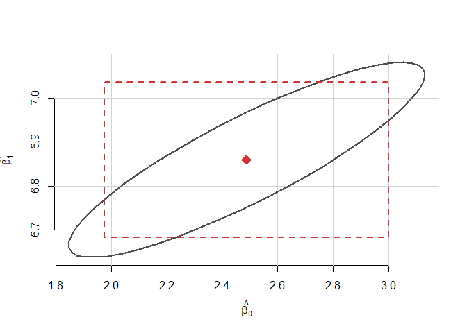

> *Exemplu: prețul chiriilor în Munchen*

În acest exemplu vom explicita relația dintre prețul chiriei pe metrul pătrat în raport cu inversul suprafeței de locuit și anul de construcție a imobilului folosid modelul de regresie prezentat în Exemplul în care am considerat variabila centrată $suprafata{\_}inv{\_}cen$ și variabilele ortogonale $an{\_}co{\_}j$

$$\widehat{pret{\_m^2}_i} = \beta_0 + \beta_1 \times suprafata{\_inv\_cen} + \beta_2\times an{\_co\_1} + \beta_3\times an{\_co\_2} +\beta_4\times an{\_co\_3}$$
Modelul estimat este

$$\widehat{pret{\_m^2}_i} = 7.111 + 129.572 \times suprafata{\_inv\_cen} + 43.938\times an{\_co\_1} + 27.539\times an{\_co\_2} -1.756\times an{\_co\_3}$$

Intervalele de încredere pentru coeficienții modelului de regresie la un nivel de încredere de $1-\alpha = 95\%$ sunt

$$\begin{aligned}
IC(\hat{\beta}_0)^{1-\alpha} &= \left[7.039, 7.183\right],\\
IC(\hat{\beta}_1)^{1-\alpha} &= \left[118.717, 140.426\right],\\
IC(\hat{\beta}_2)^{1-\alpha} &= \left[39.875, 48.002\right],\\
IC(\hat{\beta}_3)^{1-\alpha} &= \left[23.501, 31.577\right],\\
IC(\hat{\beta}_4)^{1-\alpha} &= \left[-5.756, 2.244\right],
\end{aligned}$$

iar intervalul de încredere pentru $\sigma^2$ la același nivel de încredere este

$$IC(\hat{\sigma}^2)^{1-\alpha} = \left[3.9591228, 4.3753046\right].$$
În figura de mai jos sunt prezentate regiunile de încredere pentru toate perechile de parametrii ai modelului împreună cu intervalele de încredere corespunzătoare (elipse versus dreptunghiuri):

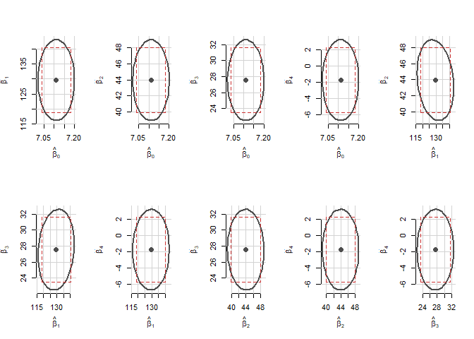

Atunci când vrem să facem o predicție dorim să evaluăm certitudinea cu care această predicție este efectuată. Având în vedere variabilitate noi valori pe care vrem să o prezicem este de așteptat ca intervalul de predicție să fie mai mare decât cel de încredere la același nivel de încredere.

Fie $(x_{n+1,1}, \ldots, x_{n+1,p})$ o nouă observație și considerăm $\boldsymbol x_{n+1}^\intercal = (1, x_{n+1,1}, \ldots, x_{n+1,p})$. Ne propunem să prezicem valoarea $y_{n+1}$ conform modelului

$$y_{n+1} = \boldsymbol x_{n+1}^\intercal\boldsymbol \beta + \varepsilon_{n+1}$$

cu $\varepsilon_{n+1}\sim\mathcal{N}(0,\sigma^2)$ independentă de $\varepsilon_i$, $1\leq i\leq n$.

Arătați că un interval de predicție de nivel de încredere $1-\alpha$ pentru $y_{n+1}$ este dat de

$$\scriptsize
\left[\boldsymbol x_{n+1}^\intercal \hat{\boldsymbol \beta} - t_{n-(p+1)}\left(1-\frac{\alpha}{2}\right)\hat{\sigma}\sqrt{1 + \boldsymbol x_{n+1}^\intercal(\boldsymbol X^\intercal\boldsymbol X)^{-1}\boldsymbol x_{n+1}}, \boldsymbol x_{n+1}^\intercal \hat{\boldsymbol \beta} + t_{n-(p+1)}\left(1-\frac{\alpha}{2}\right)\hat{\sigma}\sqrt{1 + \boldsymbol x_{n+1}^\intercal(\boldsymbol X^\intercal\boldsymbol X)^{-1}\boldsymbol x_{n+1}}\right]
\normalsize$$

Plecând de la un eșantion de talie $n$, $(\boldsymbol x_1, y_1), \ldots, (\boldsymbol x_n, y_n)$, găsim estimatorul de verosimilitate maximă (același cu cel obținut prin metoda celor mai mici pătrate) $\hat{\boldsymbol\beta}$ a lui $\boldsymbol\beta$ cu ajutorul căruia putem prezice valoarea $\hat{y}_{n+1}$ după relația

$$\hat{y}_{n+1} = \boldsymbol x_{n+1}^\intercal\hat{\boldsymbol \beta}.$$

Pentru a cuantifica eroarea de predicție $y_{n+1} - \hat{y}_{n+1}$ folosim următoarea descompunere

$$y_{n+1} - \hat{y}_{n+1} = \boldsymbol x_{n+1}^\intercal\left(\boldsymbol \beta - \hat{\boldsymbol \beta}\right) + \varepsilon_{n+1},$$

care este o sumă de două variabile gaussiene independente, $\varepsilon_{n+1}$ și $\hat{\boldsymbol \beta}$ care este un vector gaussian care depinde de $\varepsilon_i$, $1\leq i\leq n$. Prin urmare $y_{n+1} - \hat{y}_{n+1}$ este un vector gaussian și ținând cont că matricea de varianță-covarianță $Var(\hat{\varepsilon}_{n+1}) = \sigma^2\left(1 + \boldsymbol x_{n+1}^\intercal(\boldsymbol X^\intercal \boldsymbol X)^{-1}\boldsymbol x_{n+1}\right)$ avem

$$y_{n+1} - \hat{y}_{n+1} \sim \mathcal{N}\left(0, \sigma^2\left(1 + \boldsymbol x_{n+1}^\intercal(\boldsymbol X^\intercal \boldsymbol X)^{-1}\boldsymbol x_{n+1}\right)\right).$$
Această relație se rescrie sub forma

$$\frac{y_{n+1} - \hat{y}_{n+1}}{\sigma\sqrt{(1 + \boldsymbol x_{n+1}^\intercal(\boldsymbol X^\intercal \boldsymbol X)^{-1}\boldsymbol x_{n+1}}} \sim \mathcal{N}(0, 1)$$

și înlocuind $\sigma$ cu estimatorul său $\hat{\sigma}$ obținem

$$\frac{y_{n+1} - \hat{y}_{n+1}}{\hat{\sigma}\sqrt{(1 + \boldsymbol x_{n+1}^\intercal(\boldsymbol X^\intercal \boldsymbol X)^{-1}\boldsymbol x_{n+1}}} = \frac{\frac{y_{n+1} - \hat{y}_{n+1}}{\sigma\sqrt{(1 + \boldsymbol x_{n+1}^\intercal(\boldsymbol X^\intercal \boldsymbol X)^{-1}\boldsymbol x_{n+1}}}}{\frac{\sigma}{\hat{\sigma}}} = \frac{\frac{y_{n+1} - \hat{y}_{n+1}}{\sigma\sqrt{(1 + \boldsymbol x_{n+1}^\intercal(\boldsymbol X^\intercal \boldsymbol X)^{-1}\boldsymbol x_{n+1}}}}{\sqrt{\frac{\frac{[n - (p+1)]\sigma}{\hat{\sigma}}}{n - (p+1)}}} \sim \frac{\mathcal{N}(0,1)}{\sqrt{\frac{\chi^2_{n-(p+1)}}{n - (p+1)}}}.$$

Remarcăm că numărătorul și numitorul sunt variabile aleatoare independente deoarece $y_{n+1} - \hat{y}_{n+1} = \boldsymbol x_{n+1}^\intercal\left(\boldsymbol \beta - \hat{\boldsymbol \beta}\right) + \varepsilon_{n+1}$ este independentă de $\hat{\sigma}$ pentru că $\hat{\sigma}$ este independentă de $\hat{\boldsymbol \beta}$ și de $\varepsilon_{n+1}$ (estimatorul $\hat{\sigma}$ nu depinde decât de $\varepsilon_i$, $1\leq i\leq n$). Prin urmare găsim că

$$\frac{y_{n+1} - \hat{y}_{n+1}}{\hat{\sigma}\sqrt{(1 + \boldsymbol x_{n+1}^\intercal(\boldsymbol X^\intercal \boldsymbol X)^{-1}\boldsymbol x_{n+1}}} \sim t_{n-(p+1)}$$

de unde rezultă intervalul de încredere dorit. $\square$

### 4.6.4 Testare de ipoteze statistice

În această secțiune vom prezenta o serie de teste statistice de semnificație pentru coeficienții necunoscuți $\boldsymbol\beta$ ai modelului de regresie liniară. Pentru aceasta ne vom plasa în contextul modelului de regresie liniară multiplă sub ipoteza de normalitate a termenilor eroare $\mathcal{H}_2'$, chiar dacă mare parte din rezultatele ce vor fi prezentate sunt robuste la deviații mici de la această ipoteză în special atunci când talia eșantionului $n$ este mare (Sen and Srivastava 2012) sau (Rencher and Schaalje 2008).

Vom începe prin a da un exemplu în care se justifică necesitatea testării de ipoteze statistice în contextul modelului de regresie.

> *Exemplu: prețul chiriilor în Munchen - testare de ipoteze statistice*

Ne plasăm în contextul setului de date referitor la prețul chiriilor apartamentelor din orașul Munchen. În acest exemplu vom folosi atât datele din anul 1999 cât și pe cele din anul 2001 pentru a face o comparație între prețuri. Setul de date `Munchen2` conține $n = 4571$ observații referitoare la prețul chiriei apartamentelor pentru anii 1999 (3082 observații) și 2001 (1489 observații). Considerăm modelul de regresie

$$\begin{aligned}
pret{\_m^2}_i &= \beta_0 + \beta_1\times suprafata{\_inv}{\_cen}_i + \beta_2\times an{\_co\_1} + \beta_3\times an{\_co\_2} +\beta_4\times an{\_co\_3} \\
&\quad + \beta_5\times nbucatarie + \beta_6\times pbucatarie + \beta_7\times an01 + \varepsilon_i
\end{aligned}$$

unde $suprafata{\_inv}{\_cen}$ este covariabila dată de inversa suprafeței de locuit centrată în zero, $an{\_co\_j}$ sunt variabilele rezultate prin aplicarea polinoamelor ortogonale de grad 3 (a se vedea Exemplul ) anului de construcție, $nbucatarie$ și $pbucatarie$ sunt variabile indicator ajutătoare care specifică tipul de bucătărie al locuinței și sunt rezultate din variabila categorială `bucătărie` care avea nivelele *substandard* (categorie de referință), *standard/normală* și respectiv *premium*. Covariabila $an01$ este o variabilă indicator care precizează dacă observația este din anul 1999 ($an01 = 0$) sau 2001 ($an01 = 1$).

Modelul estimat rezultat este

$$\begin{aligned}
\widehat{pret{\_m^2}_i} &= 6.932 + 123.77\times suprafata{\_inv}{\_cen}_i + 49.373\times an{\_co\_1} + 29.5\times an{\_co\_2} \\
&\quad -0.884\times an{\_co\_3} + 1.043\times nbucatarie + 1.302\times pbucatarie -0.185\times an01
\end{aligned}$$

ceea ce arată că prețul mediu net pe metrul pătrat al chiriei pentru apartamentele din anul 2001 scade cu aproape $0.185$ euro față de cele din anul 1999. Se poate pune întrebarea dacă această descreștere este semnificativă (poate fi extrapolată la întreaga populație) sau este datorată variabilității eșantionării aleatoare, prin urmare vrem să verificăm dacă parametrul $\beta_7$ este diferit în mod semnificativ față de $0$ ceea ce în termeni de teste statistice se scrie sub forma:

$$H_0: \beta_7 = 0 \quad \text{versus}\quad H_1: \beta_7\neq 0.$$

Alte întrebări asupra acestui model pot să apară, de exemplu putem să verificăm dacă tipul de bucătărie este semnificativ în explicarea prețului chiriei pe metrul pătrat, adică dacă coeficienții $\beta_5$ și $\beta_6$ sunt simultan $0$:

$$H_0: \begin{pmatrix}\beta_5\\ \beta_6\end{pmatrix} = \begin{pmatrix}0\\0\end{pmatrix} \quad \text{versus}\quad H_1: \begin{pmatrix}\beta_5\\ \beta_6\end{pmatrix} \neq \begin{pmatrix}0\\0\end{pmatrix}.$$

O altă întrebare, ținând seama că estimatorii coeficienților $\hat{\beta}_5 = 1.043$ și $\hat{\beta}_6 = 1.302$ nu sunt foarte diferiți, ar fi dacă este necesar să diferențiem între apartamentele cu bucătărie standard și cele cu bucătărie premium:

$$H_0: \beta_5 = \beta_6 \quad \text{versus}\quad H_1: \beta_5\neq \beta_6. \square$$
Toate întrebările puse în Exemplul sunt ilustrative pentru modelul de regresie în general și testele statistice de semnificație corespunzătoare pot fi scrise sub forma:

1. *Teste asupra modelelor imbricate* - în acest caz avem un test compus asupra subvectorului $\boldsymbol\beta_0 = (\beta_0,\ldots,\beta_{p_0})^\intercal$

$$H_0: \boldsymbol\beta_0 = \boldsymbol 0 \quad \text{versus}\quad H_1: \boldsymbol\beta_0 \neq \boldsymbol 0.$$

2. *Test de semnificație asupra unui coeficient*

$$H_0: \beta_j = 0 \quad \text{versus}\quad H_1: \beta_j\neq 0.$$

3. *Testul global asupra tutoror covariabielor din model*

$$H_0: \beta_1 = \cdots = \beta_p = 0 \quad \text{versus}\quad H_1: \exists j\in\{1, 2,\ldots, p\} \text{ cu } \beta_j\neq 0.$$

4. *Testul asupra unei ipoteze liniare generalizate*

$$H_0: R\boldsymbol \beta = r \quad \text{versus}\quad H_1: R\boldsymbol \beta \neq r$$

unde $R$ este o matrice dimensiune $q\times(p+1)$ cu $rang(R) = q\leq p+1$ iar $r$ este un vector de dimensiune $q$.

În secțiunile următoare vom încerca să construim pentru fiecare astfel de test statistica de test precum și regiunea critică corespunzătoare.

#### 4.6.4.1 Teste asupra modelelor imbricate

Considerăm modelul de regresie liniară

$$\boldsymbol Y = \boldsymbol X\boldsymbol \beta + \boldsymbol \varepsilon$$

sub ipotezele $\mathcal{H}_1: \, rang(\boldsymbol X) = p+1$ și $\mathcal{H}_2': \, \boldsymbol \varepsilon \sim\mathcal{N}(0, \sigma^2 I_n)$. În particular, acest model ne spune că $\mathbb{E}[\boldsymbol Y] = \boldsymbol X\boldsymbol \beta\in\mathcal{M}(X)$ unde $\mathcal{M}(X)$ este subspațiul de dimensiune $p+1$ a lui $\mathbb{R}^n$ generat de coloanele matricei de design $\boldsymbol X$.

Pentru început, în această secțiune ne propunem să testăm dacă ultimii $q$ coeficienți, $q = p - p_0\leq p+1$, sunt nuli, altfel spus vrem să testăm ipotezele

$$H_0:\, \beta_{p_0+1} = \cdots = \beta_p = 0 \quad \text{versus}\quad H_1:\,\exists j\in\{p_0+1,\ldots,p\}\, \beta_j\neq 0$$

În termeni de model, ipoteza $H_0$ ne spune că modelul revine la

$$\boldsymbol Y = \boldsymbol X_0\boldsymbol \beta_0 + \boldsymbol \varepsilon_0$$

sub ipotezele $\mathcal{H}_1: \, rang(\boldsymbol X_0) = p_0+1$ și $\mathcal{H}_2': \, \boldsymbol \varepsilon_0 \sim\mathcal{N}(0, \sigma^2 I_n)$, unde matricea $\boldsymbol X_0\in\mathcal{M}_{n,p_0+1}(\mathbb{R})$ este compusă din primele $p_0+1$ coloane ale lui $\boldsymbol X$ iar $\boldsymbol \beta_0\in\mathcal{M}_{p_0+1,1}(\mathbb{R})$ (în acest model am inclus și termenul liber și acesta este motivul pentru care avem $p_0 + 1$ și nu $p_0$).

Fie $\mathcal{M}(X_0)$ subspațiul lui $\mathcal{M}(X)$ de dimensiune $p_0$ generat de coloanele lui $\boldsymbol X_0$ (deoarece $\mathrm{rang}(\boldsymbol X) = p+1$ deducem că $\mathrm{rang}(\boldsymbol X_0) = p_0+1$). Sub ipoteza $H_0$ avem că $\mathbb{E}[\boldsymbol Y] = \boldsymbol X_0\boldsymbol \beta_0\in\mathcal{M}(X_0)$.

Odată ce avem fixate ipotezele procedurii de testare, mai rămâne de a determina statistica de test corespunzătoare și regiunea critică a testului. Următoarea propoziție face lumină în acest sens folosind o abordare geometrică (pentru o versiune analită se poate consulta Propoziția ).

Sub ipoteza nulă $H_0$ statistica de test

$$F = \frac{n - (p+1)}{q}\frac{\lVert\hat{\boldsymbol Y} - \hat{\boldsymbol Y}_0\rVert^2}{\lVert\boldsymbol Y - \hat{\boldsymbol Y}\rVert^2} = \frac{n - (p+1)}{q}\frac{RSS_0 - RSS}{RSS} \sim F_{q, n - (p+1)}$$

unde $q = p - p_0$ iar $F_{q, n - (p+1)}$ este repartiția lui Fisher cu $(q, n - (p+1))$ grade de libertate.

Vom prezenta mai jos o abordare din punct de vedere geometric a problemei de testare. Considerăm spațiul $\mathcal{M}(X_0)\subset\mathcal{M}(X)$ și am văzut că sub ipoteza nulă avem $\mathbb{E}[\boldsymbol Y] = \boldsymbol X_0\boldsymbol \beta_0\in\mathcal{M}(X_0)$. În această situație, metoda celor mai mici pătrate consistă în proiectarea lui $\boldsymbol Y$ pe spațiul $\mathcal{M}(X_0)$ pentru a obține vectorul valorilor ajustate $\hat{\boldsymbol Y}_0$ (vezi figura de mai jos).

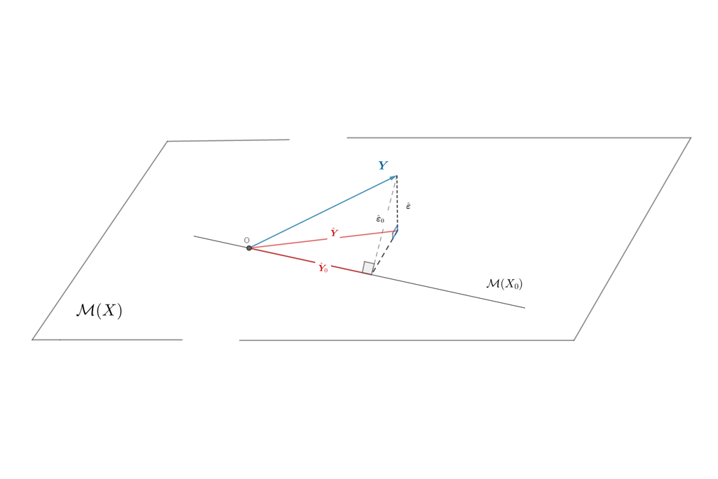

Ideea procedurii de testare, și prin urmare a deciziei de a respinge sau nu ipoteza nulă, este următoarea: dacă proiecția $\hat{\boldsymbol Y}_0$ a lui $\boldsymbol Y$ pe $\mathcal{M}(X_0)$ este *aproape* de proiecția $\hat{\boldsymbol Y}$ a lui $\boldsymbol Y$ pe $\mathcal{M}(X)$ atunci nu respingem ipoteza nulă, în caz contrar o respingem în favoarea alternativei $H_1$. De fapt, dacă informația adusă de cele două modele nu diferă foarte mult atunci este recomandat să păstrăm modelul mai simplu (principiul parcimoniei).

Pentru a cuantifica *apropierea* dintre cele două proiecții putem considera distanța euclidiană $\lVert\hat{\boldsymbol Y} - \hat{\boldsymbol Y}_0\rVert^2$ dintre acestea. Această distanță variază în funcție de datele și de unitățile de măsură a acestora și pentru a evita această problemă de scară se recomandă *standardizarea* acestei distanțe prin împărțirea ei la pătratul normei erorii reziduale $\lVert\hat{\boldsymbol \varepsilon}\rVert^2 = \lVert\boldsymbol Y - \hat{\boldsymbol Y}\rVert^2 = [n - (p+1)]\hat{\sigma}^2$. Cum vectorii aleatori $\hat{\boldsymbol Y} - \hat{\boldsymbol Y}_0$ și $\hat{\boldsymbol \varepsilon}$ nu aparțin în subspații de aceeași dimensiune trebuie să îi împărțim și prin gradele de libertate corespunzătoare, respectiv $q = p - p_0$ și $n - (p+1)$. Obținem astfel statistica de test

$$F = \frac{\frac{\lVert\hat{\boldsymbol Y} - \hat{\boldsymbol Y}_0\rVert^2}{p-p_0}}{\frac{\lVert\boldsymbol Y - \hat{\boldsymbol Y}\rVert^2}{n - (p+1)}} = \frac{n - (p+1)}{p - p_0}\frac{\lVert\hat{\boldsymbol Y} - \hat{\boldsymbol Y}_0\rVert^2}{\lVert\boldsymbol Y - \hat{\boldsymbol Y}\rVert^2}.$$

Pentru a putea utiliza această statistică de test este necesar să determinăm repartiția sa sub ipoteza nulă. Notând cu $P_X$ și respectiv $P_{X_0}$ matricele de proiecție ortogonală pe $\mathcal{M}(X)$ și $\mathcal{M}(X_0)$, știm că

$$\hat{\boldsymbol Y} - \hat{\boldsymbol Y}_0 = P_X\boldsymbol Y - P_{X_0}\boldsymbol Y$$

și cum $\mathcal{M}(X_0)\subset \mathcal{M}(X)$, deci $P_{X_0}\boldsymbol Y = P_{X_0}P_{X}\boldsymbol Y$ și

$$\hat{\boldsymbol Y} - \hat{\boldsymbol Y}_0 = P_{X}\boldsymbol Y - P_{X_0}\boldsymbol Y = (I_n - P_{X_0})P_X\boldsymbol Y = P_{X_0}^\perp P_{X}\boldsymbol Y.$$

Astfel am găsit că $\hat{\boldsymbol Y} - \hat{\boldsymbol Y}_0\in\mathcal{M}(X_0)^\perp\cap \mathcal{M}(X)$ și cum $\boldsymbol Y - \hat{\boldsymbol Y}\in\mathcal{M}(X)^\perp$ găsim că $\hat{\boldsymbol Y} - \hat{\boldsymbol Y}_0 \perp \boldsymbol Y - \hat{\boldsymbol Y}$. Vectorii $\hat{\boldsymbol Y} - \hat{\boldsymbol Y}_0$ și $\boldsymbol Y - \hat{\boldsymbol Y}$ sunt elemente din spații ortogonale ceea ce implică $Cov(\hat{\boldsymbol Y} - \hat{\boldsymbol Y}_0, \boldsymbol Y - \hat{\boldsymbol Y}) = 0$ și cum sunt și vectori gaussieni (conform ipotezei $\mathcal{H}_2'$) deducem că sunt și independenți ceea ce arată că numărătorul și numitorul lui $F$ sunt independente.

Conform Teoremei lui Cochran (a se vedea Propoziția ) avem pentru numitor

$$\frac{1}{\sigma^2}\lVert\boldsymbol Y - \hat{\boldsymbol Y}\rVert^2 = \frac{1}{\sigma^2}\lVert P_{X^\perp}\boldsymbol Y\rVert^2 = \frac{1}{\sigma^2}\lVert P_{X^\perp}(\boldsymbol X\boldsymbol\beta + \boldsymbol\varepsilon)\rVert^2 = \frac{1}{\sigma^2}\lVert P_{X^\perp}\boldsymbol\varepsilon\rVert^2\sim\chi^2_{n - (p+1)}$$

iar pentru numărător

$$\frac{1}{\sigma^2}\lVert P_{X_0}^\perp P_{X}(\boldsymbol Y - \boldsymbol X\boldsymbol\beta)\rVert^2 \sim \chi^2_{q}$$

Sub $H_0$, parametrul $\lVert P_{X_0}^\perp P_{X}\boldsymbol X\boldsymbol\beta\rVert^2$ este nul deoarece $\boldsymbol X\boldsymbol\beta\in\mathcal{M}(X_0)$ ceea ce conduce la

$$\frac{1}{\sigma^2}\lVert\hat{\boldsymbol Y} - \hat{\boldsymbol Y}_0\rVert^2 = \frac{1}{\sigma^2}\lVert P_{X_0}^\perp P_{X}\boldsymbol Y\rVert^2 \overset{H_0}{=} \frac{1}{\sigma^2}\lVert P_{X_0}^\perp P_{X}(\boldsymbol Y - \boldsymbol X\boldsymbol\beta)\rVert^2 \sim \chi^2_{q}$$

prin urmare

$$F\overset{H_0}{\sim} F_{q, n - (p+1)}.$$

Putem observa de asemenea că aplicând Teorema lui Pitagora (în triunghiul punctat cu negru)

$$\begin{align*}
\lVert\boldsymbol Y - \hat{\boldsymbol Y}_0\rVert^2 &= \lVert\boldsymbol Y - P_X\boldsymbol Y + P_X\boldsymbol Y - P_{X_0}\boldsymbol Y\rVert^2 = \lVert (I_n - P_X)\boldsymbol Y + P_{X_0}P_X\boldsymbol Y - P_{X_0}\boldsymbol Y\rVert^2 \\
&= \lVert P_{X^\perp}\boldsymbol Y + (I_n - P_{X_0})P_X\boldsymbol Y \rVert^2 = \lVert P_{X^\perp}\boldsymbol Y + P_{{X_0}^\perp}P_X\boldsymbol Y \rVert^2\\
&= \lVert P_{X^\perp}\boldsymbol Y\rVert^2 + \lVert P_{{X_0}^\perp}P_X\boldsymbol Y\rVert^2 = \lVert\boldsymbol Y - \hat{\boldsymbol Y}\rVert^2 + \lVert\hat{\boldsymbol Y} - \hat{\boldsymbol Y}_0\rVert^2
\end{align*}$$

altfel spus

$$\lVert\hat{\boldsymbol Y} - \hat{\boldsymbol Y}_0\rVert^2 = \lVert\boldsymbol Y - \hat{\boldsymbol Y}_0\rVert^2 - \lVert\boldsymbol Y - \hat{\boldsymbol Y}\rVert^2 = RSS_0 - RSS$$

ceea ce justifică a doua scriere a statisticii de test. $\square$

Se poate arăta (Rencher and Schaalje 2008, Teorema 8.3) că dacă termenul liber face parte din ambele modele (sau nu face parte din niciunul) atunci statistica de test precedentă se poate exprima în funcție de coeficienții de determinare $R^2$ și respectiv $R^2_0$ corespunzători modelelor considerate:

$$F = \frac{n - (p+1)}{q}\frac{R^2 - R^2_0}{1 - R^2}$$

prin urmare dacă avem la dispoziție coeficienții de determinare ai celor două modele putem efectua testul de semnificație a lui Fisher pentru modele imbricate.

> *Exemplu: prețul chiriilor în Munchen - test asupra coeficienților*

În contextul modelului de regresie din Exemplul ne propunem să testăm semnificația efectului bucătăriei asupra prețului pe metrul pătrat. Astfel considerăm ipotezele

$$H_0: \begin{pmatrix}\beta_5\\ \beta_6\end{pmatrix} = \begin{pmatrix}0\\0\end{pmatrix} \quad \text{versus}\quad H_1: \begin{pmatrix}\beta_5\\ \beta_6\end{pmatrix} \neq \begin{pmatrix}0\\0\end{pmatrix}.$$

La un nivel de semnificativitate de $\alpha = 0.05$ găsim că cuantila repartiției Fisher este egală cu

$$f_{2, 4563}(0.95) = 2.998$$

și cum $F = 82.083 > 2.998 = f_{2, 4563}(0.95)$ putem respinge ipoteza nulă la acest prag de semnificație. Astfel putem concluziona că efectul tipului de bucătărie prezintă o influență semnificativă asupra prețului mediu net al chiriei pe metrul pătrat. Cu toate acestea asta nu înseamnă că ambii coeficienți sunt nenuli, unul ar putea fi nul pentru a respinge $H_0$. $\square$

#### 4.6.4.2 Testul Student de semnificație a unui coeficient

În această secțiune vom considera un caz particular al testului pentru modele imbricate.

Ne propunem să testăm ipoteza nulă $H_0:\, \beta_j = 0$ versus ipoteza alternativă $H_1:\, \beta_j \neq 0$. Statistica de test este

$$F = \frac{\lVert\hat{\boldsymbol Y} - \hat{\boldsymbol Y}_0\rVert^2}{\hat{\sigma}^2} = \frac{\hat{\beta}_j^2}{\hat{\sigma}_{\hat{\beta}_j}^2} \sim F_{1, n - (p+1)}(1-\alpha)\}$$

care este echivalentă cu statistica $T_j = \frac{\hat{\beta}_j}{\hat{\sigma}_{\hat{\beta}_j}}$.

Această problemă este un caz particular al rezultatului obținut anterior pentru $q = 1$. Avem statistica de test

$$F = \frac{n - (p+1)}{1}\frac{\lVert\hat{\boldsymbol Y} - \hat{\boldsymbol Y}_0\rVert^2}{\lVert\boldsymbol Y - \hat{\boldsymbol Y}\rVert^2} = \frac{\lVert\hat{\boldsymbol Y} - \hat{\boldsymbol Y}_0\rVert^2}{\hat{\sigma}^2}$$

u ajutorul căreia putem construi regiunea critică

$$C = \{\omega\,|\,F(\omega)>f_{1, n - (p+1)}(1-\alpha)\}.$$

În modelul redus, $\boldsymbol X_0$ este matricea $\boldsymbol X = [\boldsymbol X_0|X_{j+1}]$ fără coloana $j+1$ (corespunzătoare coeficientului $\beta_j$) cu $j = 0,1,\ldots, p$, prin urmare

$$F = \frac{\lVert\hat{\boldsymbol Y} - \hat{\boldsymbol Y}_0\rVert^2}{\hat{\sigma}^2} = \frac{\lVert\boldsymbol X\hat{\boldsymbol\beta} - P_{X_0}\boldsymbol X\hat{\boldsymbol\beta}\rVert^2}{\hat{\sigma}^2} = \frac{\lVert X_{j+1}\hat{\beta}_j - \hat{\beta}_j P_{X_0}X_{j+1}\rVert^2}{\hat{\sigma}^2} = \frac{\hat{\beta}_j^2}{\hat{\sigma}^2}X_{j+1}^\intercal(I-P_{X_0})X_{j+1}.$$

Ținând cont că $\boldsymbol X = [\boldsymbol X_0|X_{j+1}]$ avem că

$$\boldsymbol X^\intercal\boldsymbol X = \begin{pmatrix}\boldsymbol X_0^\intercal\boldsymbol X_0 & \boldsymbol X_0^\intercal X_{j+1}\\ X_{j+1}^\intercal\boldsymbol X_0 & X_{j+1}^\intercal X_{j+1}\end{pmatrix}$$

și folosind formula de inversare a matricelor de tip bloc (a se vedea demonstrația Propoziției ) găsim că

$$\left[(\boldsymbol X^\intercal\boldsymbol X)^{-1}\right]_{j+1,j+1} = \left(X_{j+1}^\intercal X_{j+1} - X_{j+1}^\intercal\boldsymbol X_0 (\boldsymbol X_0^\intercal\boldsymbol X_0)^{-1}\boldsymbol X_0^\intercal X_{j+1}\right)^{-1} = (X_{j+1}^\intercal(I-P_{X_0})X_{j+1})^{-1}.$$

Se observă astfel că acest test este echivalent cu testul bazat pe statistica de test repartizată student cu $n - (p+1)$ grade de libertate (mai exact $F^2 = T_j$)

$$T_j = \frac{\hat{\beta}_j}{\hat{\sigma}_{\hat{\beta}_j}} = \frac{\hat{\beta}_j}{\hat{\sigma}\sqrt{\left[(\boldsymbol X^\intercal\boldsymbol X)^{-1}\right]_{j+1,j+1}}}.$$

Regiunea critică a testului este

$$C = \left\{\omega\,|\,T_j(\omega)>t_{n - (p+1)}\left(1-\frac{\alpha}{2}\right)\right\}.$$

Aceasta este forma sub care testul de semnificativitate pentru un coeficient apare în limbajul `R`. Mai mult, cu o mică modificare a statisticii de test se pot testa ipotezele un pic mai generale

$$H_0:\, \beta_j = r_j \quad\text{versus}\quad H_1:\, \beta_j \neq r_j$$

folosind $T_j= \frac{\hat{\beta}_j-r_j}{\hat{\sigma}_{\hat{\beta}_j}}$.

> *Exemplu: prețul chiriilor în Munchen - test asupra coeficienților*

În contextul modelului de regresie liniară prezentat în Exemplul putem testa semnificativitatea coeficienților modelului. Tabelul de mai jos prezintă rezultatele obținute în mod standard atunci când se folosește funcția `lm()` din `R`:

| Variabila | Coeficientul | Eroarea standard | t-statistica | p-valoarea |
| --- | --- | --- | --- | --- |
| $intercept$ | 6.932 | 0.038 | 184.539 | < 0.001 |
| $suprafata{\_inv\_cen}$ | 123.77 | 4.429 | 27.945 | < 0.001 |
| $an{\_co\_1}$ | 49.373 | 2.026 | 24.373 | < 0.001 |
| $an{\_co\_2}$ | 29.5 | 2.025 | 14.567 | < 0.001 |
| $an{\_co\_3}$ | -0.884 | 1.972 | -0.448 | 0.654 |
| $nbucatarie$ | 1.043 | 0.102 | 10.279 | < 0.001 |
| $pbucatarie$ | 1.302 | 0.152 | 8.552 | < 0.001 |
| $an01$ | -0.185 | 0.062 | -2.981 | 0.003 |

În tabel se regăsesc numele variabilelor care apar în model, valorile estimate ale coeficienților $\hat{\beta}_j$, erorile standard $\hat{\sigma}_{\hat{\beta}_j}$, valorile statisticilor de test $T_j$ pentru $H_0:\, \beta_j = 0$ versus $H_1:\, \beta_j\neq 0$ și p-valorile corespunzătoare (pragul minim de semnificație $\alpha$ pentru care respingem ipoteza nulă).

Observăm că scăderea de preț, în medie, cu $0.185$ euro pentru anul 2001 este semnificativă din punct de vedere statistic comparativ cu anul 1999.

#### 4.6.4.3 Testul lui Fisher global

Testul global al lui Fisher răspunde la următoarea întrebare: este vreunul dintre predictori folositor în explicarea răspunsului?

O procedură de testare pentru ipotezele

$$H_0:\, \beta_1 = \ldots = \beta_p = 0 \quad \text{versus}\quad H_1:\,\exists j\in\{1,\ldots,p\}\, \beta_j\neq 0$$

are la bază statistica de test

$$F = \frac{n - (p+1)}{p}\frac{\lVert\hat{\boldsymbol Y} - \hat{\boldsymbol Y}_0\rVert^2}{\lVert\boldsymbol Y - \hat{\boldsymbol Y}\rVert^2} = \frac{n - (p+1)}{p}\frac{R^2}{1 - R^2} \sim F_{p, n - (p+1)}.$$

Vrem să testăm dacă variabilele explicative au sau nu influență asupra variabilei răspuns, cu alte cuvinte vrem să testăm dacă toți coeficienții sunt nuli exceptând constanta ($\beta_0$) - acesta este testul care apare ca rezultat atunci când efectuăm sumarul modelului liniar în `R` (comanda `summary(model)`). Suntem în cazul particular în care $\hat{\boldsymbol Y}_0 = \bar{y}\mathbf{1}$ și obținem din Propoziția statistica de test a lui Fisher (*testul global al lui Fisher*)

$$F = \frac{n - (p+1)}{p}\frac{\lVert\hat{\boldsymbol Y} - \hat{\boldsymbol Y}_0\rVert^2}{\lVert\boldsymbol Y - \hat{\boldsymbol Y}\rVert^2} \sim F_{p, n - (p+1)}$$
sau exprimată în termeni de coeficient de determinare

$$F = \frac{n - (p+1)}{p}\frac{R^2}{1 - R^2} \sim F_{p, n - (p+1)}.$$

#### 4.6.4.4 Legătura cu testul bazat pe raportul de verosimilități

În rezultatul următor facem legătura dintre testul propus în Propoziția pentru modele imbricate și testul bazat pe raportul de verosimilități.

Vrem să testăm ipotezele

$$H_0:\, \beta_{p_0+1} = \cdots = \beta_p = 0 \quad \text{versus}\quad H_1:\,\exists j\in\{p_0+1,\ldots,p\}\, \beta_j\neq 0$$

cu ajutorul testului bazat pe raportul de verosimilități. Arătați că acest test este echivalent cu testul $F$ al lui Fisher.

Testul bazat pe raportul de verosimilitate este

$$\Lambda(\mathbf{y})=\frac{\sup_{\theta\in\Theta_0}L(\theta|\mathbf{y})}{\sup_{\theta\in\Theta}L(\theta|\mathbf{y})},$$

unde $\Theta$ este spațiul parametrilor modelului, $\Theta_0$ este spațiul parametrilor corespunzător ipotezei nule iar $L(\theta|\mathbf{x})$ este funcția de verosimilitate.

Observăm că spațiul parametrilor modelului este

$$\Theta = \left\{(\boldsymbol \beta, \sigma^2)|\,\boldsymbol \beta\in\mathbb{R}^{p+1}, \sigma^2\in (0,\infty)\right\},$$

cel corespunzător ipotezei nule este

$$\Theta_0 = \left\{(\boldsymbol \beta_0, \sigma^2)|\,\boldsymbol \beta_0\in\mathbb{R}^{p_0}, \sigma^2\in (0,\infty)\right\}$$

iar funcția de verosimilitate este

$$L(\boldsymbol\beta, \sigma^2;\boldsymbol Y) = \prod_{i = 1}^{n}f_{Y}(y_i) = \left(\frac{1}{\sqrt{2\pi\sigma^2}}\right)^n e^{-\frac{1}{2\sigma^2}\sum_{i = 1}^{n}(y_i - \boldsymbol x_i^\intercal\boldsymbol\beta)^2} = \left(\frac{1}{\sqrt{2\pi\sigma^2}}\right)^n e^{-\frac{1}{2\sigma^2}\lVert\boldsymbol Y - \boldsymbol X\boldsymbol\beta\rVert^2}.$$

Observăm că

$$\sup_{\theta\in\Theta}L(\theta|\mathbf{y}) = \sup_{\boldsymbol\beta, \sigma^2} L(\boldsymbol\beta, \sigma^2;\boldsymbol Y) = L(\hat{\boldsymbol\beta}_{VM}, \hat{\sigma}^2_{VM};\boldsymbol Y)$$

unde $\hat{\boldsymbol\beta}_{VM}=\hat{\boldsymbol\beta}$ este estimatorul obținut prin metoda celor mai mici pătrate iar $\hat{\sigma}^2_{VM} = \frac{\lVert\boldsymbol Y - \boldsymbol X\hat{\boldsymbol\beta}\rVert^2}{n} = \frac{RSS}{n}$. Astfel găsim

$$\sup_{\theta\in\Theta}L(\theta|\mathbf{y}) = \sup_{\boldsymbol\beta, \sigma^2} L(\boldsymbol\beta, \sigma^2;\boldsymbol Y) = \left(\frac{n}{2\pi\lVert\boldsymbol Y - \boldsymbol X\hat{\boldsymbol\beta}\rVert^2}\right)^{\frac{n}{2}}e^{-\frac{n}{2}} = \left(\frac{n}{2\pi RSS}\right)^{\frac{n}{2}}e^{-\frac{n}{2}}.$$

Sub $H_0$ avem

$$sup_{\theta\in\Theta_0}L(\theta|\mathbf{y}) = \sup_{\boldsymbol\beta_0, \sigma^2\in\Theta_0} L(\boldsymbol\beta_0, \sigma^2;\boldsymbol Y) = L(\hat{\boldsymbol\beta}_{0}, \hat{\sigma}^2_{0};\boldsymbol Y) = \left(\frac{n}{2\pi RSS_{0}}\right)^{\frac{n}{2}}e^{-\frac{n}{2}}$$

unde $RSS_0 = \lVert\boldsymbol Y - \boldsymbol X_0\hat{\boldsymbol\beta}_0\rVert^2$ iar $\hat{\sigma}^2_{0} = \frac{\lVert\boldsymbol Y - \boldsymbol X_0\hat{\boldsymbol\beta}_0\rVert^2}{n} = \frac{RSS_0}{n}$.

Prin urmare raportul de verosimilitate devine

$$\Lambda(\mathbf{y})=\frac{\sup_{\theta\in\Theta_0}L(\theta|\mathbf{y})}{\sup_{\theta\in\Theta}L(\theta|\mathbf{y})} = \frac{\left(\frac{n}{2\pi RSS_{0}}\right)^{\frac{n}{2}}e^{-\frac{n}{2}}}{\left(\frac{n}{2\pi RSS}\right)^{\frac{n}{2}}e^{-\frac{n}{2}}} = \left(\frac{RSS_0}{RSS}\right)^{-\frac{n}{2}}$$

iar regiunea critică a testului se scrie (testul respinge ipoteza nulă atunci când statistica $\Lambda$ este suficient de mică)

$$C = \left\{\boldsymbol Y\in\mathbb{R}^n\,|\, \Lambda(\boldsymbol Y)< \lambda_0 \right\}.$$

Observăm că pentru $\lambda>0$, funcția $h(\lambda) = \lambda^{-\frac{2}{n}}-1$ este descrescătoare, adică $\lambda<\lambda_0$ implică $h(\lambda)>h(\lambda_0)$. Avem

$$h(\lambda)>h(\lambda_0) \iff \frac{RSS_0 - RSS}{RSS}>h(\lambda_0) \iff \frac{n - (p+1)}{p - p_0}\frac{RSS_0 - RSS}{RSS}>f_0$$

unde $f_0$ se determină din condiția

$$\mathbb{P}_{H_0}\left(\frac{n - (p+1)}{p - p_0}\frac{RSS_0 - RSS}{RSS}>f_0\right) = \alpha$$

#### 4.6.4.5 Testarea ipotezei liniare generalizate

În această secțiune prezentăm un test statistic care generalizează testele menționate în secțiunile anterioare. Toate testele prezentate până acum pot fi văzute ca un caz particular al ipotezei liniare generale

$$H_0:\, R\boldsymbol \beta = r \quad \text{versus}\quad H_1:\, R\boldsymbol \beta \neq r$$

unde $R$ este o matrice dimensiune $q\times(p+1)$ cu $rang(R) = q\leq p+1$ iar $r$ este un vector de dimensiune $q$.

De exemplu, pentru testarea ipotezei din modelele imbricate, $H_0:\, \beta_{p_0+1} = \cdots = \beta_p = 0$ versus $H_1:\,\exists j\in\{p_0+1,\ldots,p\}\, \beta_j\neq 0$ putem alege

$$R = \begin{pmatrix}0 & I_q\end{pmatrix} \quad\text{și}\quad r = 0_q$$

iar pentru testarea semnificativității coeficientului $\beta_j$ alegem $R = (0,\ldots,0,1,0,\ldots,0)^\intercal$ unde $1$ se află pe poziția $j+1$ și $r = 0$ scalar. Mai mult, pentru testarea egalității a doi coeficienți $\beta_i = \beta_j$ alegem

$$R = (0,\ldots,0,\underbrace{1}_{i+1},0\ldots,0,\underbrace{-1}_{j+1},0,\ldots,0).$$

Impunând restricția $R\boldsymbol \beta = r$ revine la a impune $q$ (rangul matricei $R$) restricții liniare asupra parametrilor ceea ce implică faptul că răspunsul mediu $\mathbb{E}[\boldsymbol Y]$ nu mai aparține spațiului generat de coloanele matricei de design, i.e. $\mathbb{E}[\boldsymbol Y]\notin \mathcal{M}(X)$, ci unui subspațiu generat de coloanele matricei $\boldsymbol X$ care satisfac restricția $R\boldsymbol \beta = 0$.

Se numește ipoteză liniară generală asociată modelului de regresie liniară multiplă, ipoteza $H_0$ de forma $R\boldsymbol \beta = r$, unde $R$ este o matrice de dimensiune $q\times(p+1)$ și de rang $q$ iar $r$ este un vector de dimensiune $q$.

Avem următorul rezultat a cărui demonstrație se poate consulta spre exemplu în (Rencher and Schaalje 2008) sau (Sen and Srivastava 2012):

Fie modelul de regresie liniară $\boldsymbol Y = \boldsymbol X\boldsymbol \beta + \boldsymbol\varepsilon$ sub ipotezele $\mathcal{H}_1$ și $\mathcal{H}_2'$. Ne propunem să testăm ipoteza liniară generală $H_0:\, R\boldsymbol \beta = r$, unde $R$ are rangul $q$ versus alternativa $H_1:\, R\boldsymbol \beta \neq r$. Fie $\mathcal{M}_0$ subspațiul lui $\mathcal{M}(X)$ de dimensiune $p + 1 - q$ generat de restricția $R\boldsymbol \beta = r$ (sub $H_0$) și $\mathcal{M}(X)$ subspațiul de dimensiune $p+1$ asociat lui $H_1$.

Pentru a testa cele două ipoteze vom folosi statistica de test $F$ care sub ipoteza nulă verifică

$$\begin{aligned}
F &= \frac{\dim(\mathcal{M}(X)^\perp)}{\dim(\mathcal{M}_0^\perp\cap\mathcal{M}(X))}\frac{\lVert\hat{\boldsymbol Y} - \hat{\boldsymbol Y}_0\rVert^2}{\lVert\boldsymbol Y - \hat{\boldsymbol Y}\rVert^2} = \frac{n - (p+1)}{q}\frac{\lVert\boldsymbol Y - \hat{\boldsymbol Y}_0\rVert^2 - \lVert\boldsymbol Y - \hat{\boldsymbol Y}\rVert^2}{\lVert\boldsymbol Y - \hat{\boldsymbol Y}\rVert^2} \\
&= \frac{n - (p+1)}{q}\frac{RSS_0 - RSS}{RSS}\sim F_{q, n - (p+1)}
\end{aligned}$$

În plus avem că $\hat{\boldsymbol Y}_0$ este

$$\boldsymbol X\hat{\boldsymbol\beta}_0 = \boldsymbol X\hat{\boldsymbol\beta} + \boldsymbol X (\boldsymbol X^\intercal\boldsymbol X)^{-1}R^\intercal\left[R(\boldsymbol X^\intercal\boldsymbol X)^{-1}R^\intercal\right]^{-1}(r - R\hat{\boldsymbol\beta}).$$

# Anexe

## Repartiții derivate din repartiția normală

În afară de repartiția normală, următoarele trei repartiții sunt des utilizate în inferența statistică a modelului clasic de regresie liniară: repartiția $\chi^2$, repartiția Student $t$ și repartiția Fisher-Snedecor $F$.

### Repartiția $\chi^2$

Fie $X_1,\ldots,X_n$ variabile aleatoare i.i.d. repartizate $\mathcal{N}(0, 1)$. Repartiția variabilei aleatoare $X = \sum_{i = 1}^{n}X_i^2$ se numește repartiția $\chi^2$ (Hi-pătrat) cu $n$ grade de libertate și se notează cu $X\sim \chi^2_n$. Densitatea repartiției este

$$f(x)=\frac{1}{2^{n / 2} \Gamma(n)} x^{n / 2-1} e^{-x / 2} \mathbf{1}_{\{y>0\}}$$

unde $\Gamma(\cdot)$ este funcția Gamma dată de $\Gamma(x)=\int_{0}^{\infty} u^{x-1} \mathrm{e}^{-u} \mathrm{d} u, x>0$.

Pentru o v.a. $X\sim \chi^2_n$ avem că $\mathbb{E}[X] = n$ și $Var(X) = 2n$.

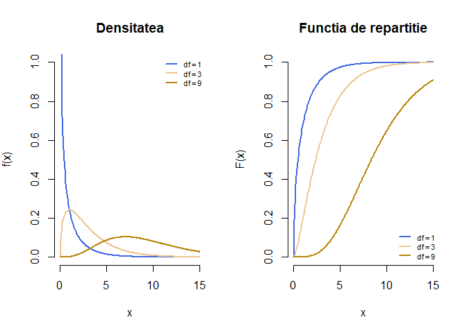

Din *Teorema Limită Centrală* avem că pentru $n$ suficient de mare, $X\approx \mathcal{N}(n, 2n)$ ceea ce sugerează că aproximativ $95\%$ dintre valori se situează în intervalul $[n - 2\sqrt{2n}, n + 2\sqrt{2n}]$.

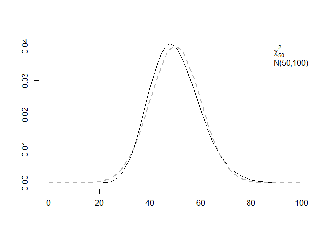

### Repartiția $t$-Student

Fie $U$ o variabilă aleatoare repartizată $\mathcal{N}(0, 1)$ și $V$ o variabilă repartizată $\chi^2_n$, cu $U$ și $V$ independente. Repartiția variabilei aleatoare $T = \frac{U}{\sqrt{\frac{V}{n}}}$ se numește repartiția Student cu $n$ grade de libertate și se notează cu $T\sim t_n$. Densitatea repartiției $t_n$ este

$$f(x)=\frac{\Gamma\left(\frac{n+1}{2}\right)}{\sqrt{\pi n} \Gamma\left(\frac{n}{2}\right)}\left(1+\frac{x^{2}}{n}\right)^{-\frac{n+1}{2}},\, x \in \mathbb{R}$$

Dacă $n = 1$ atunci variabila $T$ este repartizată Cauchy (raport de două normale independente) și prin urmare nu are medie (evident nici varianță). Dacă $n = 2$ atunci $T$ este de medie $0$ dar de varianță infinită iar pentru $n\geq 3$, $\mathbb{E}[T] = 0$ și $Var(T) = \frac{n}{n-2}$.

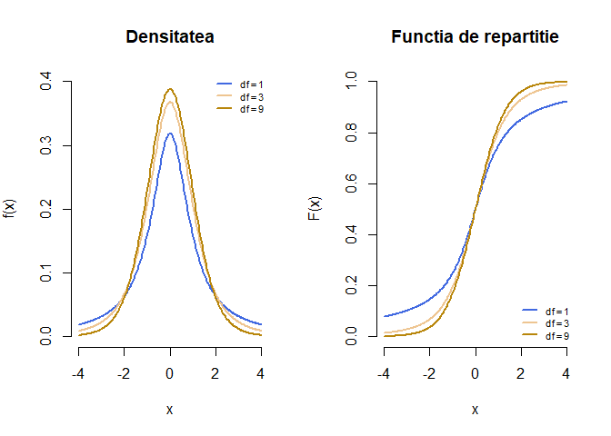

Pentru $n$ suficient de mare se poate arăta că $T\approx \mathcal{N}(0,1)$ (de exemplu observând că, din Legea Numerelor Mari, numitorul tinde la $1$ atunci când $n\to\infty$).

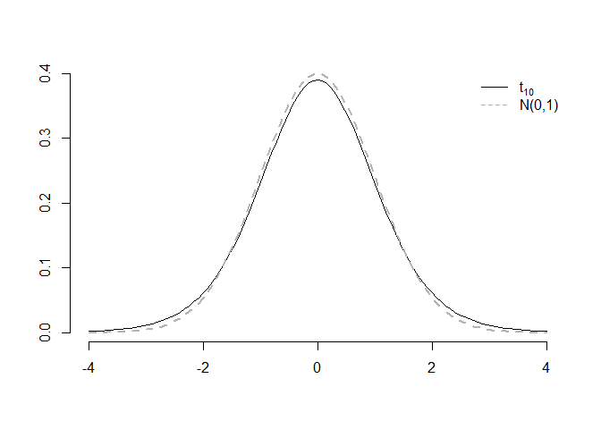

### Repartiția Fisher-Snedecor

Fie $U$ o variabilă aleatoare repartizată $\chi^2_{n_1}$ și $V$ o variabilă aleatoare repartizată $\chi^2_{n_2}$, cu $U$ și $V$ independente. Repartiția variabilei aleatoare $F = \frac{U/n_1}{V/n_2}$ se numește repartiția Fisher-Snedecor cu $n_1$ grade de libertate la numărător și $n_2$ grade de libertate la numitor și se notează $F\sim F_{n_1,n_2}$. Densitatea de repartiție este

$$f_{n_{1}, n_{2}}(x)=\frac{\Gamma\left(\frac{n_{1}+n_{2}}{2}\right)}{\Gamma\left(\frac{n_{1}}{2}\right) \Gamma\left(\frac{n_{2}}{2}\right)}\left(\frac{n_{1}}{n_{2}}\right)^{\frac{n_{1}}{2}} \frac{x^{\frac{n_{1}-2}{2}}}{\left(1+\frac{n_{1}}{n_{2}} x\right)^{\frac{n_{1}+n_{2}}{2}}} \quad \text { dacă } x>0 \quad(0 \text { altfel })$$

Pentru $n_2\geq 3$ media variabilei aleatoare $F$ există și este egală cu $\frac{n_2}{n_2-2}$ iar pentru $n_2\geq 5$ varianța există și este egală cu $\frac{2 n_{2}^{2}\left(n_{1}+n_{2}-2\right)}{n_{1}\left(n_{2}-2\right)^{2}\left(n_{2}-4\right)}$.

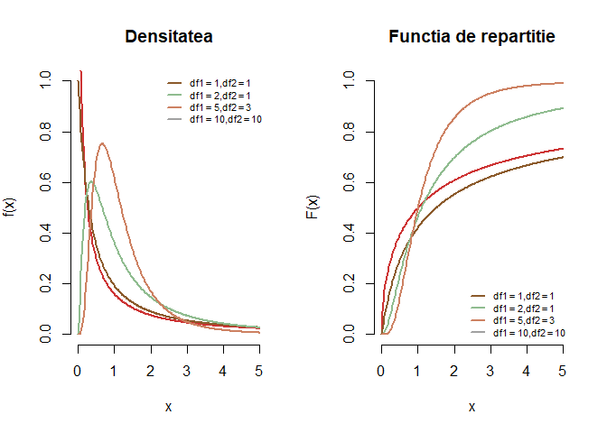

În plus dacă $n_2$ este mare atunci putem aproxima repartiția lui $F$ cu $F\approx \frac{\chi^2_{n_1}}{n_1}$.

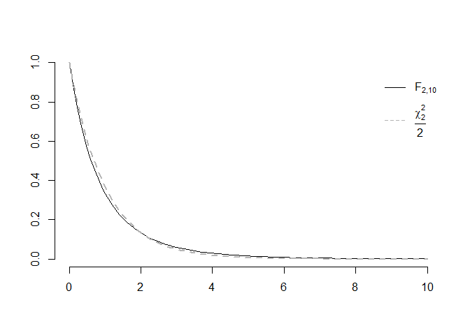

## Intervale de încredere

Dacă în problema de estimare punctuală am găsit, plecând de la un eșantion generat dintr-o populație guvernată de un parametru $\theta$, o valoare cât mai *apropiată* de parametrul necunoscut, în această secțiune ne propunem să determinăm un interval de valori care să aibă o probabilitate mare să conțină parametrul real. Este clar că între estimarea punctuală și cea prin intervale de încredere va fi o strânsă legătură, cea de-a doua abordare bazându-se pe prima. Avem următoarea definiție

Fie $X_1,\ldots,X_n$ un eșantion de talie $n$ dintr-o populație $F_{\theta}=\mathbb{P}\circ X^{-1}$, $\theta\in\Theta$ cu $X_i:\Omega\to(S,\mathcal{S})$. Fie $\alpha\in(0,1)$ și funcțiile măsurabile $A_{\alpha}, B_{\alpha}:S^n\to\mathbb{R}$ care verifică
$$A_{\alpha}(x_1,\ldots,x_n)\leq B_{\alpha}(x_1,\ldots,x_n),\quad\forall (x_1,\ldots,x_n)\in S^n.$$
Intervalul aleator $\left[A_{\alpha}(X_1,\ldots,X_n), B_{\alpha}(X_1,\ldots,X_n)\right]$ se numește interval de estimare pentru $\theta$ cu coeficientul de încredere $1-\alpha$ dacă
$$\mathbb{P}_{\theta}\left(\left[A_{\alpha}(X_1,\ldots,X_n), B_{\alpha}(X_1,\ldots,X_n)\right]\ni \theta\right)\geq 1-\alpha,\quad\forall\theta\in\Theta.$$

Este important de notat că în definiția anterioară intervalul $\left[A_{\alpha}(X_1,\ldots,X_n), B_{\alpha}(X_1,\ldots,X_n)\right]$ este un interval aleator și **nu** parametrul $\theta$ este aleator.

Având dat un interval de estimare $\left[A_{\alpha}(X_1,\ldots,X_n), B_{\alpha}(X_1,\ldots,X_n)\right]$ pentru $\theta$ se numește *probabilitatea de acoperire* a acestuia
$$\mathbb{P}_{\theta}\left(\left[A_{\alpha}(X_1,\ldots,X_n), B_{\alpha}(X_1,\ldots,X_n)\right]\ni \theta\right)$$
iar *coeficientul de încredere* al intervalului este definit prin
$$\inf_{\theta}\mathbb{P}_{\theta}\left(\left[A_{\alpha}(X_1,\ldots,X_n), B_{\alpha}(X_1,\ldots,X_n)\right]\ni \theta\right) = 1-\alpha$$

Trebuie menționat că atunci când avem observațiile $x_1,\ldots,x_n$, intervalul de estimare realizat se numește *interval de încredere* de nivel de încredere $1-\alpha$ și se notează cu

$$IC^{1-\alpha}(\theta) = \left[A_{\alpha}(x_1,\ldots,x_n), B_{\alpha}(x_1,\ldots,x_n)\right].$$

Chiar dacă noțiunea de *interval de încredere* și *interval de estimare* va fi folosită alternativ (prin abuz de limbaj) dar este important de notat că pentru un interval de încredere nu are sens să vorbim de $\mathbb{P}_{\theta}\left(IC^{1-\alpha}(\theta)\ni \theta\right)$ deoarece această probabilitate este $0$ sau $1$ după cum parametrul $\theta\in IC^{1-\alpha}(\theta)$.

Ca prim exemplu să presupunem că $X_1,\ldots,X_n$ este un eșantion de talie $n$ dintr-o populație $\mathcal{N}(\theta, 1)$. Am văzut că $\bar X_n\sim\mathcal{N}(\theta, 1/n)$ sau încă $\frac{\bar X_n - \theta}{\frac{1}{\sqrt{n}}}\sim\mathcal{N}(0,1)$. Fie $z_1, z_2$ cuantile ale repartiției normale standard pentru care are loc relația

$$\mathbb{P}_{\theta}\left(z_1\leq \frac{\bar X_n - \theta}{\frac{1}{\sqrt{n}}}\leq z_2\right) = \mathbb{P}_{\theta}\left(\bar X_n - \frac{z_2}{\sqrt{n}}\leq \theta \leq \bar X_n - \frac{z_1}{\sqrt{n}}\right) = 1-\alpha$$

Atunci, pentru eșantionul realizat $x_1,\ldots,x_n$, intervalul $IC^{1-\alpha}(\theta) = \left[\bar x_n - \frac{z_2}{\sqrt{n}},\bar x_n - \frac{z_1}{\sqrt{n}}\right]$ este un interval de încredere de nivel de încredere $1-\alpha$ pentru $\theta$ a cărui lungime este $l\left(IC^{1-\alpha}(\theta)\right)=\frac{1}{\sqrt{n}}(z_2-z_1)$. Observăm că putem avea o infinitate de astfel de intervale dar dorim să determinăm acel interval care are lungimea cea mai mică. Dacă facem ipoteza suplimentară că $z_2 = z_2(z_1)$ (o funcție de $z_1$) atunci sutnem în cadrul unei probleme de optimizare, mai precis avem problema (cu notațiile standard pentru funcția de repartiție și densitatea repartiției normale standard)

$$\left\{\begin{array}{ll}
\min \frac{1}{\sqrt{n}}(z_2-z_1)\\
\Phi(z_2) - \Phi(z_1) = 1-\alpha
\end{array}\right.$$

care, prin derivare, conduce la relațiile $\phi(z_2)\frac{d}{dz_1}z_2 - \phi(z_1) = 0$ și $\frac{d}{dz_1}z_2 - 1 = 0$ ceea ce implică $\phi(z_2)=\phi(z_1)$. Din simetria repartiției normale deducem că $z_2=z_{1-\alpha/2}$ și $z_1 = z_{\alpha/2} = -z_{1-\alpha/2}$ unde $z_{\alpha}$ este cuantila de ordin $\alpha$ a repartiției $\mathcal{N}(0,1)$. Am obținut astfel intervalul de încredere pentru $\theta$

$$IC^{1-\alpha}(\theta) = \left[\bar x_n - \frac{z_{1-\alpha/2}}{\sqrt{n}},\bar x_n + \frac{z_{1-\alpha/2}}{\sqrt{n}}\right]$$

### Metoda pivotului de determinare a intervalelor de încredere

O primă metodă de determinare a intervalelor de încredere este *metoda pivotului*.

Fie $X_1,\ldots,X_n$ un eșantion de talie $n$ dintr-o populație $F_{\theta}=\mathbb{P}\circ X^{-1}$, $\theta\in\Theta$. O funcție $g(x_1,\ldots,x_n,\theta):S^n\times\Omega\to\mathbb{R}$ se numește funcție pivot dacă verifică următoarele proprietăți:

1. repartiția lui $g(X_1,\ldots,X_n,\theta)$ nu depinde de $\theta$
2. pentru orice valori reale $u_1\leq u_2$ și orice $(x_1,\ldots,x_n)\in S^n$ inecuația $u_1\leq g(x_1,\ldots,x_n,\theta)\leq u_2$ se poate rezolva în $\theta$ (se poate pivota) conducând la o soluție de forma $a(x_1,\ldots,x_n)\leq \theta\leq b(x_1,\ldots,x_n)$.

Existența unei funcții pivot asigură o procedură de determinare a intervalelor de încredere de nivel de încredere dat.

Fie $X_1,\ldots,X_n$ un eșantion de talie $n$ dintr-o populație $F_{\theta}=\mathbb{P}\circ X^{-1}$, $\theta\in\Theta$ și $g:S^n\times\Omega\to\mathbb{R}$ o funcție care verifică:

1. $g(x_1,\ldots,x_n, \cdot)$ este continuă și strict monotonă ca funcție de $\theta$
2. $g(\cdot,\theta)$ este măsurabilă ca funcție de $(x_1,\ldots,x_n)$ pentru orice $\theta$ și variabila aleatoare $g(X_1,\ldots,X_n,\theta)$ are o repartiție independentă de $\theta$.

Atunci pentru orice $\alpha\in(0,1)$ există un interval de încredere $IC^{1-\alpha}(\theta)$ de nivel $1-\alpha$ pentru $\theta$.

Pentru a exemplifica rezultatul anterior să considerăm că avem un eșantion $X_1,\ldots,X_n\sim\mathcal{E}(\lambda)$. Cum variabila aleatoare $T_n = \sum_{i=1}^{n}X_i\sim \Gamma(n, \lambda)$, densitatea ei este

$$f_{T_n}(t) = \frac{\lambda^n}{(n-1)!}t^{n-1}e^{-\lambda t}\mathbf{1}_{\{t\geq 0\}}$$

prin urmare variabila aleatoare $\lambda T_n$ are densitatea

$$f_{\lambda T_n}(t) = \frac{d}{dt}F_{\lambda T_n}(t) = \frac{d}{dt}\mathbb{P}(\lambda T_n\leq t) = \frac{d}{dt}F_{T_n}\left(\frac{t}{\lambda}\right) = \frac{1}{\lambda}f_{T_n}\left(\frac{t}{\lambda}\right) = \frac{1}{(n-1)!}t^{n-1}e^{-t}\mathbf{1}_{\{t\geq 0\}}$$

ceea ce implică $\lambda T_n\sim\Gamma(n,1)$ și nu depinde de $\lambda$. Definim funcția

$$g(x_1,\ldots,x_n,\lambda) = \lambda\sum_{i=1}^n x_i$$

care verifică proprietățile unei funcții pivot. Fie, de asemenea, $u_1$ și $u_2$ cuantilele de ordin $\alpha/2$ și respectiv $1-\alpha/2$ a repartiției $\Gamma(n,1)$ atunci

$$\mathbb{P}_{\lambda}\left(u_1\leq g(X_1,\ldots,X_n,\lambda)\leq u_2\right) = 1-\alpha$$

determină intervalul de estimare (încredere) de nivel $1-\alpha$ pentru $\lambda$

$$IC^{1-\alpha}(\theta) = \left[\frac{u_1}{\sum_{i=1}^n X_i},\frac{u_2}{\sum_{i=1}^n X_i}\right].$$

Una dintre întrebările importante atunci când vorbim de intervale de încredere este cum alegem cuantilele $u_1$ și $u_2$ dat fiind că în general avem o infinitate de metode de alegere (ar trebui să verifice $F(u_2) - F(u_1) = 1-\alpha$). Următorul rezultat răspunde parțial la această întrebare:

Spunem că o densitate de repartiție $f$ este unimodală dacă există $x^*$ astfel încât $f(x)$ este crescătoare pentru $x\leq x^*$ și descrescătoare pentru $x\geq x^*$.

Fie $f(x)$ o densitate de repartiție unimodală. Dacă intervalul $[a,b]$ satisface:

1. $\int_{a}^{b}f(x)\,dx = 1-\alpha$
2. $f(a)=f(b)>0$
3. $a\leq x^*\leq b$ unde $x^*$ este modul lui $f$

atunci $[a,b]$ este intervalul de lungime minimă care verifică $\int_{a}^{b}f(x)\,dx = 1-\alpha$.

### Metode asimptotice

În context general presupunem că avem un eșantion $X_1,\ldots,X_n$ un eșantion de talie $n$ dintr-o populație $F_{\theta}=\mathbb{P}\circ X^{-1}$, $\theta\in\Theta$ și există un estimator $T_n$ pentru $\theta$ care verifică o relație de tipul *Teormei Limită Centrale*,

$$\frac{T_n - \theta}{s_{n}(\theta)}\overset{d}{\to}\mathcal{N}(0,1)$$

unde $s_{n}(\cdot)$ este o funcție care depinde de $\theta$, aleasă potrivit (de cele mai multe ori est chiar abaterea standard a lui $T_n$). Dacă funcția (în $\theta$) $\frac{T_n - \theta}{s_{n}(\theta)}$ se poate pivota atunci putem rezolva pentru a-l izola pe $\theta$ și astfel putem determina intervalul de încredere dorit. În caz contrar, vom folosi abordarea lui Wald (Wald plug-in) care ne spune că, în anumite condiții de regularitate, putem să-l înlocuim pe $\theta$ de la numitor cu estimatorul $T_n$, acesta fiind consistent (dat fiind relația de tip Teoremă Limită Centrală). Reamintim următorul rezultat, datorat lui Slutsky:

Fie $\left(X_n\right)_n$ și $\left(Y_n\right)_n$ două șiruri de variabile aleatoare astfel încât $X_n\overset{d}{\to}X$ și $Y_n\overset{\mathbb{P}}{\to}a$, $a$ este o constantă. Atunci
$$X_{n}+Y_{n} \overset{d}{\underset{n \to \infty}{\longrightarrow}} X+a \quad \text { și } \quad X_{n} Y_{n} \overset{d}{\underset{n \to \infty}{\longrightarrow}} a X$$

Dacă $s_n(\cdot)$ este continuă și $T_n\overset{\mathbb{P}}{\rightarrow}\theta$ atunci $s_n(T_n)\overset{\mathbb{P}}{\rightarrow}s_n(\theta)$ și din Teorema lui Slutsky avem

$$\frac{T_n - \theta}{s_{n}(T_n)} = \underbrace{\frac{T_n - \theta}{s_{n}(\theta)}}_{\overset{d}{\rightarrow}\mathcal{N}(0,1)}\times\underbrace{\frac{s_n(\theta)}{s_n(T_n)}}_{\overset{\mathbb{P}}{\rightarrow}1}\overset{d}{\rightarrow}\mathcal{N}(0,1).$$

Astfel, pentru $\alpha\in(0,1)$ fixat și $z_{\frac{\alpha}{2}} = -z_{1 - \frac{\alpha}{2}}$ și $z_{1 - \frac{\alpha}{2}}$ cuantilele de ordin $\frac{\alpha}{2}$ și respectiv $1-\frac{\alpha}{2}$ ale repartiției $\mathcal{N}(0,1)$ avem

$$\mathbb{P}_{\theta}\left(z_{\frac{\alpha}{2}}\leq \frac{T_n - \theta}{s_{n}(T_n)}\leq z_{1 - \frac{\alpha}{2}}\right) \approx 1-\alpha$$

de unde prin pivotare obținem intervalul de încredere aproximativ

$$IC^{1-\alpha}(\theta)=\left[t_n - z_{1 - \frac{\alpha}{2}}s_n(t_n), t_n + z_{1 - \frac{\alpha}{2}}s_n(t_n)\right]$$

unde $t_n$ este realizarea lui $T_n$. Intervalul de încredere de mai sus este aproximativ în sensul că procedura adoptată nu asigură cu exactitate un nivel $1-\alpha$ pentru orice $\theta$, $n$ finit.

Pentru a exemplifica vom considera cazul unei populații Poisson: $X_1,\ldots,X_n\sim\mathrm{Pois}(\theta)$. Din *Teorema Limită Centrală* avem ($s_n(\theta) = \sqrt{\frac{\theta}{n}}$)

$$\sqrt{n}\frac{\bar X_n - \theta}{\sqrt{\theta}}\overset{d}{\rightarrow}\mathcal{N}(0,1)$$

de unde

$$\mathbb{P}_{\theta}\left(z_{\frac{\alpha}{2}}\leq \sqrt{n}\frac{\bar X_n - \theta}{\sqrt{\theta}}\leq z_{1 - \frac{\alpha}{2}}\right) \approx 1-\alpha.$$

Dubla inegalitate din probabilitatea de mai sus poate fi scrisă sub forma $n\frac{(\bar X_n - \theta)}{\theta}\leq z_{1 - \frac{\alpha}{2}}^2$ ceea ce revine la a rezolva o inecuație de gradul doi. Soluția acestei inecuații conduce la intervalul de încredere aproximativ

$$\mathbb{P}_{\theta}\left(\bar X_n + \frac{z_{1-\frac{\alpha}{2}}^2}{n}-\sqrt{\frac{\bar X_n z_{1-\frac{\alpha}{2}}^2}{n} + \frac{z_{1-\frac{\alpha}{2}}^4}{4n^2}}\leq \theta\leq \bar X_n + \frac{z_{1-\frac{\alpha}{2}}^2}{n}+\sqrt{\frac{\bar X_n z_{1-\frac{\alpha}{2}}^2}{n} + \frac{z_{1-\frac{\alpha}{2}}^4}{4n^2}}\right) \approx 1-\alpha.$$

Observăm că dacă în expresia de mai sus neglijăm termenii de ordin $\frac{1}{n^2}$ de sub radical și termenii de ordin $\frac{1}{n}$ din afara acestuia obținem intervalul de încredere de tip Wald:

$$\mathbb{P}_{\theta}\left(\bar X_n -z_{1-\frac{\alpha}{2}}\sqrt{\frac{\bar X_n}{n}}\leq \theta\leq \bar X_n +z_{1-\frac{\alpha}{2}}\sqrt{\frac{\bar X_n}{n}}\right) \approx 1-\alpha.$$

Pentru a finaliza, mai rămâne întrebarea existenței estimatorului $T_n$ care să verifice o expresie asimptotică precum cea de la începutul secțiunii. Am văzut că atunci când populația din care provine eșantionul îndeplinește o serie de condiții de regularitate, *estimatorul de verosimilitate maximă* $\hat \theta_n$ a lui $\theta$ satisface

$$\frac{\hat\theta_n - \theta}{\sqrt{\frac{1}{n I_1(\theta)}}}\overset{d}{\rightarrow}\mathcal{N}(0,1)$$

unde $I_1(\theta) = \mathbb{E}_{\theta}\left[\left(\frac{\partial}{\partial\theta}\log f_{\theta}(X_1)\right)^2\right]$ este Informația lui Fisher asociată unei observații. Cu excepția unor cazuri simple în care expresia lui $I_1(\theta)$ ne permite să pivotăm vom folosi abordarea lui Wald, înlocuin $I_1(\theta)$ cu $I_1(\hat\theta_n)$. Obținem astfel intervalul de încredere asimptotic pentru $\theta$

$$IC^{1-\alpha}(\theta)=\left[\hat\theta_n - \frac{z_{1 - \frac{\alpha}{2}}}{\sqrt{nI_1(\hat\theta_n)}}, \hat\theta_n + \frac{z_{1 - \frac{\alpha}{2}}}{\sqrt{nI_1(\hat\theta_n)}}\right].$$

În secțiunile următoare vom exemplifica modul de construcție al unui interval de încredere în contextul unei populații normale.

### Intervale de încredere pentru media unei populații normale atunci când varianța este cunoscută

Fie $X_1, \ldots, X_n$ un eșantion de talie $n$ dintr-o populație normală $\mathcal{N}(\mu, \sigma^2)$ cu $\sigma^2$ cunoscut și $\mu$ necunoscut. Vrem să determinăm un interval de încredere de nivel $1-\alpha$ pentru media populației normale. Am văzut că $\bar X_n\sim\mathcal{N}\left(\mu, \frac{\sigma^2}{n}\right)$ ceea ce implică $\sqrt{n}\frac{\bar X_n - \mu}{\sigma}\sim\mathcal{N}(0,1)$.

Alegem funcția pivot $g(x_1,\ldots,x_n,\mu) = \sqrt{n}\frac{\bar x_n - \mu}{\sigma}$ și pentru $\alpha\in(0,1)$ fixat considerăm $z_{\frac{\alpha}{2}}$ și $z_{1 - \frac{\alpha}{2}}$ cuantilele de ordin $\frac{\alpha}{2}$ și respectiv $1-\frac{\alpha}{2}$ ale repartiției $\mathcal{N}(0,1)$. Avem, ținând cont și de simetria normalei față de medie, că

$$\mathbb{P}_{\mu}\left(z_{\frac{\alpha}{2}}\leq \sqrt{n}\frac{\bar X_n - \mu}{\sigma}\leq z_{1 - \frac{\alpha}{2}}\right) = \mathbb{P}_{\mu}\left(\bar X_n - z_{1-\frac{\alpha}{2}}\frac{\sigma}{\sqrt{n}}\leq \mu\leq \bar X_n + z_{1-\frac{\alpha}{2}}\frac{\sigma}{\sqrt{n}}\right) = 1-\alpha$$

de unde concluzionăm că

$$IC^{1-\alpha}(\mu) = \left[\bar x_n - z_{1-\frac{\alpha}{2}}\frac{\sigma}{\sqrt{n}}, \bar x_n + z_{1-\frac{\alpha}{2}}\frac{\sigma}{\sqrt{n}}\right]$$

este un interval de încredere de nivel $1-\alpha$ pentru $\mu$.

O ilustrare a $100$ de intervalele de încredere de nivel de încredere $1-\alpha = 0.95$ pentru media unei populații normale $\mathcal{N}(3.5, 1.5^2)$ atunci când $\sigma = 1.5$ este cunoscut este afișată mai jos:

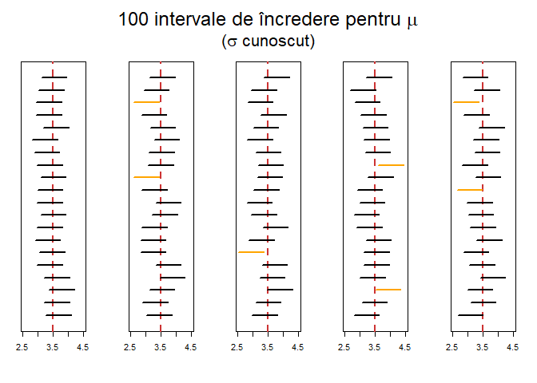

### Intervale de încredere pentru media unei populații normale atunci când varianța este necunoscută

Fie $X_1, \ldots, X_n$ un eșantion de talie $n$ dintr-o populație normală $\mathcal{N}(\mu, \sigma^2)$ cu $\mu$ și $\sigma^2$ necunoscute. Am văzut că înlocuind $\sigma^2$ cu statistica $S_n^2 = \frac{1}{n-1}\sum_{i=1}^{n}\left(X_i - \bar X_n\right)^2$ (varianța eșantionului) în $\sqrt{n}\frac{\bar X_n - \mu}{\sigma}$ obținem statistica $T_n = \sqrt{n}\frac{\bar X_n - \mu}{S_n}$ care este repartizată Student cu $n-1$ grade de libertate, i.e.

$$T_n = \sqrt{n}\frac{\bar X_n - \mu}{S_n}\sim t_{n-1}.$$

Pentru funcția pivot $g(x_1,\ldots,x_n,\mu) = \sqrt{n}\frac{\bar x_n - \mu}{s_n}$ și pentru $\alpha\in(0,1)$ fixat, fie $t_{n-1,\frac{\alpha}{2}}$ și $t_{n-1,1 - \frac{\alpha}{2}}$ cuantilele de ordin $\frac{\alpha}{2}$ și respectiv $1-\frac{\alpha}{2}$ ale repartiției $t_{n-1}$. Atunci

$$\mathbb{P}_{\mu}\left(t_{n-1,\frac{\alpha}{2}}\leq \sqrt{n}\frac{\bar X_n - \mu}{S_n}\leq t_{n-1,1-\frac{\alpha}{2}}\right) = \mathbb{P}_{\mu}\left(\bar X_n - t_{n-1,1-\frac{\alpha}{2}}\frac{S_n}{\sqrt{n}}\leq \mu\leq \bar X_n + t_{n-1, 1-\frac{\alpha}{2}}\frac{S_n}{\sqrt{n}}\right) = 1-\alpha,$$

unde $t_{n-1,\frac{\alpha}{2}} = -t_{n-1,1-\frac{\alpha}{2}}$ din simetria repartiție Student și găsim astfel că un interval de încredere de nivel $1-\alpha$ pentru $\mu$ este

$$IC^{1-\alpha}(\mu) = \left[\bar x_n - t_{n-1,1-\frac{\alpha}{2}}\frac{s_n}{\sqrt{n}}, \bar x_n + t_{n-1, 1-\frac{\alpha}{2}}\frac{s_n}{\sqrt{n}}\right].$$

În figura de mai jos sunt prezentate $100$ de intervale de încredere pentru $\mu = 3.5$ de nivel de încredere $1-\alpha = 0.95$ atunci când $\sigma^2$ nu este cunoscut:

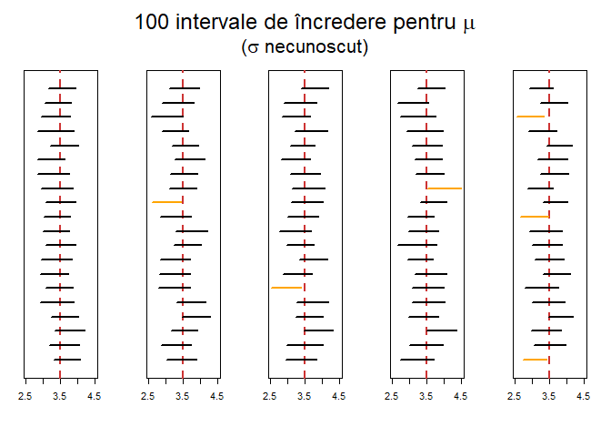

### Intervale de încredere pentru varianța unei populații normale

Fie $X_1, \ldots, X_n$ un eșantion de talie $n$ dintr-o populație normală $\mathcal{N}(\mu, \sigma^2)$ cu $\mu$ și $\sigma^2$ necunoscute. Până acum am dat intervale de încredere pentru media populației iar acum ne interesăm la un interval de încredere pentru varianța populației. Reamintim că varianța eșantionului $S_n^2$ este un estimator nedeplasat pentru $\sigma^2$ care pentru populații normale verifică $\frac{(n-1)S_n^2}{\sigma^2}\sim \chi_{n-1}^2$.

Pentru $\alpha\in(0,1)$ fixat considerăm $\chi_{n-1,\frac{\alpha}{2}}^2$ și $\chi_{n-1,1 - \frac{\alpha}{2}}^2$ cuantilele de ordin $\frac{\alpha}{2}$ și respectiv $1-\frac{\alpha}{2}$ ale repartiției $\chi_{n-1}^2$. Alegem ca funcție pivot $g(x_1,\ldots,x_n,\sigma^2) = \frac{(n-1)s_n^2}{\sigma^2}$ și observăm că

$$\mathbb{P}_{\mu}\left(\chi_{n-1,\frac{\alpha}{2}}^2\leq \frac{(n-1)S_n^2}{\sigma^2}\leq \chi_{n-1,1-\frac{\alpha}{2}}^2\right) = \mathbb{P}_{\mu}\left(\frac{(n-1)S_n^2}{\chi_{n-1,1-\frac{\alpha}{2}}^2}\leq \sigma^2\leq \frac{(n-1)S_n^2}{\chi_{n-1,\frac{\alpha}{2}}^2}\right) = 1-\alpha,$$

de unde concluzionăm că un interval de încredere pentru $\sigma^2$ de nivel de încredere $1-\alpha$ este

$$IC^{1-\alpha}(\sigma^2) = \left[\frac{(n-1)S_n^2}{\chi_{n-1,1-\frac{\alpha}{2}}^2}, \frac{(n-1)S_n^2}{\chi_{n-1,\frac{\alpha}{2}}^2}\right].$$

Este important de remarcat că în cazul în care media populației $\mu$ este cunoscută atunci $\frac{1}{\sigma^2}\sum_{i=1}^{n}(X_i-\mu)^2\sim \chi_{n}^2$ ceea ce conduce la un interval de încredere de forma

$$IC^{1-\alpha}(\sigma^2) = \left[\frac{\sum_{i=1}^{n}(x_i-\mu)^2}{\chi_{n,1-\frac{\alpha}{2}}^2}, \frac{\sum_{i=1}^{n}(x_i-\mu)^2}{\chi_{n,\frac{\alpha}{2}}^2}\right].$$

Figura de mai jos ilustrează 100 de intervale de încredere pentru $\sigma^2$ de nivel de încredere $1-\alpha = 0.95$ atunci populația este normală și media este necunoscută.

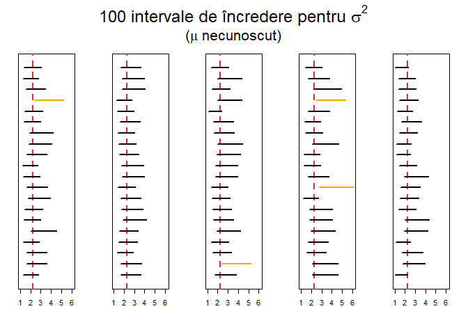

### Intervale de încredere pentru diferența mediilor a două populații normale

Fie $X_1,\ldots,X_{n_1}\sim\mathcal{N}(\mu_1, \sigma^2)$ și $Y_1,\ldots,Y_{n_2}\sim\mathcal{N}(\mu_2, \sigma^2)$ două eșantioane independente (între ele) de talie $n_1$ și respectiv $n_2$ din populații normale de medii diferite dar cu aceeași dispersie necunoscută $\sigma^2$. Ne propunem să construim un interval de încredere de nivel $1-\alpha$ pentru diferența mediilor $\mu_1-\mu_2$. Ca și în cazul unei populații normale avem că $\bar X_{n_1}\sim\mathcal{N}\left(\mu_1, \frac{\sigma^2}{n_1}\right)$ și $\bar Y_{n_2}\sim\mathcal{N}\left(\mu_2, \frac{\sigma^2}{n_2}\right)$ prin urmare, ținând cont de independență, $\bar X_{n_1} - \bar Y_{n_2}\sim\mathcal{N}\left(\mu_1-\mu_2, \sigma^2\left(\frac{1}{n_1} + \frac{1}{n_2}\right)\right)$. Din ultima relație deducem că

$$\frac{(\bar X_{n_1} - \bar Y_{n_2})-(\mu_1-\mu_2)}{\sigma\sqrt{\frac{1}{n_1} + \frac{1}{n_2}}}\sim\mathcal{N}(0,1).$$

Cum $\sigma^2$ este necunoscut îl vom estima plecând de la cele două eșantione remarcând pentru început că $\frac{(n_1-1)S_1^2}{\sigma^2}\sim \chi_{n_1-1}^2$ și $\frac{(n_2-1)S_2^2}{\sigma^2}\sim \chi_{n_2-1}^2$, unde $S_i^2$ reprezintă varianța eșantionului $i = 1,2$. Ținând cont de independența dintre eșantioane avem că $S_1^2\independent S_2^2$ prin urmare

$$\frac{(n_1-1)S_1^2}{\sigma^2} + \frac{(n_1-1)S_1^2}{\sigma^2} \sim \chi_{n_1+n_2-2}^2.$$

Folosind aceeași metodă ca și în cazul mediei unei populații normale cu $\mu$ și $\sigma^2$ necunoscute deducem că statistica

$$\frac{\frac{(\bar X_{n_1} - \bar Y_{n_2})-(\mu_1-\mu_2)}{\sigma\sqrt{\frac{1}{n_1} + \frac{1}{n_2}}}}{\sqrt{\frac{\frac{(n_1-1)S_1^2}{\sigma^2} + \frac{(n_1-1)S_1^2}{\sigma^2}}{n_1+n_2-2}}} \sim \frac{\mathcal{N}(0,1)}{\sqrt{\frac{\chi_{n_1+n_2-2}^2}{n_1+n_2-2}}}\sim t_{n_1+n_2-2}.$$

Astfel, notând cu $S_p^2 = \frac{\frac{(n_1-1)S_1^2}{\sigma^2} + \frac{(n_1-1)S_1^2}{\sigma^2}}{n_1+n_2-2}$ estimatorul varianței $\sigma^2$ (pooled variance), putem rescrie

$$\frac{(\bar X_{n_1} - \bar Y_{n_2})-(\mu_1-\mu_2)}{S_p\sqrt{\frac{1}{n_1} + \frac{1}{n_2}}}\sim t_{n_1+n_2-2}$$

ceea ce conduce la intervalul de încredere de nivel $1-\alpha$ pentru diferența mediilor (similar cu cel din cazul mediei populației normale atunci când varianța este necunoscută)

$$IC^{1-\alpha}(\mu) = \left[(\bar x_{n_1} - \bar y_{n_2}) - t_{n_1+n_2-2,1-\frac{\alpha}{2}}s_p\sqrt{\frac{1}{n_1} + \frac{1}{n_2}}, (\bar x_{n_1} - \bar y_{n_2}) + t_{n_1+n_2-2,1-\frac{\alpha}{2}}s_p\sqrt{\frac{1}{n_1} + \frac{1}{n_2}}\right].$$

Trebuie menționat că în cazul în care eșantioanele provin din populații cu varianțe diferite $\sigma_1^2\neq \sigma_2^2$ atunci statistica $\frac{(\bar X_{n_1} - \bar Y_{n_2})-(\mu_1-\mu_2)}{\sqrt{\frac{S_1^2}{n_1} + \frac{S_2^2}{n_2}}}$ nu mai este repartizată Student. În acest caz se folosește corecția lui [Welch–Satterthwaite](https://en.wikipedia.org/wiki/Welch%27s_t-test):

$$\frac{(\bar X_{n_1} - \bar Y_{n_2})-(\mu_1-\mu_2)}{\sqrt{\frac{S_1^2}{n_1} + \frac{S_2^2}{n_2}}} \sim t_{\nu}, \quad \text{cu}\quad \nu = \frac{\left(\frac{S_1^2}{n_1} + \frac{S_2^2}{n_2}\right)^2}{\frac{\left(\frac{S_1^2}{n_1}\right)^2}{n_1-1}+\frac{\left(\frac{S_2^2}{n_2}\right)^2}{n_2-1}}.$$

### Intervale de încredere pentru diferența mediilor a două populații normale atunci când datele vin în pereche

În cazul în care datele vin în perechi (de exemplu provin de la gemeni de sex diferit, de la indivizi care sunt potriviți după o serie de caracteristici sau de la aceiași indivizi inainte și după un eveniment de interes) atunci există dependență între acestea și nu mai putem aplica metoda anterioară. În acest context presupunem că $X_1,\ldots,X_{n}\sim\mathcal{N}(\mu_1, \sigma_1^2)$ și $Y_1,\ldots,Y_{n}\sim\mathcal{N}(\mu_2, \sigma_2^2)$ sunt două eșantioane cu date pereche și ne interesăm la determinarea unui interval de încredere pentru $d = \mu_1-\mu_2$.

Fie $D_i = X_i - Y_i$ variabilele aleatoare independente cu $D_i\sim\mathcal{N}(d, s_d^2)$ unde $d = \mu_1 - \mu_2$ iar $s_d^2 = \sigma_1^2 + \sigma_2^2 - 2Cov(X_i,Y_i)$. Observăm, din normalitatea și independența variabilelor aleatoare $D_i$, că statistica

$$\sqrt{n}\frac{\bar D_n - d}{S_d}\sim t_{n-1}$$

unde $S_d^2 = \frac{1}{n-1}\sum_{i=1}^{n}\left(D_i - \bar D_n\right)^2$ ceea ce conduce la intervalul de încredere de nivel de încredere $1-\alpha$ pentru diferența mediilor

$$IC^{1-\alpha}(\mu) = \left[\bar d_n - t_{n-1,1-\frac{\alpha}{2}}\frac{s_d}{\sqrt{n}}, \bar d_n + t_{n-1, 1-\frac{\alpha}{2}}\frac{d_n}{\sqrt{n}}\right].$$

### Intervale de încredere pentru raportul varianțelor a două populații normale

Fie $X_1,\ldots,X_{n_1}\sim\mathcal{N}(\mu_1, \sigma_1^2)$ și $Y_1,\ldots,Y_{n_2}\sim\mathcal{N}(\mu_2, \sigma_2^2)$ două eșantioane independente (între ele) de talie $n_1$ și respectiv $n_2$ din populații normale de medii și dispersii diferite. Ne propunem să construim un interval de încredere de nivel $1-\alpha$ pentru raportul varianțelor $\frac{\sigma_1^2}{\sigma_2^2}$.

Cum $\frac{(n_1-1)S_1^2}{\sigma_1^2}\sim \chi_{n_1-1}^2$ și $\frac{(n_2-1)S_2^2}{\sigma_2^2}\sim \chi_{n_2-1}^2$ unde $S_1^2$ și $S_2^2$ sunt varianțele primului și respectiv celui de-a doilea eșantion și ținând cont de independența dintre eșantioane, și în particular dintre $S_1^2$ și $S_2^2$, găsim

$$\frac{\frac{S_1^2}{\sigma_1^2}}{\frac{S_2^2}{\sigma_2^2}} = \frac{\frac{\frac{(n_1-1)S_1^2}{\sigma_1^2}}{n_1-1}}{\frac{\frac{(n_2-1)S_2^2}{\sigma_2^2}}{n_2-1}} \sim \frac{\frac{\chi_{n_1-1}^2}{n_1-1}}{\frac{\chi_{n_1-1}^2}{n_1-1}}\sim F_{n_1-1,n_2-1}.$$

Astfel, pentru $\alpha\in(0,1)$, avem

$$\mathbb{P}_{\frac{\sigma_1^2}{\sigma_2^2}}\left(f_{n_1-1,n_2-1, \frac{\alpha}{2}}\leq \frac{\frac{S_1^2}{\sigma_1^2}}{\frac{S_2^2}{\sigma_2^2}}\leq f_{n_1-1,n_2-1, 1-\frac{\alpha}{2}}\right) = 1-\alpha,$$

unde $f_{n_1-1,n_2-1, \alpha}$ este cuantila de ordin $\alpha$ a repartiției Fisher-Snedecor $F_{n_1-1,n_2-1}$ ceea ce conduce la intervalul de încredere de nivel $1-\alpha$ pentru $\frac{\sigma_1^2}{\sigma_2^2}$

$$IC^{1-\alpha}\left(\frac{\sigma_1^2}{\sigma_2^2}\right) = \left[\frac{S1^2}{S_2^2}f_{n_1-1,n_2-1, \frac{\alpha}{2}}, \frac{S1^2}{S_2^2}f_{n_1-1,n_2-1, 1-\frac{\alpha}{2}}\right].$$

### Intervale de încredere pentru o proporție

Sunt multe situațiile în care vrem să determinăm un interval de încredere pentru o proporție, de exemplu în cazul unui sondaj aleator dorim să determinăm un interval de încredere de nivel $95\%$ pentru proporția $p$ a persoanelor care verifică o anumită proprietate de interes (e.g. au votat cu partidul X). În acest contex avem $X_1, \ldots, X_n$ un eșantion de talie $n$ dintr-o populație Bernoulli $\mathcal{B}(p)$ cu $p$ necunoscut. Din *Teorema Limită Centrală* știm că

$$\sqrt{n}\frac{\bar X_n - p}{\sqrt{p(1-p)}} \overset{d}{\to}\mathcal{N}(0,1)$$

ceea ce implică, pentru $n$ suficient de mare (în practică $\geq 30$), că

$$\mathbb{P}_{\mu}\left(-z_{1-\frac{\alpha}{2}}\leq \sqrt{n}\frac{\bar X_n - p}{\sqrt{p(1-p)}}\leq z_{1 - \frac{\alpha}{2}}\right)\approx 1-\alpha.$$

Cantitatea $\sqrt{n}\frac{\bar X_n - p}{\sqrt{p(1-p)}}$ se poate pivota în raport cu $\theta$ și rezolvând inecuația de ordin $2$ în $p$

$$n\frac{\left(\bar X_n - p\right)^2}{p(1-p)}\leq z_{1-\frac{\alpha}{2}}^2$$

găsim un interval de încredere asimptotic de forma

$$IC^{1-\alpha}(\theta) = \left[\frac{\bar X_n + \frac{z_{1-\frac{\alpha}{2}}^2}{2n}}{1 + \frac{z_{1-\frac{\alpha}{2}}^2}{n}} - \frac{1}{1 + \frac{z_{1-\frac{\alpha}{2}}^2}{n}}\sqrt{\frac{z_{1-\frac{\alpha}{2}}^2}{n}\bar X_n(1-\bar X_n) + \frac{z_{1-\frac{\alpha}{2}}^4}{4n^2}},\frac{\bar X_n + \frac{z_{1-\frac{\alpha}{2}}^2}{2n}}{1 + \frac{z_{1-\frac{\alpha}{2}}^2}{n}} + \frac{1}{1 + \frac{z_{1-\frac{\alpha}{2}}^2}{n}}\sqrt{\frac{z_{1-\frac{\alpha}{2}}^2}{n}\bar X_n(1-\bar X_n) + \frac{z_{1-\frac{\alpha}{2}}^4}{4n^2}}\right].$$

Eliminând termenii de ordin $\frac{1}{n^2}$ de sub radical și pe cei de ordin $\frac{1}{n}$ din afara radicalului găsim exact intervalul de încredere asimptotic pe care l-am fi obținut dacă aplicam metoda lui Wald:

$$IC^{1-\alpha}(\theta) = \left[\bar X_n - z_{1-\frac{\alpha}{2}}\sqrt{\frac{\bar X_n(1-\bar X_n)}{n}}, \bar X_n + z_{1-\frac{\alpha}{2}}\sqrt{\frac{\bar X_n(1-\bar X_n)}{n}}\right].$$

Probabilitatea de acoperire este:

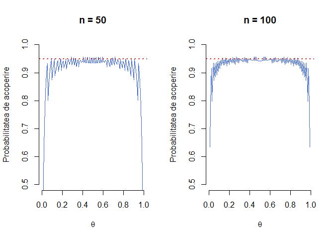

## Modele de regresie folosind limbajul R

În această secțiune vom prezenta funcțiile de bază din `R` folosite pentru fitarea (potrivirea) și analizarea unui model de regresie liniară. Pentru a rula modelul de regresie liniară clasic în `R` se folosește funcția `lm()` (*linear model*). Funcția `lm()` are două argumente esențiale: `formula` și `data`:

```r
model_regresie <- lm(formula, data)
```

unde

[output not shown]

Următorul tabel conține o serie de corespondențe între codul `R` și conceptele statistice asociate modelului de regresie:

| `R` | Concepte statistice |
| --- | --- |
| `x1, x2, ..., xp` | Variabilele predictor $x_1,\ldots,x_p$ |
| `y` | Variabila răspuns |
| `data <- data.frame(x1 = x1, ...,xp = xp, y = y)` | Eșantionul $(y_i,\boldsymbol x_{ij})$, $i = 1,\ldots,n$, $j=1,\ldots,p$ |
| `model <- lm(y ~ x, data = data)` | Modelul de regresie liniară |
| `model$coefficients` | Coeficienții $\hat\beta_0,\hat\beta_1,\ldots,\hat\beta_p$ |
| `model$residuals` | Valorile reziduale $\hat\varepsilon_1,\ldots,\hat\varepsilon_n$ |
| `model$fitted.values` | Valorile ajustate (fitate) $\hat y_1,\ldots,\hat y_n$ |
| `model$df.residual` | Gradele de libertate $n-(p+1)$ |
| `summaryModel <- summary(model)` | Sumarul modelului de regresie liniară |
| `summaryModel$sigma` | Estimatorul $\hat\sigma$ |
| `summaryModel$r.squared` | Coeficientul de determinare $R^2$ |
| `summaryModel$fstatistic` | Testul lui Fisher global $F$ |
| `anova(model)` | Tabelul ANOVA |

O componentă importantă în specificarea unui model de regresie liniară este dat de termenul `formula` în expresia funcției `lm()`. Forma de bază a unei *formule* este

$$y \sim x_1 + x_2 + \cdots + x_p$$

unde variabila răspuns $y$ este separată de variabilele predictor prin $\sim$ iar covariabilele sunt separate la rândul lor prin semnul $+$ și corespunde modelului clasic

$$y_i = \beta_0 + \beta_1 x_{i1} + \cdots + \beta_p x_{ip} + \varepsilon_i, \quad i = 1,2,\ldots,n.$$

Formula se poate modifica introducând alte simboluri pentru a permite specificarea mai multor tipuri de modele liniare (e.g. cu interacții), după cum este specificat în tabelul de mai jos:

[output not shown]

În tabelul de mai jos regăsiți o serie de funcții utile, pe lângă funcția `lm()`, necesare pentru analiza de regresie multiplă împreună cu pachetele din care fac parte.

[output not shown]

# 5 Referințe

Cook, R. Dennis, and Sanford Weisberg. 1999. “Graphs in Statistical Analysis: Is the Medium the Message?” *The American Statistician* 53 (1): 29–37. https://doi.org/10.1080/00031305.1999.10474426.

Faraway, Julian. 2015. *Linear Models with R*. 2nd ed. CRC Press.

Greene, William H. 2011. *Econometric Analysis*. 7th ed. Prentice Hall. http://gen.lib.rus.ec/book/index.php?md5=A0CEC5F0E1D09DF6E99A0E52B9B60DBB.

Henderson, H. V., and S. R. Searle. 1981. “On Deriving the Inverse of a Sum of Matrices.” *SIAM Review* 23 (1): 53–60. https://doi.org/10.1137/1023004.

Jacod, Jean, and Philip Protter. 2003. *Probability Essentials*. Springer.

Olive, David J. 2017. *Linear Regression*. Springer.

Ornea, L., and A. Turtoi. 2000. *O Introducere in Geometrie*. Fundatia Theta.

Rencher, Alvin C, and G Bruce Schaalje. 2008. *Linear Models in Statistics*. John Wiley & Sons.

Seber, George, and Alan Lee. 2003. *Linear Regression Analysis*. 2nd ed. Wiley.

Sen, Ashish, and Muni Srivastava. 2012. *Regression Analysis: Theory, Methods, and Applications*. Springer Science & Business Media.

Weisberg, Sanford. 2014. *Applied Linear Regression*. 4th ed. Wiley.

Yanai, Haruo, Kei Takeuchi, and Yoshio Takane. 2011. *Projection Matrices, Generalized Inverse Matrices, and Singular Value Decomposition*. Springer-Verlag New York. https://doi.org/https://doi.org/10.1007/978-1-4419-9887-3.

[^1]: Setul de date folosit în figura de mai jos poate fi descărcat de [aici](https://dataverse.harvard.edu/dataset.xhtml?persistentId=doi:10.7910/DVN/T0HSJ1)
[^2]: Aici trebuie avut grijă să nu se confunde valorile $x_1,\ldots,x_n$ care corespund unei singure covariabile cu $n$ covariabile.
[^3]: Spunem că un sistem de polinoame $\{p_n(x)\}$, $n = 0,1,\ldots$ este ortogonal pe intervalul $(a,b)$ dacă $\int_a^b p_n(x)p_m(x)\,dx = \delta_{nm}$ unde $\delta_{nm}$ este simbolul lui Kronecker. În general putem avea ortogonalitate în raport cu o funcție de pondere $w(x)\geq 0$ (continuă sau continuă pe porțiuni) dacă $\int_a^b p_n(x)p_m(x)w(x)\,dx = \delta_{nm}$.
[^4]: În general, numim *proiecție* un endomorfism $p: W\to W$ cu proprietatea că există o descompunere în sumă directă $W = V_1\oplus V_2$ (și spunem proiecție pe $V_1$ de-a lungul lui $V_2$) astfel încât $p(\boldsymbol w) = \boldsymbol v_1$, $\forall \boldsymbol w\in W$ cu $\boldsymbol w = \boldsymbol v_1 + \boldsymbol v_2$, $\boldsymbol v_1\in V_1$ și $\boldsymbol v_2\in V_2$.
[^5]: *Teorema celor trei perpendiculare* spune că dacă $\boldsymbol V$ și $\boldsymbol W$ sunt două subspații vectoriale astfel încât $\boldsymbol V\subset \boldsymbol W$ atunci $P_V P_W = P_W P_V = P_V$.